# Analyses of the Memory Data

Hector Bahamonde

last update: 01 March 2018

##### General Notes

- `Age`, `YrsEduc`, `PolSoph`, `LibCon` were rescaled. The new range goes from -.5 to .5. The variables used in the models were also rescaled.

##### Using Separate Datasets (Students and MTurkers)

1. `Latino` came in a weird format. I assumed the NA’s were missing. After recoding the variable, it has the following N. **Rick: please confirm this N. Please note that these numbers correspond to the merged dataset (merged both the Students and MTurker dataset to simplify coding in the models section)**

```
##
##         2    Latino No Latino
##        87       516         5
```

2. `StudentParent` has three values, and the following N (total, both Students and MTurkers)

```
##
## Student  Parent   MTurk
##     332       0     276
```

3. `PrimaryChoice` has the exact disribution you sent me. This is using the merged version of the two datasets you sent me.

```r
table(dat$PrimaryChoice[dat$StudentParent=="Student"]) # Only Student dataset.
```

```
##
## Democratic Republican
##        226        106
```

```r
table(dat$PrimaryChoice[dat$StudentParent=="MTurk"]) # Only MTurkers dataset.
```

```
##
## Democratic Republican
##        205         71
```

4. **Please note that that I merged both datasets**.

##### Dropping Missing Values

###### Report of NA’s

- Missing values and total variables (including controls) used in Smith analyses:

```
##
##  0
## 44
```

- Missing values and total variables (including controls) used in Wilson analyses:

```
##
##  0
## 44
```

- Missing values and total variables (including controls) used in Jones analyses:

```
##
##  0
## 44
```

- Missing values and total variables (including controls) used in Williams analyses:

```
##
##  0
## 44
```

# Only Students Analyses

## Results: Smith Models

#### Table 1

|  | **Model 1** | **Model 2** | **Model 3** | **Model 4** | **Model 5** |  |
| --- | --- | --- | --- | --- | --- | --- |
| (Intercept) | -40.779** | -37.632* | -36.668* | -37.997* | -33.781* |  |
|  | (14.914) | (15.232) | (15.271) | (15.308) | (14.063) |  |
| Female | -1.748 | -1.968 | -1.987 | -1.792 | -1.502 |  |
|  | (2.882) | (2.890) | (2.884) | (2.885) | (2.703) |  |
| Age | -102.491** | -96.961** | -95.551** | -97.114** | -98.346** |  |
|  | (32.466) | (32.916) | (32.915) | (33.151) | (30.456) |  |
| YrsEduc | 12.031 | 10.122 | 10.087 | 10.589 | 19.106 |  |
|  | (20.685) | (20.768) | (20.715) | (20.780) | (19.454) |  |
| Black | -9.854 | -9.963 | -9.978 | -10.032 | -8.246 |  |
|  | (5.177) | (5.178) | (5.170) | (5.187) | (4.867) |  |
| LatinoLatino | 8.160* | 8.188* | 8.166* | 8.120* | 9.202* |  |
|  | (3.760) | (3.759) | (3.754) | (3.764) | (3.532) |  |
| PolSoph | 11.497 | 11.906 | 11.853 | 11.654 | 6.833 |  |
|  | (7.369) | (7.379) | (7.364) | (7.379) | (6.980) |  |
| LibCon | -22.838** | -21.109* | -20.859* | -21.407* | -12.863 |  |
|  | (8.227) | (8.401) | (8.375) | (8.418) | (7.997) |  |
| PanelLength5 Weeks | 2.213 | 1.570 | 1.498 | 1.757 | 0.394 |  |
|  | (3.828) | (3.880) | (3.867) | (3.872) | (3.610) |  |
| DSmithMemAff5 |  | 14.196 |  |  |  |  |
|  |  | (13.986) |  |  |  |  |
| DSmithMemAff50 |  |  | 17.243 |  |  |  |
|  |  |  | (14.189) |  |  |  |
| DSmithIWMemAff5 |  |  |  | 9.352 |  |  |
|  |  |  |  | (11.373) |  |  |
| DSmithAccRecogMemAff5 |  |  |  |  | 33.689*** |  |
|  |  |  |  |  | (7.115) |  |
| R<sup>2</sup> | 0.192 | 0.197 | 0.199 | 0.195 | 0.294 |  |
| Adj. R<sup>2</sup> | 0.150 | 0.150 | 0.153 | 0.148 | 0.253 |  |
| Num. obs. | 165 | 165 | 165 | 165 | 165 |  |
| RMSE | 18.226 | 18.224 | 18.198 | 18.245 | 17.091 |  |
| p < 0.001, p < 0.01, p < 0.05. All models, OLS. DV: Wk5DemSmithFTR |  |  |  |  |  |  |

#### Table 2

|  | **Model 1** | **Model 2** | **Model 3** | **Model 4** | **Model 5** | **Model 6** | **Model 7** | **Model 8** |  |
| --- | --- | --- | --- | --- | --- | --- | --- | --- | --- |
| (Intercept) | -9.379 | -6.037 | -5.801 | -0.913 | -0.852 | 0.804 | -2.471 | -2.818 |  |
|  | (14.143) | (14.488) | (14.524) | (13.857) | (13.873) | (13.880) | (12.502) | (12.478) |  |
| Female | -2.701 | -2.765 | -2.630 | -3.337 | -3.334 | -2.777 | -1.420 | -1.327 |  |
|  | (2.715) | (2.715) | (2.715) | (2.627) | (2.628) | (2.612) | (2.399) | (2.397) |  |
| Age | -33.383 | -28.673 | -27.783 | -18.077 | -19.012 | -12.326 | -31.146 | -32.150 |  |
|  | (30.770) | (31.080) | (31.194) | (30.008) | (29.997) | (30.140) | (27.112) | (27.067) |  |
| YrsEduc | -5.691 | -8.366 | -7.827 | -9.092 | -8.287 | -9.120 | 0.126 | 0.944 |  |
|  | (19.616) | (19.772) | (19.708) | (18.957) | (18.960) | (18.893) | (17.304) | (17.283) |  |
| Black | -7.402 | -7.693 | -7.740 | -7.913 | -8.062 | -8.171 | -6.039 | -6.411 |  |
|  | (4.901) | (4.907) | (4.908) | (4.732) | (4.737) | (4.719) | (4.322) | (4.313) |  |
| LatinoLatino | 9.542** | 9.560** | 9.483** | 9.763** | 9.692** | 9.684** | 10.185** | 10.126** |  |
|  | (3.564) | (3.563) | (3.563) | (3.441) | (3.443) | (3.429) | (3.142) | (3.137) |  |
| PolSoph | 1.046 | 1.626 | 1.547 | 1.488 | 1.234 | 0.968 | -4.735 | -4.760 |  |
|  | (6.912) | (6.931) | (6.924) | (6.672) | (6.676) | (6.649) | (6.148) | (6.139) |  |
| LibCon | -26.315*** | -25.120** | -25.171** | -19.359* | -19.425* | -18.840* | -11.534 | -12.431 |  |
|  | (7.789) | (7.868) | (7.857) | (7.768) | (7.773) | (7.759) | (7.196) | (7.143) |  |
| PanelLength5 Weeks | 3.276 | 2.754 | 2.783 | 1.277 | 1.551 | 1.612 | 0.342 | 0.924 |  |
|  | (3.536) | (3.569) | (3.564) | (3.459) | (3.450) | (3.431) | (3.145) | (3.130) |  |
| DSmithDifAff |  | 15.025 |  |  |  |  |  |  |  |
|  |  | (14.232) |  |  |  |  |  |  |  |
| DSmithIWDifAff |  |  | 12.576 |  |  |  |  |  |  |
|  |  |  | (11.716) |  |  |  |  |  |  |
| DSmithMemAff |  |  |  | 42.325*** |  |  |  |  |  |
|  |  |  |  | (11.914) |  |  |  |  |  |
| DSmithMemAff0 |  |  |  |  | 42.454*** |  |  |  |  |
|  |  |  |  |  | (12.064) |  |  |  |  |
| DSmithIWMemAff |  |  |  |  |  | 36.128*** |  |  |  |
|  |  |  |  |  |  | (9.747) |  |  |  |
| DSmithAccRecogMemAff10 |  |  |  |  |  |  | 41.862*** |  |  |
|  |  |  |  |  |  |  | (6.136) |  |  |
| DSmithAccAccessedRecogMemAff |  |  |  |  |  |  |  | 41.841*** |  |
|  |  |  |  |  |  |  |  | (6.091) |  |
| R<sup>2</sup> | 0.140 | 0.146 | 0.147 | 0.204 | 0.203 | 0.210 | 0.337 | 0.339 |  |
| Adj. R<sup>2</sup> | 0.097 | 0.098 | 0.098 | 0.159 | 0.158 | 0.164 | 0.299 | 0.301 |  |
| Num. obs. | 167 | 167 | 167 | 167 | 167 | 167 | 167 | 167 |  |
| RMSE | 17.288 | 17.282 | 17.280 | 16.685 | 16.697 | 16.631 | 15.232 | 15.208 |  |
| p < 0.001, p < 0.01, p < 0.05. All models, OLS. DV: Wk10DemSmithFTR |  |  |  |  |  |  |  |  |  |

#### Table 3

|  | **Model 1** | **Model 2** | **Model 3** | **Model 4** | **Model 5** | **Model 6** | **Model 7** | **Model 8** | **Model 9** |  |
| --- | --- | --- | --- | --- | --- | --- | --- | --- | --- | --- |
| (Intercept) | -40.779** | -32.781* | -30.018* | -36.847* | -35.076* | -36.511* | -34.753* | -35.388* | -35.373* |  |
|  | (14.914) | (15.501) | (15.071) | (14.789) | (14.565) | (14.690) | (15.099) | (15.348) | (15.175) |  |
| Female | -1.748 | -1.064 | -0.849 | -1.114 | -1.207 | -1.303 | -1.221 | -1.377 | -1.413 |  |
|  | (2.882) | (2.889) | (2.836) | (2.852) | (2.799) | (2.827) | (2.869) | (2.885) | (2.872) |  |
| Age | -102.491** | -93.993** | -84.915** | -92.820** | -84.950** | -91.360** | -94.045** | -96.749** | -95.895** |  |
|  | (32.466) | (32.613) | (32.350) | (32.249) | (31.927) | (32.055) | (32.465) | (32.616) | (32.518) |  |
| YrsEduc | 12.031 | 14.642 | 15.897 | 16.151 | 16.971 | 15.193 | 13.340 | 13.790 | 14.212 |  |
|  | (20.685) | (20.602) | (20.277) | (20.456) | (20.114) | (20.293) | (20.511) | (20.656) | (20.607) |  |
| Black | -9.854 | -8.654 | -7.720 | -7.596 | -7.106 | -6.475 | -7.960 | -8.617 | -8.497 |  |
|  | (5.177) | (5.188) | (5.119) | (5.189) | (5.089) | (5.217) | (5.222) | (5.235) | (5.211) |  |
| LatinoLatino | 8.160* | 8.325* | 8.546* | 8.758* | 8.708* | 7.830* | 7.507* | 8.001* | 7.965* |  |
|  | (3.760) | (3.736) | (3.680) | (3.713) | (3.650) | (3.685) | (3.741) | (3.749) | (3.740) |  |
| PolSoph | 11.497 | 10.068 | 7.958 | 9.736 | 7.641 | 9.960 | 11.010 | 11.201 | 9.986 |  |
|  | (7.369) | (7.365) | (7.314) | (7.299) | (7.240) | (7.239) | (7.308) | (7.348) | (7.382) |  |
| LibCon | -22.838** | -21.993** | -18.086* | -20.488* | -16.283* | -18.748* | -20.443* | -21.977** | -20.122* |  |
|  | (8.227) | (8.187) | (8.219) | (8.167) | (8.221) | (8.194) | (8.246) | (8.224) | (8.339) |  |
| PanelLength5 Weeks | 2.213 | 2.812 | 3.163 | 2.483 | 2.990 | 0.444 | 0.732 | 2.278 | 2.545 |  |
|  | (3.828) | (3.818) | (3.759) | (3.774) | (3.720) | (3.804) | (3.869) | (3.816) | (3.811) |  |
| DSmith25Cumu0 |  | 30.909 |  |  |  |  |  |  |  |  |
|  |  | (17.610) |  |  |  |  |  |  |  |  |
| DSmithWk5WeeklyTally0 |  |  | 72.575** |  |  |  |  |  |  |  |
|  |  |  | (25.541) |  |  |  |  |  |  |  |
| DSmith25Cumu1 |  |  |  | 23.369* |  |  |  |  |  |  |
|  |  |  |  | (9.824) |  |  |  |  |  |  |
| DSmithWk5WeeklyTally1 |  |  |  |  | 34.443** |  |  |  |  |  |
|  |  |  |  |  | (10.431) |  |  |  |  |  |
| DSmithWk25WeeklyPBTally1 |  |  |  |  |  | 25.995** |  |  |  |  |
|  |  |  |  |  |  | (9.427) |  |  |  |  |
| DSmithWk25WeeklyPBTally2 |  |  |  |  |  |  | 17.749 |  |  |  |
|  |  |  |  |  |  |  | (9.084) |  |  |  |
| DSmith25Cumu2 |  |  |  |  |  |  |  | 14.791 |  |  |
|  |  |  |  |  |  |  |  | (10.463) |  |  |
| DSmithWk5WeeklyTally2 |  |  |  |  |  |  |  |  | 22.768 |  |
|  |  |  |  |  |  |  |  |  | (13.590) |  |
| R<sup>2</sup> | 0.192 | 0.207 | 0.232 | 0.220 | 0.245 | 0.229 | 0.211 | 0.202 | 0.206 |  |
| Adj. R<sup>2</sup> | 0.150 | 0.161 | 0.187 | 0.175 | 0.201 | 0.185 | 0.165 | 0.156 | 0.160 |  |
| Num. obs. | 165 | 165 | 165 | 165 | 165 | 165 | 165 | 165 | 165 |  |
| RMSE | 18.226 | 18.106 | 17.827 | 17.960 | 17.674 | 17.852 | 18.064 | 18.168 | 18.122 |  |
| p < 0.001, p < 0.01, p < 0.05. All models, OLS. DV: Wk5DemSmithFTR |  |  |  |  |  |  |  |  |  |  |

#### Table 4

|  | **Model 1** | **Model 2** | **Model 3** | **Model 4** | **Model 5** | **Model 6** | **Model 7** | **Model 8** | **Model 9** |  |
| --- | --- | --- | --- | --- | --- | --- | --- | --- | --- | --- |
| (Intercept) | -9.379 | -8.105 | -5.907 | -8.403 | -7.742 | -6.102 | -5.024 | -8.726 | -7.642 |  |
|  | (14.143) | (14.371) | (14.456) | (14.152) | (14.129) | (14.036) | (14.380) | (14.474) | (14.423) |  |
| Female | -2.701 | -2.610 | -2.691 | -2.589 | -2.789 | -2.740 | -2.596 | -2.680 | -2.725 |  |
|  | (2.715) | (2.726) | (2.713) | (2.714) | (2.705) | (2.680) | (2.705) | (2.725) | (2.720) |  |
| Age | -33.383 | -32.123 | -31.667 | -30.712 | -29.163 | -29.113 | -29.891 | -32.822 | -32.173 |  |
|  | (30.770) | (30.928) | (30.778) | (30.819) | (30.775) | (30.432) | (30.734) | (30.961) | (30.883) |  |
| YrsEduc | -5.691 | -4.747 | -4.201 | -3.635 | -3.962 | -2.234 | -4.370 | -5.423 | -4.997 |  |
|  | (19.616) | (19.739) | (19.642) | (19.673) | (19.572) | (19.424) | (19.558) | (19.711) | (19.682) |  |
| Black | -7.402 | -6.984 | -6.813 | -6.355 | -6.586 | -5.596 | -6.418 | -7.212 | -7.025 |  |
|  | (4.901) | (4.973) | (4.923) | (4.976) | (4.911) | (4.903) | (4.925) | (4.986) | (4.944) |  |
| LatinoLatino | 9.542** | 9.662** | 10.093** | 9.781** | 9.994** | 9.505** | 9.249* | 9.524** | 9.580** |  |
|  | (3.564) | (3.579) | (3.594) | (3.566) | (3.563) | (3.519) | (3.555) | (3.576) | (3.571) |  |
| PolSoph | 1.046 | 0.975 | 0.475 | 0.777 | -0.200 | 0.697 | 0.913 | 1.039 | 0.541 |  |
|  | (6.912) | (6.929) | (6.924) | (6.908) | (6.934) | (6.825) | (6.885) | (6.933) | (6.969) |  |
| LibCon | -26.315*** | -25.926** | -25.383** | -24.838** | -23.569** | -21.423** | -24.164** | -26.132** | -25.446** |  |
|  | (7.789) | (7.840) | (7.824) | (7.882) | (7.969) | (7.985) | (7.888) | (7.853) | (7.918) |  |
| PanelLength5 Weeks | 3.276 | 3.381 | 3.353 | 3.425 | 3.637 | 2.159 | 2.514 | 3.299 | 3.372 |  |
|  | (3.536) | (3.550) | (3.534) | (3.535) | (3.530) | (3.525) | (3.558) | (3.548) | (3.546) |  |
| DSmith29Cumu0 |  | 6.176 |  |  |  |  |  |  |  |  |
|  |  | (11.471) |  |  |  |  |  |  |  |  |
| DSmithWk9WeeklyTally0 |  |  | 15.013 |  |  |  |  |  |  |  |
|  |  |  | (13.205) |  |  |  |  |  |  |  |
| DSmith29Cumu1 |  |  |  | 10.606 |  |  |  |  |  |  |
|  |  |  |  | (9.083) |  |  |  |  |  |  |
| DSmithWk9WeeklyTally1 |  |  |  |  | 14.282 |  |  |  |  |  |
|  |  |  |  |  | (9.492) |  |  |  |  |  |
| DSmithWk29WeeklyPBTally1 |  |  |  |  |  | 18.110* |  |  |  |  |
|  |  |  |  |  |  | (7.985) |  |  |  |  |
| DSmithWk29WeeklyPBTally2 |  |  |  |  |  |  | 12.593 |  |  |  |
|  |  |  |  |  |  |  | (8.360) |  |  |  |
| DSmith29Cumu2 |  |  |  |  |  |  |  | 2.145 |  |  |
|  |  |  |  |  |  |  |  | (9.428) |  |  |
| DSmithWk9WeeklyTally2 |  |  |  |  |  |  |  |  | 6.181 |  |
|  |  |  |  |  |  |  |  |  | (9.573) |  |
| R<sup>2</sup> | 0.140 | 0.142 | 0.147 | 0.148 | 0.153 | 0.168 | 0.153 | 0.141 | 0.143 |  |
| Adj. R<sup>2</sup> | 0.097 | 0.093 | 0.099 | 0.099 | 0.104 | 0.120 | 0.104 | 0.091 | 0.094 |  |
| Num. obs. | 167 | 167 | 167 | 167 | 167 | 167 | 167 | 167 | 167 |  |
| RMSE | 17.288 | 17.327 | 17.272 | 17.268 | 17.219 | 17.066 | 17.219 | 17.340 | 17.320 |  |
| p < 0.001, p < 0.01, p < 0.05. All models, OLS. DV: Wk10DemSmithFTR |  |  |  |  |  |  |  |  |  |  |

#### Table 5

|  | **Model 1** | **Model 2** | **Model 3** | **Model 4** | **Model 5** | **Model 6** | **Model 7** | **Model 8** | **Model 9** |  |
| --- | --- | --- | --- | --- | --- | --- | --- | --- | --- | --- |
| (Intercept) | -9.379 | -5.363 | -3.211 | -5.908 | -4.212 | -1.265 | -6.374 | -5.138 | -2.375 |  |
|  | (14.143) | (14.465) | (14.457) | (14.096) | (14.078) | (14.117) | (14.556) | (14.433) | (14.228) |  |
| Female | -2.701 | -2.565 | -2.773 | -2.629 | -3.040 | -2.953 | -2.663 | -2.849 | -2.824 |  |
|  | (2.715) | (2.712) | (2.696) | (2.687) | (2.676) | (2.657) | (2.717) | (2.709) | (2.675) |  |
| Age | -33.383 | -30.506 | -31.124 | -28.564 | -28.101 | -31.782 | -31.196 | -31.467 | -34.112 |  |
|  | (30.770) | (30.793) | (30.580) | (30.538) | (30.363) | (30.095) | (30.890) | (30.713) | (30.309) |  |
| YrsEduc | -5.691 | -4.372 | -5.241 | -2.980 | -6.330 | -6.095 | -5.106 | -5.795 | -6.924 |  |
|  | (19.616) | (19.606) | (19.480) | (19.457) | (19.310) | (19.183) | (19.641) | (19.560) | (19.328) |  |
| Black | -7.402 | -6.382 | -6.428 | -5.415 | -5.943 | -6.035 | -6.629 | -6.563 | -6.311 |  |
|  | (4.901) | (4.956) | (4.896) | (4.943) | (4.860) | (4.816) | (4.981) | (4.924) | (4.848) |  |
| LatinoLatino | 9.542** | 9.873** | 10.588** | 10.027** | 10.553** | 9.734** | 9.521** | 9.741** | 9.408** |  |
|  | (3.564) | (3.567) | (3.587) | (3.535) | (3.532) | (3.486) | (3.567) | (3.557) | (3.511) |  |
| PolSoph | 1.046 | 1.008 | -0.245 | 0.503 | -1.764 | -0.175 | 1.091 | -0.287 | 0.295 |  |
|  | (6.912) | (6.898) | (6.901) | (6.845) | (6.898) | (6.772) | (6.917) | (6.959) | (6.815) |  |
| LibCon | -26.315*** | -25.644** | -24.361** | -24.268** | -21.299** | -19.787* | -25.765** | -24.018** | -22.057** |  |
|  | (7.789) | (7.791) | (7.810) | (7.770) | (7.932) | (7.949) | (7.819) | (7.942) | (7.871) |  |
| PanelLength5 Weeks | 3.276 | 3.495 | 3.482 | 3.674 | 4.059 | 3.258 | 3.402 | 3.553 | 3.164 |  |
|  | (3.536) | (3.534) | (3.513) | (3.505) | (3.495) | (3.458) | (3.542) | (3.532) | (3.483) |  |
| DSmithMR29Cumu0 |  | 13.832 |  |  |  |  |  |  |  |  |
|  |  | (10.877) |  |  |  |  |  |  |  |  |
| DSmithWk9MRWeeklyTally0 |  |  | 22.935 |  |  |  |  |  |  |  |
|  |  |  | (12.747) |  |  |  |  |  |  |  |
| DSmithMR29Cumu1 |  |  |  | 18.081* |  |  |  |  |  |  |
|  |  |  |  | (8.690) |  |  |  |  |  |  |
| DSmithWk9MRWeeklyTally1 |  |  |  |  | 24.744* |  |  |  |  |  |
|  |  |  |  |  | (10.039) |  |  |  |  |  |
| DSmithMR29PB1 |  |  |  |  |  | 27.390** |  |  |  |  |
|  |  |  |  |  |  | (9.551) |  |  |  |  |
| DSmithMR29Cumu2 |  |  |  |  |  |  | 8.500 |  |  |  |
|  |  |  |  |  |  |  | (9.615) |  |  |  |
| DSmithWk9MRWeeklyTally2 |  |  |  |  |  |  |  | 13.294 |  |  |
|  |  |  |  |  |  |  |  | (9.623) |  |  |
| DSmithMR29PB2 |  |  |  |  |  |  |  |  | 24.615* |  |
|  |  |  |  |  |  |  |  |  | (10.169) |  |
| R<sup>2</sup> | 0.140 | 0.149 | 0.158 | 0.163 | 0.172 | 0.183 | 0.145 | 0.151 | 0.171 |  |
| Adj. R<sup>2</sup> | 0.097 | 0.100 | 0.109 | 0.115 | 0.125 | 0.136 | 0.096 | 0.102 | 0.124 |  |
| Num. obs. | 167 | 167 | 167 | 167 | 167 | 167 | 167 | 167 | 167 |  |
| RMSE | 17.288 | 17.254 | 17.167 | 17.109 | 17.017 | 16.906 | 17.300 | 17.239 | 17.028 |  |
| p < 0.001, p < 0.01, p < 0.05. All models, OLS. DV: Wk10DemSmithFTR |  |  |  |  |  |  |  |  |  |  |

### Effect Sizes

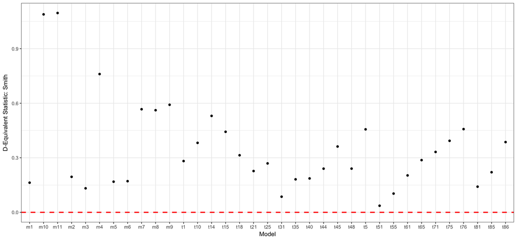

## Results: Wilson Models

#### Table 1

|  | **Model 1** | **Model 2** | **Model 3** | **Model 4** | **Model 5** |  |
| --- | --- | --- | --- | --- | --- | --- |
| (Intercept) | -13.407 | -21.601 | -22.240 | -22.165 | -12.064 |  |
|  | (16.874) | (16.654) | (16.676) | (16.869) | (16.696) |  |
| Female | -5.819 | -6.309* | -6.157 | -6.576* | -5.641 |  |
|  | (3.260) | (3.180) | (3.176) | (3.210) | (3.225) |  |
| Age | -20.942 | -36.999 | -34.923 | -34.994 | -21.675 |  |
|  | (36.731) | (36.164) | (36.048) | (36.404) | (36.321) |  |
| YrsEduc | -39.850 | -33.659 | -31.724 | -35.529 | -41.221 |  |
|  | (23.403) | (22.887) | (22.937) | (23.009) | (23.149) |  |
| Black | 5.511 | 6.006 | 6.235 | 6.709 | 6.048 |  |
|  | (5.858) | (5.709) | (5.708) | (5.762) | (5.797) |  |
| LatinoLatino | 13.081** | 12.549** | 13.058** | 12.440** | 12.610** |  |
|  | (4.254) | (4.147) | (4.142) | (4.179) | (4.212) |  |
| PolSoph | -6.240 | -7.333 | -8.313 | -6.558 | -6.027 |  |
|  | (8.337) | (8.130) | (8.145) | (8.178) | (8.244) |  |
| LibCon | 14.134 | 6.869 | 7.098 | 9.236 | 9.413 |  |
|  | (9.308) | (9.373) | (9.344) | (9.310) | (9.466) |  |
| PanelLength5 Weeks | 4.944 | 4.763 | 4.964 | 4.711 | 5.202 |  |
|  | (4.331) | (4.220) | (4.217) | (4.249) | (4.284) |  |
| DWilsonMemAff5 |  | 58.271** |  |  |  |  |
|  |  | (19.022) |  |  |  |  |
| DWilsonMemAff50 |  |  | 55.865** |  |  |  |
|  |  |  | (18.068) |  |  |  |
| DWilsonIWMemAff5 |  |  |  | 38.553** |  |  |
|  |  |  |  | (14.387) |  |  |
| DWilsonAccRecogMemAff5 |  |  |  |  | 18.910* |  |
|  |  |  |  |  | (8.857) |  |
| R<sup>2</sup> | 0.141 | 0.190 | 0.191 | 0.179 | 0.165 |  |
| Adj. R<sup>2</sup> | 0.097 | 0.143 | 0.144 | 0.131 | 0.117 |  |
| Num. obs. | 165 | 165 | 165 | 165 | 165 |  |
| RMSE | 20.621 | 20.088 | 20.078 | 20.224 | 20.390 |  |
| p < 0.001, p < 0.01, p < 0.05. All models, OLS. DV: Wk5DemWilsonFTR |  |  |  |  |  |  |

#### Table 2

|  | **Model 1** | **Model 2** | **Model 3** | **Model 4** | **Model 5** | **Model 6** | **Model 7** | **Model 8** |  |
| --- | --- | --- | --- | --- | --- | --- | --- | --- | --- |
| (Intercept) | -18.932 | -27.893 | -31.521 | -31.143 | -29.897 | -33.397* | -14.771 | -14.376 |  |
|  | (16.858) | (16.277) | (16.455) | (16.019) | (16.418) | (16.150) | (15.880) | (15.790) |  |
| Female | -10.769** | -10.406*** | -10.917*** | -11.186*** | -11.294*** | -11.706*** | -9.559** | -9.418** |  |
|  | (3.243) | (3.102) | (3.105) | (3.043) | (3.113) | (3.055) | (3.061) | (3.045) |  |
| Age | -40.204 | -57.117 | -59.777 | -62.829 | -57.343 | -62.745 | -44.894 | -45.962 |  |
|  | (36.697) | (35.349) | (35.485) | (34.747) | (35.478) | (34.838) | (34.528) | (34.332) |  |
| YrsEduc | 2.795 | 6.949 | 3.414 | 12.197 | 13.496 | 9.613 | -1.698 | -1.555 |  |
|  | (23.388) | (22.389) | (22.392) | (22.026) | (22.604) | (22.037) | (22.018) | (21.886) |  |
| Black | -7.993 | -6.739 | -6.007 | -7.078 | -6.962 | -5.836 | -5.681 | -5.102 |  |
|  | (5.841) | (5.595) | (5.615) | (5.482) | (5.609) | (5.511) | (5.516) | (5.494) |  |
| LatinoLatino | 18.078*** | 17.759*** | 18.134*** | 17.284*** | 17.952*** | 16.791*** | 17.280*** | 17.073*** |  |
|  | (4.248) | (4.063) | (4.067) | (3.988) | (4.075) | (4.003) | (3.999) | (3.977) |  |
| PolSoph | -4.967 | -6.141 | -5.831 | -6.915 | -7.921 | -5.891 | -5.930 | -5.398 |  |
|  | (8.245) | (7.890) | (7.897) | (7.744) | (7.945) | (7.754) | (7.757) | (7.710) |  |
| LibCon | 25.413** | 16.298 | 16.847 | 14.864 | 17.549 | 17.760* | 14.460 | 15.584 |  |
|  | (9.287) | (9.172) | (9.155) | (8.988) | (9.139) | (8.884) | (9.046) | (8.914) |  |
| PanelLength5 Weeks | 1.474 | 1.598 | 1.624 | 1.027 | 1.295 | 1.144 | 1.796 | 1.600 |  |
|  | (4.262) | (4.075) | (4.080) | (3.998) | (4.088) | (4.007) | (4.009) | (3.985) |  |
| DWilsonDifAff |  | 77.368*** |  |  |  |  |  |  |  |
|  |  | (19.469) |  |  |  |  |  |  |  |
| DWilsonIWDifAff |  |  | 59.535*** |  |  |  |  |  |  |
|  |  |  | (15.178) |  |  |  |  |  |  |
| DWilsonMemAff |  |  |  | 83.642*** |  |  |  |  |  |
|  |  |  |  | (17.592) |  |  |  |  |  |
| DWilsonMemAff0 |  |  |  |  | 65.069*** |  |  |  |  |
|  |  |  |  |  | (16.934) |  |  |  |  |
| DWilsonIWMemAff |  |  |  |  |  | 62.104*** |  |  |  |
|  |  |  |  |  |  | (13.315) |  |  |  |
| DWilsonAccRecogMemAff10 |  |  |  |  |  |  | 44.052*** |  |  |
|  |  |  |  |  |  |  | (9.472) |  |  |
| DWilsonAccAccessedRecogMemAff |  |  |  |  |  |  |  | 45.988*** |  |
|  |  |  |  |  |  |  |  | (9.440) |  |
| R<sup>2</sup> | 0.217 | 0.289 | 0.287 | 0.316 | 0.284 | 0.312 | 0.312 | 0.320 |  |
| Adj. R<sup>2</sup> | 0.178 | 0.248 | 0.246 | 0.276 | 0.243 | 0.273 | 0.273 | 0.281 |  |
| Num. obs. | 167 | 167 | 167 | 167 | 167 | 167 | 167 | 167 |  |
| RMSE | 20.614 | 19.712 | 19.735 | 19.334 | 19.771 | 19.380 | 19.387 | 19.274 |  |
| p < 0.001, p < 0.01, p < 0.05. All models, OLS. DV: Wk10DemWilsonFTR |  |  |  |  |  |  |  |  |  |

#### Table 3

|  | **Model 1** | **Model 2** | **Model 3** | **Model 4** | **Model 5** | **Model 6** | **Model 7** | **Model 8** | **Model 9** |  |
| --- | --- | --- | --- | --- | --- | --- | --- | --- | --- | --- |
| (Intercept) | -13.407 | -8.717 | -7.480 | -8.915 | -5.884 | -13.752 | -12.462 | -9.513 | -7.877 |  |
|  | (16.874) | (17.384) | (17.243) | (16.944) | (17.120) | (16.884) | (16.998) | (17.370) | (17.124) |  |
| Female | -5.819 | -5.570 | -5.008 | -5.316 | -4.727 | -5.858 | -5.866 | -5.747 | -5.281 |  |
|  | (3.260) | (3.266) | (3.290) | (3.250) | (3.274) | (3.262) | (3.269) | (3.262) | (3.260) |  |
| Age | -20.942 | -15.048 | -9.379 | -10.995 | -4.466 | -18.862 | -18.471 | -15.883 | -11.218 |  |
|  | (36.731) | (37.087) | (37.349) | (36.897) | (37.278) | (36.813) | (37.084) | (37.127) | (37.021) |  |
| YrsEduc | -39.850 | -39.404 | -40.159 | -36.827 | -37.825 | -40.095 | -40.012 | -39.040 | -38.631 |  |
|  | (23.403) | (23.389) | (23.304) | (23.301) | (23.197) | (23.413) | (23.457) | (23.426) | (23.291) |  |
| Black | 5.511 | 5.637 | 5.788 | 5.904 | 5.708 | 4.892 | 5.304 | 5.706 | 6.164 |  |
|  | (5.858) | (5.854) | (5.836) | (5.821) | (5.802) | (5.897) | (5.883) | (5.863) | (5.840) |  |
| LatinoLatino | 13.081** | 13.107** | 12.899** | 12.660** | 12.610** | 13.073** | 13.070** | 12.797** | 12.408** |  |
|  | (4.254) | (4.251) | (4.237) | (4.231) | (4.219) | (4.255) | (4.263) | (4.266) | (4.251) |  |
| PolSoph | -6.240 | -5.352 | -5.232 | -4.690 | -5.516 | -5.246 | -5.728 | -5.359 | -5.408 |  |
|  | (8.337) | (8.370) | (8.328) | (8.324) | (8.264) | (8.408) | (8.407) | (8.391) | (8.309) |  |
| LibCon | 14.134 | 13.947 | 12.987 | 14.100 | 12.524 | 13.003 | 13.626 | 13.661 | 11.989 |  |
|  | (9.308) | (9.303) | (9.299) | (9.243) | (9.252) | (9.390) | (9.374) | (9.324) | (9.352) |  |
| PanelLength5 Weeks | 4.944 | 5.721 | 5.837 | 5.572 | 5.609 | 5.475 | 5.487 | 5.544 | 5.776 |  |
|  | (4.331) | (4.384) | (4.352) | (4.315) | (4.302) | (4.370) | (4.451) | (4.378) | (4.338) |  |
| DWilson25Cumu0 |  | 14.138 |  |  |  |  |  |  |  |  |
|  |  | (12.752) |  |  |  |  |  |  |  |  |
| DWilsonWk5WeeklyTally0 |  |  | 21.637 |  |  |  |  |  |  |  |
|  |  |  | (14.152) |  |  |  |  |  |  |  |
| DWilson25Cumu1 |  |  |  | 16.718 |  |  |  |  |  |  |
|  |  |  |  | (9.351) |  |  |  |  |  |  |
| DWilsonWk5WeeklyTally1 |  |  |  |  | 20.256* |  |  |  |  |  |
|  |  |  |  |  | (10.029) |  |  |  |  |  |
| DWilsonWk25WeeklyPBTally1 |  |  |  |  |  | 10.555 |  |  |  |  |
|  |  |  |  |  |  | (11.266) |  |  |  |  |
| DWilsonWk25WeeklyPBTally2 |  |  |  |  |  |  | 6.069 |  |  |  |
|  |  |  |  |  |  |  | (10.988) |  |  |  |
| DWilson25Cumu2 |  |  |  |  |  |  |  | 10.644 |  |  |
|  |  |  |  |  |  |  |  | (11.205) |  |  |
| DWilsonWk5WeeklyTally2 |  |  |  |  |  |  |  |  | 19.133 |  |
|  |  |  |  |  |  |  |  |  | (11.730) |  |
| R<sup>2</sup> | 0.141 | 0.148 | 0.154 | 0.158 | 0.163 | 0.146 | 0.143 | 0.146 | 0.155 |  |
| Adj. R<sup>2</sup> | 0.097 | 0.098 | 0.105 | 0.109 | 0.114 | 0.096 | 0.093 | 0.096 | 0.106 |  |
| Num. obs. | 165 | 165 | 165 | 165 | 165 | 165 | 165 | 165 | 165 |  |
| RMSE | 20.621 | 20.606 | 20.533 | 20.477 | 20.421 | 20.629 | 20.667 | 20.628 | 20.512 |  |
| p < 0.001, p < 0.01, p < 0.05. All models, OLS. DV: Wk5DemWilsonFTR |  |  |  |  |  |  |  |  |  |  |

##### Table 4

|  | **Model 1** | **Model 2** | **Model 3** | **Model 4** | **Model 5** | **Model 6** | **Model 7** | **Model 8** | **Model 9** |  |
| --- | --- | --- | --- | --- | --- | --- | --- | --- | --- | --- |
| (Intercept) | -18.932 | -15.931 | -19.508 | -16.493 | -19.071 | -18.976 | -14.524 | -14.189 | -18.660 |  |
|  | (16.858) | (16.980) | (17.191) | (16.834) | (16.917) | (16.713) | (16.976) | (17.082) | (16.973) |  |
| Female | -10.769** | -10.938*** | -10.731** | -10.928*** | -10.730** | -10.996*** | -11.071*** | -11.021*** | -10.793** |  |
|  | (3.243) | (3.238) | (3.259) | (3.227) | (3.256) | (3.217) | (3.230) | (3.234) | (3.255) |  |
| Age | -40.204 | -37.034 | -40.256 | -35.797 | -40.461 | -38.667 | -35.460 | -34.863 | -39.992 |  |
|  | (36.697) | (36.699) | (36.811) | (36.601) | (36.821) | (36.390) | (36.609) | (36.721) | (36.828) |  |
| YrsEduc | 2.795 | 4.060 | 2.605 | 6.001 | 2.280 | 4.951 | 2.889 | 3.722 | 3.023 |  |
|  | (23.388) | (23.358) | (23.482) | (23.346) | (23.547) | (23.213) | (23.261) | (23.302) | (23.492) |  |
| Black | -7.993 | -7.957 | -7.978 | -7.681 | -7.961 | -8.749 | -8.479 | -7.893 | -8.028 |  |
|  | (5.841) | (5.829) | (5.860) | (5.813) | (5.860) | (5.804) | (5.817) | (5.818) | (5.862) |  |
| LatinoLatino | 18.078*** | 18.249*** | 17.994*** | 18.063*** | 17.962*** | 17.951*** | 17.787*** | 17.758*** | 18.100*** |  |
|  | (4.248) | (4.241) | (4.285) | (4.226) | (4.285) | (4.212) | (4.229) | (4.236) | (4.263) |  |
| PolSoph | -4.967 | -3.945 | -5.008 | -3.613 | -5.082 | -3.069 | -3.533 | -3.999 | -4.897 |  |
|  | (8.245) | (8.265) | (8.273) | (8.243) | (8.282) | (8.232) | (8.246) | (8.237) | (8.279) |  |
| LibCon | 25.413** | 24.609** | 25.653** | 24.703** | 25.748** | 22.324* | 22.889* | 24.341** | 25.142** |  |
|  | (9.287) | (9.287) | (9.404) | (9.247) | (9.409) | (9.343) | (9.361) | (9.276) | (9.428) |  |
| PanelLength5 Weeks | 1.474 | 2.167 | 1.454 | 2.082 | 1.407 | 2.127 | 2.541 | 2.267 | 1.518 |  |
|  | (4.262) | (4.286) | (4.276) | (4.255) | (4.282) | (4.238) | (4.287) | (4.277) | (4.281) |  |
| DWilson29Cumu0 |  | 13.895 |  |  |  |  |  |  |  |  |
|  |  | (10.702) |  |  |  |  |  |  |  |  |
| DWilsonWk9WeeklyTally0 |  |  | -2.915 |  |  |  |  |  |  |  |
|  |  |  | (15.655) |  |  |  |  |  |  |  |
| DWilson29Cumu1 |  |  |  | 15.487 |  |  |  |  |  |  |
|  |  |  |  | (9.431) |  |  |  |  |  |  |
| DWilsonWk9WeeklyTally1 |  |  |  |  | -2.644 |  |  |  |  |  |
|  |  |  |  |  | (10.482) |  |  |  |  |  |
| DWilsonWk29WeeklyPBTally1 |  |  |  |  |  | 21.344 |  |  |  |  |
|  |  |  |  |  |  | (11.005) |  |  |  |  |
| DWilsonWk29WeeklyPBTally2 |  |  |  |  |  |  | 21.323 |  |  |  |
|  |  |  |  |  |  |  | (12.881) |  |  |  |
| DWilson29Cumu2 |  |  |  |  |  |  |  | 15.408 |  |  |
|  |  |  |  |  |  |  |  | (10.207) |  |  |
| DWilsonWk9WeeklyTally2 |  |  |  |  |  |  |  |  | 2.282 |  |
|  |  |  |  |  |  |  |  |  | (12.271) |  |
| R<sup>2</sup> | 0.217 | 0.225 | 0.217 | 0.230 | 0.217 | 0.235 | 0.231 | 0.228 | 0.217 |  |
| Adj. R<sup>2</sup> | 0.178 | 0.181 | 0.172 | 0.186 | 0.173 | 0.192 | 0.186 | 0.184 | 0.172 |  |
| Num. obs. | 167 | 167 | 167 | 167 | 167 | 167 | 167 | 167 | 167 |  |
| RMSE | 20.614 | 20.569 | 20.677 | 20.504 | 20.675 | 20.436 | 20.501 | 20.531 | 20.677 |  |
| p < 0.001, p < 0.01, p < 0.05. All models, OLS. DV: Wk10DemWilsonFTR |  |  |  |  |  |  |  |  |  |  |

#### Table 5

|  | **Model 1** | **Model 2** | **Model 3** | **Model 4** | **Model 5** | **Model 6** | **Model 7** | **Model 8** | **Model 9** |  |
| --- | --- | --- | --- | --- | --- | --- | --- | --- | --- | --- |
| (Intercept) | -18.932 | -16.063 | -17.661 | -16.098 | -18.484 | -15.269 | -11.927 | -17.265 | -9.451 |  |
|  | (16.858) | (16.836) | (17.026) | (16.700) | (16.885) | (16.759) | (17.042) | (16.937) | (17.410) |  |
| Female | -10.769** | -11.027*** | -10.869** | -10.979*** | -10.818** | -10.968*** | -11.143*** | -10.862** | -11.062*** |  |
|  | (3.243) | (3.226) | (3.254) | (3.204) | (3.247) | (3.208) | (3.216) | (3.244) | (3.218) |  |
| Age | -40.204 | -37.712 | -40.367 | -36.751 | -40.333 | -35.642 | -32.821 | -39.307 | -32.065 |  |
|  | (36.697) | (36.499) | (36.774) | (36.281) | (36.738) | (36.353) | (36.516) | (36.705) | (36.620) |  |
| YrsEduc | 2.795 | 4.734 | 3.825 | 7.581 | 5.142 | 5.565 | 4.006 | 4.810 | 2.631 |  |
|  | (23.388) | (23.271) | (23.500) | (23.202) | (23.592) | (23.165) | (23.166) | (23.471) | (23.186) |  |
| Black | -7.993 | -8.619 | -8.365 | -8.360 | -8.620 | -8.273 | -8.254 | -8.604 | -8.198 |  |
|  | (5.841) | (5.816) | (5.886) | (5.772) | (5.898) | (5.778) | (5.785) | (5.872) | (5.792) |  |
| LatinoLatino | 18.078*** | 18.172*** | 18.209*** | 17.824*** | 18.227*** | 18.025*** | 17.522*** | 18.001*** | 17.961*** |  |
|  | (4.248) | (4.222) | (4.263) | (4.198) | (4.257) | (4.201) | (4.215) | (4.249) | (4.212) |  |
| PolSoph | -4.967 | -3.479 | -4.737 | -2.993 | -4.405 | -3.507 | -3.370 | -4.331 | -3.839 |  |
|  | (8.245) | (8.240) | (8.271) | (8.192) | (8.283) | (8.182) | (8.201) | (8.268) | (8.194) |  |
| LibCon | 25.413** | 23.862* | 24.528* | 23.722* | 24.214* | 22.317* | 23.476* | 23.791* | 22.266* |  |
|  | (9.287) | (9.273) | (9.423) | (9.204) | (9.413) | (9.297) | (9.244) | (9.423) | (9.348) |  |
| PanelLength5 Weeks | 1.474 | 2.293 | 1.557 | 2.111 | 1.656 | 1.652 | 2.428 | 1.674 | 1.744 |  |
|  | (4.262) | (4.262) | (4.273) | (4.219) | (4.272) | (4.215) | (4.246) | (4.266) | (4.227) |  |
| DWilsonMR29Cumu0 |  | 19.212 |  |  |  |  |  |  |  |  |
|  |  | (11.145) |  |  |  |  |  |  |  |  |
| DWilsonWk9MRWeeklyTally0 |  |  | 9.068 |  |  |  |  |  |  |  |
|  |  |  | (15.197) |  |  |  |  |  |  |  |
| DWilsonMR29Cumu1 |  |  |  | 22.647* |  |  |  |  |  |  |
|  |  |  |  | (10.186) |  |  |  |  |  |  |
| DWilsonWk9MRWeeklyTally1 |  |  |  |  | 8.551 |  |  |  |  |  |
|  |  |  |  |  | (10.543) |  |  |  |  |  |
| DWilsonMR29PB1 |  |  |  |  |  | 25.488* |  |  |  |  |
|  |  |  |  |  |  | (11.926) |  |  |  |  |
| DWilsonMR29Cumu2 |  |  |  |  |  |  | 25.962* |  |  |  |
|  |  |  |  |  |  |  | (12.731) |  |  |  |
| DWilsonWk9MRWeeklyTally2 |  |  |  |  |  |  |  | 13.255 |  |  |
|  |  |  |  |  |  |  |  | (13.099) |  |  |
| DWilsonMR29PB2 |  |  |  |  |  |  |  |  | 25.457 |  |
|  |  |  |  |  |  |  |  |  | (13.103) |  |
| R<sup>2</sup> | 0.217 | 0.232 | 0.219 | 0.241 | 0.220 | 0.239 | 0.237 | 0.222 | 0.236 |  |
| Adj. R<sup>2</sup> | 0.178 | 0.188 | 0.174 | 0.198 | 0.176 | 0.196 | 0.194 | 0.178 | 0.192 |  |
| Num. obs. | 167 | 167 | 167 | 167 | 167 | 167 | 167 | 167 | 167 |  |
| RMSE | 20.614 | 20.486 | 20.656 | 20.361 | 20.636 | 20.385 | 20.411 | 20.612 | 20.435 |  |
| p < 0.001, p < 0.01, p < 0.05. All models, OLS. DV: Wk10DemWilsonFTR |  |  |  |  |  |  |  |  |  |  |

### Effect Sizes

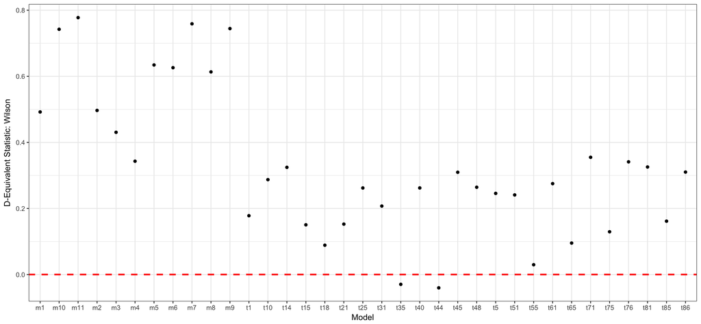

## Results: Jones Models

#### Table 1

|  | **Model 1** | **Model 2** | **Model 3** | **Model 4** | **Model 5** |  |
| --- | --- | --- | --- | --- | --- | --- |
| (Intercept) | -48.139 | -52.204 | -52.351 | -54.739 | -44.373 |  |
|  | (27.559) | (27.495) | (27.484) | (27.515) | (27.837) |  |
| Female | -11.680 | -10.774 | -10.923 | -10.401 | -10.265 |  |
|  | (6.008) | (5.995) | (5.981) | (5.985) | (6.182) |  |
| Age | -86.356 | -93.054 | -93.487 | -98.847 | -80.662 |  |
|  | (65.429) | (65.097) | (65.075) | (65.070) | (65.711) |  |
| YrsEduc | -69.800 | -72.286 | -71.540 | -74.599 | -59.929 |  |
|  | (40.780) | (40.504) | (40.462) | (40.383) | (42.028) |  |
| Black | -23.540 | -21.075 | -20.619 | -20.293 | -15.075 |  |
|  | (21.424) | (21.330) | (21.342) | (21.252) | (23.118) |  |
| LatinoLatino | 1.048 | 1.075 | 1.009 | 2.202 | 2.475 |  |
|  | (7.583) | (7.525) | (7.521) | (7.523) | (7.726) |  |
| PolSoph | -13.752 | -12.536 | -12.941 | -13.198 | -13.513 |  |
|  | (11.101) | (11.049) | (11.024) | (10.969) | (11.108) |  |
| LibCon | 82.427*** | 77.659*** | 77.146*** | 77.087*** | 72.990*** |  |
|  | (14.447) | (14.720) | (14.781) | (14.636) | (17.386) |  |
| PanelLength5 Weeks | 2.574 | 3.147 | 3.406 | 3.044 | 1.376 |  |
|  | (6.459) | (6.422) | (6.432) | (6.386) | (6.577) |  |
| RJonesMemAff5 |  | 26.572 |  |  |  |  |
|  |  | (18.605) |  |  |  |  |
| RJonesMemAff50 |  |  | 25.383 |  |  |  |
|  |  |  | (17.443) |  |  |  |
| RJonesIWMemAff5 |  |  |  | 26.442 |  |  |
|  |  |  |  | (16.137) |  |  |
| RJonesAccRecogMemAff5 |  |  |  |  | 16.490 |  |
|  |  |  |  |  | (16.887) |  |
| R<sup>2</sup> | 0.399 | 0.417 | 0.417 | 0.422 | 0.407 |  |
| Adj. R<sup>2</sup> | 0.327 | 0.337 | 0.338 | 0.343 | 0.326 |  |
| Num. obs. | 76 | 76 | 76 | 76 | 76 |  |
| RMSE | 20.204 | 20.049 | 20.038 | 19.955 | 20.211 |  |
| p < 0.001, p < 0.01, p < 0.05. All models, OLS. DV: Wk5RepJonesFTR |  |  |  |  |  |  |

#### Table 2

|  | **Model 1** | **Model 2** | **Model 3** | **Model 4** | **Model 5** | **Model 6** | **Model 7** | **Model 8** |  |
| --- | --- | --- | --- | --- | --- | --- | --- | --- | --- |
| (Intercept) | -33.513 | -39.176 | -40.213 | -45.318 | -49.045 | -49.475 | -17.761 | -18.629 |  |
|  | (28.497) | (27.254) | (27.841) | (26.440) | (25.931) | (26.883) | (27.757) | (27.495) |  |
| Female | -20.752** | -18.323** | -18.364** | -18.838** | -19.299** | -18.941** | -14.890* | -15.100* |  |
|  | (6.235) | (6.009) | (6.148) | (5.765) | (5.625) | (5.818) | (6.305) | (6.216) |  |
| Age | -65.470 | -73.413 | -77.747 | -84.583 | -89.777 | -94.670 | -35.772 | -37.256 |  |
|  | (67.339) | (64.288) | (65.640) | (62.231) | (60.915) | (63.149) | (65.100) | (64.581) |  |
| YrsEduc | -51.844 | -59.955 | -64.881 | -55.226 | -52.978 | -57.497 | -25.661 | -22.685 |  |
|  | (42.478) | (40.617) | (41.665) | (39.128) | (38.247) | (39.509) | (41.582) | (41.484) |  |
| Black | -26.313 | -26.259 | -26.772 | -23.570 | -21.664 | -23.123 | 4.248 | 6.753 |  |
|  | (22.380) | (21.345) | (21.742) | (20.623) | (20.182) | (20.819) | (23.975) | (24.004) |  |
| LatinoLatino | 1.090 | 1.209 | 2.451 | 1.536 | 1.411 | 3.458 | 3.125 | 3.339 |  |
|  | (7.894) | (7.529) | (7.692) | (7.271) | (7.108) | (7.368) | (7.565) | (7.526) |  |
| PolSoph | -23.278* | -17.608 | -19.332 | -18.403 | -18.920 | -19.569 | -22.296* | -23.791* |  |
|  | (11.465) | (11.121) | (11.273) | (10.642) | (10.376) | (10.709) | (10.941) | (10.876) |  |
| LibCon | 73.050*** | 66.082*** | 68.422*** | 61.663*** | 58.392*** | 61.962*** | 48.245** | 48.287** |  |
|  | (14.738) | (14.275) | (14.462) | (13.925) | (13.735) | (14.068) | (16.616) | (16.305) |  |
| PanelLength5 Weeks | -0.395 | 0.352 | 0.764 | -0.105 | 0.726 | -0.382 | -1.752 | -0.844 |  |
|  | (6.539) | (6.242) | (6.373) | (6.022) | (5.894) | (6.076) | (6.256) | (6.204) |  |
| RJonesDifAff |  | 56.362** |  |  |  |  |  |  |  |
|  |  | (20.113) |  |  |  |  |  |  |  |
| RJonesIWDifAff |  |  | 42.329* |  |  |  |  |  |  |
|  |  |  | (18.711) |  |  |  |  |  |  |
| RJonesMemAff |  |  |  | 60.204*** |  |  |  |  |  |
|  |  |  |  | (16.467) |  |  |  |  |  |
| RJonesMemAff0 |  |  |  |  | 68.797*** |  |  |  |  |
|  |  |  |  |  | (16.630) |  |  |  |  |
| RJonesIWMemAff |  |  |  |  |  | 49.705*** |  |  |  |
|  |  |  |  |  |  | (14.410) |  |  |  |
| RJonesAccRecogMemAff10 |  |  |  |  |  |  | 43.176** |  |  |
|  |  |  |  |  |  |  | (15.420) |  |  |
| RJonesAccAccessedRecogMemAff |  |  |  |  |  |  |  | 46.907** |  |
|  |  |  |  |  |  |  |  | (15.900) |  |
| R<sup>2</sup> | 0.355 | 0.422 | 0.400 | 0.461 | 0.485 | 0.451 | 0.422 | 0.428 |  |
| Adj. R<sup>2</sup> | 0.280 | 0.345 | 0.321 | 0.390 | 0.417 | 0.379 | 0.345 | 0.353 |  |
| Num. obs. | 78 | 78 | 78 | 78 | 78 | 78 | 78 | 78 |  |
| RMSE | 21.148 | 20.170 | 20.544 | 19.474 | 19.041 | 19.653 | 20.172 | 20.058 |  |
| p < 0.001, p < 0.01, p < 0.05. All models, OLS. DV: Wk10RepJonesFTR |  |  |  |  |  |  |  |  |  |

#### Table 3

|  | **Model 1** | **Model 2** | **Model 3** | **Model 4** | **Model 5** | **Model 6** | **Model 7** | **Model 8** | **Model 9** |  |
| --- | --- | --- | --- | --- | --- | --- | --- | --- | --- | --- |
| (Intercept) | -48.139 | -41.899 | -35.373 | -40.593 | -33.049 | -48.179 | -47.501 | -40.733 | -43.056 |  |
|  | (27.559) | (28.177) | (26.997) | (28.186) | (26.620) | (27.773) | (27.776) | (27.497) | (26.170) |  |
| Female | -11.680 | -11.842 | -12.464* | -11.648 | -12.557* | -11.701 | -11.651 | -12.453* | -14.081* |  |
|  | (6.008) | (6.005) | (5.789) | (5.989) | (5.701) | (6.062) | (6.046) | (5.938) | (5.751) |  |
| Age | -86.356 | -78.951 | -69.814 | -74.608 | -65.128 | -86.265 | -87.113 | -80.722 | -86.352 |  |
|  | (65.429) | (65.764) | (63.301) | (65.956) | (62.429) | (65.936) | (65.867) | (64.567) | (61.996) |  |
| YrsEduc | -69.800 | -61.504 | -55.876 | -60.504 | -53.199 | -70.237 | -67.774 | -57.232 | -51.740 |  |
|  | (40.780) | (41.514) | (39.627) | (41.386) | (39.060) | (41.647) | (41.338) | (40.845) | (39.126) |  |
| Black | -23.540 | -15.995 | -7.881 | -11.900 | -0.656 | -24.113 | -20.551 | -9.302 | -0.930 |  |
|  | (21.424) | (22.590) | (21.531) | (23.469) | (21.752) | (23.353) | (22.780) | (22.669) | (21.711) |  |
| LatinoLatino | 1.048 | 0.768 | 2.550 | 1.176 | 3.695 | 1.024 | 1.113 | -0.066 | 2.163 |  |
|  | (7.583) | (7.583) | (7.322) | (7.560) | (7.243) | (7.649) | (7.633) | (7.502) | (7.196) |  |
| PolSoph | -13.752 | -14.261 | -12.356 | -13.185 | -10.908 | -13.756 | -13.875 | -15.884 | -12.634 |  |
|  | (11.101) | (11.104) | (10.696) | (11.076) | (10.565) | (11.185) | (11.175) | (11.010) | (10.525) |  |
| LibCon | 82.427*** | 79.451*** | 66.957*** | 75.841*** | 60.241*** | 82.908*** | 79.957*** | 76.389*** | 63.543*** |  |
|  | (14.447) | (14.714) | (15.195) | (15.418) | (15.643) | (16.365) | (15.759) | (14.662) | (15.124) |  |
| PanelLength5 Weeks | 2.574 | 3.048 | 2.115 | 1.750 | 0.375 | 2.711 | 1.526 | 2.285 | 1.386 |  |
|  | (6.459) | (6.471) | (6.218) | (6.475) | (6.167) | (6.848) | (6.993) | (6.368) | (6.134) |  |
| RJones25Cumu0 |  | 16.120 |  |  |  |  |  |  |  |  |
|  |  | (15.400) |  |  |  |  |  |  |  |  |
| RJonesWk5WeeklyTally0 |  |  | 45.281* |  |  |  |  |  |  |  |
|  |  |  | (17.957) |  |  |  |  |  |  |  |
| RJones25Cumu1 |  |  |  | 20.861 |  |  |  |  |  |  |
|  |  |  |  | (17.442) |  |  |  |  |  |  |
| RJonesWk5WeeklyTally1 |  |  |  |  | 46.774** |  |  |  |  |  |
|  |  |  |  |  | (15.952) |  |  |  |  |  |
| RJonesWk25WeeklyPBTally1 |  |  |  |  |  | -0.887 |  |  |  |  |
|  |  |  |  |  |  | (13.799) |  |  |  |  |
| RJonesWk25WeeklyPBTally2 |  |  |  |  |  |  | 5.548 |  |  |  |
|  |  |  |  |  |  |  | (13.656) |  |  |  |
| RJones25Cumu2 |  |  |  |  |  |  |  | 27.254 |  |  |
|  |  |  |  |  |  |  |  | (15.792) |  |  |
| RJonesWk5WeeklyTally2 |  |  |  |  |  |  |  |  | 47.568** |  |
|  |  |  |  |  |  |  |  |  | (16.195) |  |
| R<sup>2</sup> | 0.399 | 0.408 | 0.451 | 0.411 | 0.468 | 0.399 | 0.400 | 0.425 | 0.468 |  |
| Adj. R<sup>2</sup> | 0.327 | 0.328 | 0.377 | 0.331 | 0.395 | 0.317 | 0.318 | 0.346 | 0.396 |  |
| Num. obs. | 76 | 76 | 76 | 76 | 76 | 76 | 76 | 76 | 76 |  |
| RMSE | 20.204 | 20.190 | 19.442 | 20.140 | 19.148 | 20.356 | 20.331 | 19.912 | 19.144 |  |
| p < 0.001, p < 0.01, p < 0.05. All models, OLS. DV: Wk5RepJonesFTR |  |  |  |  |  |  |  |  |  |  |

#### Table 4

|  | **Model 1** | **Model 2** | **Model 3** | **Model 4** | **Model 5** | **Model 6** | **Model 7** | **Model 8** | **Model 9** |  |
| --- | --- | --- | --- | --- | --- | --- | --- | --- | --- | --- |
| (Intercept) | -33.513 | -17.449 | -15.246 | -17.648 | -21.433 | -28.163 | -32.199 | -24.399 | -22.560 |  |
|  | (28.497) | (27.915) | (28.753) | (27.386) | (26.981) | (26.497) | (26.200) | (26.819) | (26.629) |  |
| Female | -20.752** | -23.275*** | -23.175*** | -23.321*** | -24.232*** | -19.526** | -21.615*** | -24.568*** | -25.226*** |  |
|  | (6.235) | (6.040) | (6.138) | (5.943) | (5.944) | (5.798) | (5.736) | (5.951) | (5.926) |  |
| Age | -65.470 | -49.240 | -46.105 | -40.715 | -45.339 | -61.522 | -72.009 | -58.178 | -55.434 |  |
|  | (67.339) | (64.733) | (65.858) | (64.063) | (63.449) | (62.519) | (61.931) | (63.074) | (62.552) |  |
| YrsEduc | -51.844 | -28.113 | -43.047 | -23.733 | -28.446 | -26.273 | -29.332 | -23.266 | -26.936 |  |
|  | (42.478) | (41.594) | (41.381) | (41.120) | (40.483) | (40.112) | (39.523) | (40.707) | (40.060) |  |
| Black | -26.313 | 0.932 | -8.669 | 14.234 | 6.499 | 9.939 | 8.804 | 13.467 | 11.449 |  |
|  | (22.380) | (23.671) | (23.016) | (24.899) | (23.307) | (23.247) | (22.665) | (24.210) | (23.426) |  |
| LatinoLatino | 1.090 | -1.048 | -0.068 | 0.869 | 3.402 | 1.629 | 1.296 | -1.312 | 2.182 |  |
|  | (7.894) | (7.597) | (7.674) | (7.451) | (7.437) | (7.330) | (7.258) | (7.426) | (7.332) |  |
| PolSoph | -23.278* | -26.321* | -23.521* | -24.701* | -21.654* | -22.233* | -25.117* | -28.377* | -22.035* |  |
|  | (11.465) | (11.031) | (11.122) | (10.831) | (10.762) | (10.647) | (10.552) | (10.844) | (10.645) |  |
| LibCon | 73.050*** | 58.599*** | 58.026*** | 51.311** | 48.014** | 44.095** | 48.261** | 55.123*** | 47.651** |  |
|  | (14.738) | (15.084) | (15.708) | (15.603) | (15.838) | (16.019) | (15.120) | (14.840) | (15.498) |  |
| PanelLength5 Weeks | -0.395 | 1.533 | -0.406 | -0.561 | -1.537 | -5.988 | -7.674 | 0.744 | -0.843 |  |
|  | (6.539) | (6.299) | (6.343) | (6.172) | (6.141) | (6.279) | (6.326) | (6.131) | (6.069) |  |
| RJones29Cumu0 |  | 48.619** |  |  |  |  |  |  |  |  |
|  |  | (17.974) |  |  |  |  |  |  |  |  |
| RJonesWk9WeeklyTally0 |  |  | 42.370* |  |  |  |  |  |  |  |
|  |  |  | (18.355) |  |  |  |  |  |  |  |
| RJones29Cumu1 |  |  |  | 64.464** |  |  |  |  |  |  |
|  |  |  |  | (20.959) |  |  |  |  |  |  |
| RJonesWk9WeeklyTally1 |  |  |  |  | 50.865** |  |  |  |  |  |
|  |  |  |  |  | (15.717) |  |  |  |  |  |
| RJonesWk29WeeklyPBTally1 |  |  |  |  |  | 52.425*** |  |  |  |  |
|  |  |  |  |  |  | (15.086) |  |  |  |  |
| RJonesWk29WeeklyPBTally2 |  |  |  |  |  |  | 53.186*** |  |  |  |
|  |  |  |  |  |  |  | (14.399) |  |  |  |
| RJones29Cumu2 |  |  |  |  |  |  |  | 62.667** |  |  |
|  |  |  |  |  |  |  |  | (19.116) |  |  |
| RJonesWk9WeeklyTally2 |  |  |  |  |  |  |  |  | 65.423*** |  |
|  |  |  |  |  |  |  |  |  | (18.781) |  |
| R<sup>2</sup> | 0.355 | 0.418 | 0.402 | 0.434 | 0.441 | 0.452 | 0.463 | 0.443 | 0.453 |  |
| Adj. R<sup>2</sup> | 0.280 | 0.341 | 0.323 | 0.359 | 0.367 | 0.380 | 0.392 | 0.369 | 0.380 |  |
| Num. obs. | 78 | 78 | 78 | 78 | 78 | 78 | 78 | 78 | 78 |  |
| RMSE | 21.148 | 20.242 | 20.514 | 19.960 | 19.830 | 19.631 | 19.441 | 19.796 | 19.624 |  |
| p < 0.001, p < 0.01, p < 0.05. All models, OLS. DV: Wk10RepJonesFTR |  |  |  |  |  |  |  |  |  |  |

#### Table 5

|  | **Model 1** | **Model 2** | **Model 3** | **Model 4** | **Model 5** | **Model 6** | **Model 7** | **Model 8** | **Model 9** |  |
| --- | --- | --- | --- | --- | --- | --- | --- | --- | --- | --- |
| (Intercept) | -33.513 | -20.331 | -15.952 | -13.645 | -9.829 | -11.431 | -19.637 | -13.652 | -17.299 |  |
|  | (28.497) | (27.213) | (29.291) | (27.419) | (28.126) | (27.973) | (26.963) | (27.577) | (27.183) |  |
| Female | -20.752** | -23.323*** | -22.793*** | -22.821*** | -23.460*** | -22.258*** | -23.931*** | -24.127*** | -23.763*** |  |
|  | (6.235) | (5.939) | (6.194) | (5.881) | (5.973) | (5.925) | (5.906) | (5.970) | (5.919) |  |
| Age | -65.470 | -68.429 | -51.563 | -56.221 | -47.488 | -75.295 | -69.243 | -55.208 | -77.760 |  |
|  | (67.339) | (63.519) | (66.334) | (63.212) | (64.055) | (63.846) | (62.953) | (63.502) | (63.250) |  |
| YrsEduc | -51.844 | -17.408 | -43.320 | -16.915 | -27.229 | -25.194 | -19.771 | -25.935 | -28.891 |  |
|  | (42.478) | (41.582) | (41.831) | (41.272) | (41.062) | (41.195) | (40.868) | (40.852) | (40.452) |  |
| Black | -26.313 | -1.433 | -15.207 | 8.434 | -4.240 | -4.204 | 4.631 | -1.589 | -2.706 |  |
|  | (22.380) | (22.589) | (22.629) | (23.576) | (22.444) | (22.441) | (22.909) | (22.508) | (22.213) |  |
| LatinoLatino | 1.090 | -0.424 | 0.818 | 0.529 | 5.016 | 0.445 | -1.249 | 4.520 | -0.279 |  |
|  | (7.894) | (7.462) | (7.734) | (7.405) | (7.591) | (7.478) | (7.413) | (7.515) | (7.414) |  |
| PolSoph | -23.278* | -23.923* | -22.617* | -22.675* | -19.884 | -20.124 | -26.869* | -19.855 | -24.006* |  |
|  | (11.465) | (10.815) | (11.235) | (10.753) | (10.917) | (10.907) | (10.771) | (10.853) | (10.752) |  |
| LibCon | 73.050*** | 53.868*** | 59.486*** | 46.483** | 47.947** | 48.997** | 52.840*** | 46.845** | 52.751*** |  |
|  | (14.738) | (15.221) | (15.982) | (16.077) | (16.289) | (16.103) | (15.066) | (16.209) | (15.173) |  |
| PanelLength5 Weeks | -0.395 | 1.953 | -0.338 | -0.313 | -1.706 | -0.229 | 0.988 | -0.989 | 0.424 |  |
|  | (6.539) | (6.214) | (6.405) | (6.132) | (6.208) | (6.192) | (6.126) | (6.161) | (6.136) |  |
| RJonesMR29Cumu0 |  | 56.230** |  |  |  |  |  |  |  |  |
|  |  | (18.180) |  |  |  |  |  |  |  |  |
| RJonesWk9MRWeeklyTally0 |  |  | 42.836 |  |  |  |  |  |  |  |
|  |  |  | (21.653) |  |  |  |  |  |  |  |
| RJonesMR29Cumu1 |  |  |  | 72.897** |  |  |  |  |  |  |
|  |  |  |  | (22.534) |  |  |  |  |  |  |
| RJonesWk9MRWeeklyTally1 |  |  |  |  | 61.893** |  |  |  |  |  |
|  |  |  |  |  | (20.704) |  |  |  |  |  |
| RJonesMR29PB1 |  |  |  |  |  | 79.180** |  |  |  |  |
|  |  |  |  |  |  | (26.451) |  |  |  |  |
| RJonesMR29Cumu2 |  |  |  |  |  |  | 64.934** |  |  |  |
|  |  |  |  |  |  |  | (19.599) |  |  |  |
| RJonesWk9MRWeeklyTally2 |  |  |  |  |  |  |  | 62.986** |  |  |
|  |  |  |  |  |  |  |  | (20.123) |  |  |
| RJonesMR29PB2 |  |  |  |  |  |  |  |  | 68.166** |  |
|  |  |  |  |  |  |  |  |  | (21.044) |  |
| R<sup>2</sup> | 0.355 | 0.435 | 0.390 | 0.441 | 0.430 | 0.430 | 0.445 | 0.436 | 0.441 |  |
| Adj. R<sup>2</sup> | 0.280 | 0.360 | 0.310 | 0.367 | 0.355 | 0.355 | 0.371 | 0.362 | 0.367 |  |
| Num. obs. | 78 | 78 | 78 | 78 | 78 | 78 | 78 | 78 | 78 |  |
| RMSE | 21.148 | 19.946 | 20.715 | 19.831 | 20.027 | 20.024 | 19.767 | 19.916 | 19.828 |  |
| p < 0.001, p < 0.01, p < 0.05. All models, OLS. DV: Wk10RepJonesFTR |  |  |  |  |  |  |  |  |  |  |

### Effect Sizes

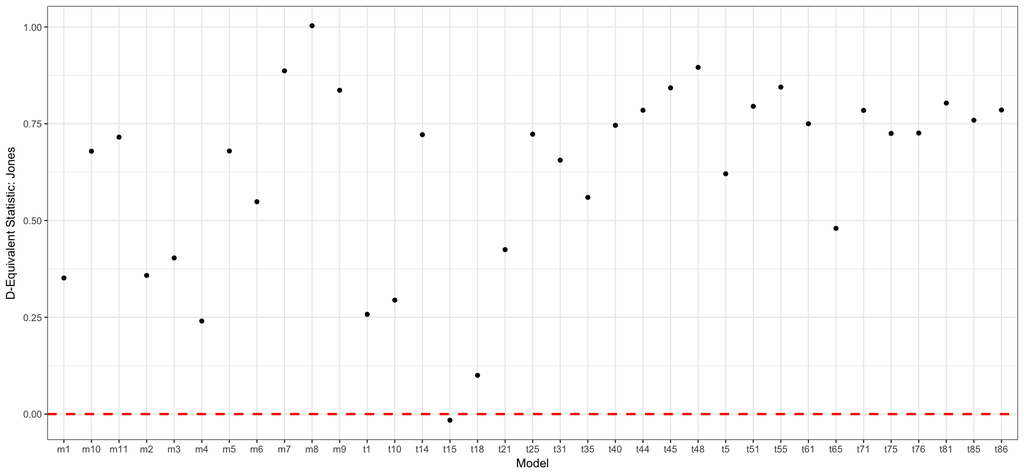

## Results: Williams Models

#### Table 1

|  | **Model 1** | **Model 2** | **Model 3** | **Model 4** | **Model 5** |  |
| --- | --- | --- | --- | --- | --- | --- |
| (Intercept) | -58.178* | -69.249** | -72.514** | -67.070** | -46.569* |  |
|  | (22.799) | (23.059) | (23.133) | (22.898) | (22.756) |  |
| Female | 0.188 | -0.944 | -1.088 | -0.684 | 1.421 |  |
|  | (4.970) | (4.905) | (4.871) | (4.904) | (4.861) |  |
| Age | -142.696* | -164.476** | -168.140** | -160.707** | -123.773* |  |
|  | (54.130) | (54.220) | (53.939) | (54.040) | (53.275) |  |
| YrsEduc | 7.713 | -3.881 | -5.379 | -3.424 | -0.153 |  |
|  | (33.737) | (33.597) | (33.368) | (33.673) | (32.969) |  |
| Black | 21.639 | 18.962 | 18.967 | 22.052 | 21.054 |  |
|  | (17.724) | (17.424) | (17.289) | (17.410) | (17.223) |  |
| LatinoLatino | 13.897* | 15.169* | 15.001* | 14.420* | 12.261* |  |
|  | (6.274) | (6.183) | (6.125) | (6.168) | (6.140) |  |
| PolSoph | 4.929 | 4.833 | 4.214 | 6.018 | 2.085 |  |
|  | (9.184) | (9.000) | (8.942) | (9.039) | (9.014) |  |
| LibCon | -8.571 | -6.656 | -5.919 | -9.541 | -7.232 |  |
|  | (11.952) | (11.754) | (11.692) | (11.751) | (11.629) |  |
| PanelLength5 Weeks | 6.070 | 5.989 | 5.986 | 5.027 | 4.718 |  |
|  | (5.344) | (5.237) | (5.200) | (5.278) | (5.228) |  |
| RWilliamsMemAff5 |  | 33.825 |  |  |  |  |
|  |  | (17.428) |  |  |  |  |
| RWilliamsMemAff50 |  |  | 39.842* |  |  |  |
|  |  |  | (18.234) |  |  |  |
| RWilliamsIWMemAff5 |  |  |  | 22.189 |  |  |
|  |  |  |  | (11.935) |  |  |
| RWilliamsAccRecogMemAff5 |  |  |  |  | 24.757* |  |
|  |  |  |  |  | (11.105) |  |
| R<sup>2</sup> | 0.264 | 0.304 | 0.314 | 0.301 | 0.316 |  |
| Adj. R<sup>2</sup> | 0.176 | 0.209 | 0.220 | 0.206 | 0.223 |  |
| Num. obs. | 76 | 76 | 76 | 76 | 76 |  |
| RMSE | 16.715 | 16.380 | 16.263 | 16.417 | 16.241 |  |
| p < 0.001, p < 0.01, p < 0.05. All models, OLS. DV: Wk5RepWilliamsFTR |  |  |  |  |  |  |

#### Table 2

|  | **Model 1** | **Model 2** | **Model 3** | **Model 4** | **Model 5** | **Model 6** | **Model 7** | **Model 8** |  |
| --- | --- | --- | --- | --- | --- | --- | --- | --- | --- |
| (Intercept) | 8.418 | -7.755 | -1.221 | -5.346 | -7.266 | -3.072 | 35.357 | 33.148 |  |
|  | (27.961) | (28.774) | (28.575) | (27.757) | (28.121) | (27.712) | (26.624) | (26.195) |  |
| Female | 3.526 | 2.056 | 2.947 | 1.667 | 1.786 | 2.028 | 5.560 | 4.446 |  |
|  | (6.099) | (6.039) | (6.068) | (5.968) | (5.986) | (5.975) | (5.616) | (5.550) |  |
| Age | 11.969 | -16.667 | -7.561 | -13.970 | -14.872 | -10.236 | 62.021 | 52.038 |  |
|  | (66.417) | (66.974) | (67.351) | (65.368) | (65.757) | (65.426) | (62.333) | (61.245) |  |
| YrsEduc | -32.109 | -39.976 | -37.846 | -49.007 | -47.828 | -49.225 | -41.586 | -37.551 |  |
|  | (41.335) | (40.803) | (41.230) | (40.740) | (40.844) | (40.978) | (37.971) | (37.604) |  |
| Black | 24.783 | 19.217 | 22.865 | 20.296 | 21.407 | 25.592 | 26.395 | 25.385 |  |
|  | (21.726) | (21.538) | (21.609) | (21.155) | (21.193) | (21.147) | (19.918) | (19.753) |  |
| LatinoLatino | 5.709 | 7.948 | 6.777 | 7.673 | 7.237 | 6.466 | 3.491 | 2.648 |  |
|  | (7.666) | (7.621) | (7.646) | (7.481) | (7.490) | (7.468) | (7.051) | (7.013) |  |
| PolSoph | -9.406 | -7.098 | -6.384 | -9.959 | -10.942 | -8.558 | -14.668 | -17.195 |  |
|  | (11.113) | (10.981) | (11.235) | (10.777) | (10.834) | (10.822) | (10.283) | (10.298) |  |
| LibCon | 19.325 | 20.190 | 16.593 | 22.933 | 22.565 | 18.425 | 20.964 | 21.597 |  |
|  | (14.659) | (14.402) | (14.678) | (14.299) | (14.338) | (14.272) | (13.443) | (13.340) |  |
| PanelLength5 Weeks | 8.179 | 7.754 | 7.170 | 8.439 | 8.669 | 7.338 | 5.729 | 6.461 |  |
|  | (6.502) | (6.389) | (6.494) | (6.305) | (6.330) | (6.340) | (5.996) | (5.928) |  |
| RWilliamsDifAff |  | 43.130 |  |  |  |  |  |  |  |
|  |  | (22.964) |  |  |  |  |  |  |  |
| RWilliamsIWDifAff |  |  | 21.996 |  |  |  |  |  |  |
|  |  |  | (15.510) |  |  |  |  |  |  |
| RWilliamsMemAff |  |  |  | 46.530* |  |  |  |  |  |
|  |  |  |  | (20.147) |  |  |  |  |  |
| RWilliamsMemAff0 |  |  |  |  | 45.613* |  |  |  |  |
|  |  |  |  |  | (20.728) |  |  |  |  |
| RWilliamsIWMemAff |  |  |  |  |  | 31.535* |  |  |  |
|  |  |  |  |  |  | (14.396) |  |  |  |
| RWilliamsAccRecogMemAff10 |  |  |  |  |  |  | 41.343*** |  |  |
|  |  |  |  |  |  |  | (11.071) |  |  |
| RWilliamsAccAccessedRecogMemAff |  |  |  |  |  |  |  | 42.798*** |  |
|  |  |  |  |  |  |  |  | (10.951) |  |
| R<sup>2</sup> | 0.094 | 0.140 | 0.121 | 0.161 | 0.155 | 0.155 | 0.250 | 0.263 |  |
| Adj. R<sup>2</sup> | -0.012 | 0.024 | 0.003 | 0.049 | 0.042 | 0.041 | 0.150 | 0.164 |  |
| Num. obs. | 77 | 77 | 77 | 77 | 77 | 77 | 77 | 77 |  |
| RMSE | 20.516 | 20.145 | 20.365 | 19.891 | 19.959 | 19.965 | 18.804 | 18.651 |  |
| p < 0.001, p < 0.01, p < 0.05. All models, OLS. DV: Wk10RepWilliamsFTR |  |  |  |  |  |  |  |  |  |

#### Table 3

|  | **Model 1** | **Model 2** | **Model 3** | **Model 4** | **Model 5** | **Model 6** | **Model 7** | **Model 8** | **Model 9** |  |
| --- | --- | --- | --- | --- | --- | --- | --- | --- | --- | --- |
| (Intercept) | -58.178* | -56.938* | -52.286* | -56.824* | -51.784* | -53.935* | -59.093* | -58.535* | -52.842* |  |
|  | (22.799) | (23.470) | (22.878) | (23.393) | (22.798) | (23.671) | (23.977) | (23.538) | (23.381) |  |
| Female | 0.188 | 0.106 | -0.557 | 0.119 | -0.579 | 0.212 | 0.162 | 0.192 | 0.029 |  |
|  | (4.970) | (5.016) | (4.942) | (5.010) | (4.923) | (4.989) | (5.011) | (5.008) | (4.971) |  |
| Age | -142.696* | -141.450* | -133.088* | -140.507* | -131.277* | -134.362* | -144.188* | -143.186* | -134.687* |  |
|  | (54.130) | (54.731) | (53.921) | (54.986) | (53.806) | (55.619) | (55.673) | (54.987) | (54.675) |  |
| YrsEduc | 7.713 | 7.288 | 2.639 | 6.719 | -0.010 | 3.577 | 8.471 | 7.975 | 3.402 |  |
|  | (33.737) | (34.016) | (33.545) | (34.129) | (33.582) | (34.375) | (34.462) | (34.198) | (33.988) |  |
| Black | 21.639 | 22.199 | 28.825 | 22.439 | 29.360 | 22.524 | 21.457 | 21.530 | 25.649 |  |
|  | (17.724) | (17.984) | (18.138) | (18.043) | (18.062) | (17.837) | (17.908) | (17.926) | (18.147) |  |
| LatinoLatino | 13.897* | 13.919* | 14.933* | 13.814* | 13.937* | 13.574* | 13.951* | 13.911* | 14.173* |  |
|  | (6.274) | (6.319) | (6.244) | (6.323) | (6.187) | (6.314) | (6.334) | (6.324) | (6.278) |  |
| PolSoph | 4.929 | 3.957 | -0.409 | 3.696 | -0.708 | 3.588 | 5.323 | 5.205 | 1.108 |  |
|  | (9.184) | (10.004) | (9.715) | (10.116) | (9.646) | (9.415) | (9.715) | (10.068) | (9.911) |  |
| LibCon | -8.571 | -8.774 | -5.241 | -8.941 | -4.693 | -6.427 | -9.009 | -8.546 | -5.970 |  |
|  | (11.952) | (12.063) | (12.020) | (12.097) | (12.007) | (12.381) | (12.481) | (12.048) | (12.216) |  |
| PanelLength5 Weeks | 6.070 | 6.283 | 7.950 | 6.174 | 7.627 | 5.670 | 6.078 | 5.999 | 7.623 |  |
|  | (5.344) | (5.446) | (5.425) | (5.392) | (5.349) | (5.394) | (5.384) | (5.479) | (5.553) |  |
| RWilliams25Cumu0 |  | 3.336 |  |  |  |  |  |  |  |  |
|  |  | (13.097) |  |  |  |  |  |  |  |  |
| RWilliamsWk5WeeklyTally0 |  |  | 18.252 |  |  |  |  |  |  |  |
|  |  |  | (11.737) |  |  |  |  |  |  |  |
| RWilliams25Cumu1 |  |  |  | 3.532 |  |  |  |  |  |  |
|  |  |  |  | (11.749) |  |  |  |  |  |  |
| RWilliamsWk5WeeklyTally1 |  |  |  |  | 17.673 |  |  |  |  |  |
|  |  |  |  |  | (10.404) |  |  |  |  |  |
| RWilliamsWk25WeeklyPBTally1 |  |  |  |  |  | 8.363 |  |  |  |  |
|  |  |  |  |  |  | (11.918) |  |  |  |  |
| RWilliamsWk25WeeklyPBTally2 |  |  |  |  |  |  | -1.466 |  |  |  |
|  |  |  |  |  |  |  | (11.021) |  |  |  |
| RWilliams25Cumu2 |  |  |  |  |  |  |  | -0.739 |  |  |
|  |  |  |  |  |  |  |  | (10.607) |  |  |
| RWilliamsWk5WeeklyTally2 |  |  |  |  |  |  |  |  | 11.943 |  |
|  |  |  |  |  |  |  |  |  | (11.675) |  |
| R<sup>2</sup> | 0.264 | 0.265 | 0.290 | 0.265 | 0.295 | 0.270 | 0.264 | 0.264 | 0.276 |  |
| Adj. R<sup>2</sup> | 0.176 | 0.165 | 0.194 | 0.165 | 0.199 | 0.170 | 0.164 | 0.164 | 0.177 |  |
| Num. obs. | 76 | 76 | 76 | 76 | 76 | 76 | 76 | 76 | 76 |  |
| RMSE | 16.715 | 16.833 | 16.541 | 16.830 | 16.485 | 16.779 | 16.839 | 16.841 | 16.709 |  |
| p < 0.001, p < 0.01, p < 0.05. All models, OLS. DV: Wk5RepWilliamsFTR |  |  |  |  |  |  |  |  |  |  |

#### Table 4

|  | **Model 1** | **Model 2** | **Model 3** | **Model 4** | **Model 5** | **Model 6** | **Model 7** | **Model 8** | **Model 9** |  |
| --- | --- | --- | --- | --- | --- | --- | --- | --- | --- | --- |
| (Intercept) | 8.418 | 10.835 | 13.235 | 15.285 | 17.945 | 22.357 | 16.688 | 13.648 | 18.892 |  |
|  | (27.961) | (28.609) | (28.949) | (28.335) | (28.770) | (28.007) | (28.880) | (28.758) | (29.001) |  |
| Female | 3.526 | 3.125 | 2.931 | 2.819 | 2.890 | 2.419 | 3.149 | 3.129 | 2.878 |  |
|  | (6.099) | (6.196) | (6.185) | (6.095) | (6.088) | (5.965) | (6.097) | (6.133) | (6.091) |  |
| Age | 11.969 | 14.778 | 16.002 | 22.544 | 23.976 | 38.132 | 24.743 | 19.080 | 24.486 |  |
|  | (66.417) | (67.082) | (66.942) | (66.609) | (66.726) | (65.853) | (67.282) | (67.153) | (66.819) |  |
| YrsEduc | -32.109 | -33.354 | -33.961 | -36.883 | -36.537 | -47.708 | -39.242 | -35.512 | -35.468 |  |
|  | (41.335) | (41.664) | (41.588) | (41.305) | (41.268) | (40.926) | (41.755) | (41.648) | (41.223) |  |
| Black | 24.783 | 25.694 | 26.378 | 27.691 | 28.843 | 26.539 | 24.978 | 25.816 | 29.079 |  |
|  | (21.726) | (21.942) | (21.938) | (21.741) | (21.842) | (21.186) | (21.688) | (21.817) | (21.881) |  |
| LatinoLatino | 5.709 | 5.623 | 5.418 | 5.096 | 4.915 | 5.453 | 5.184 | 5.466 | 5.431 |  |
|  | (7.666) | (7.713) | (7.708) | (7.644) | (7.651) | (7.470) | (7.666) | (7.690) | (7.632) |  |
| PolSoph | -9.406 | -11.206 | -11.315 | -14.490 | -13.272 | -15.756 | -13.919 | -12.424 | -13.100 |  |
|  | (11.113) | (11.841) | (11.504) | (11.745) | (11.450) | (11.225) | (11.809) | (11.742) | (11.429) |  |
| LibCon | 19.325 | 18.425 | 19.045 | 16.183 | 18.333 | 21.608 | 21.336 | 18.203 | 18.797 |  |
|  | (14.659) | (14.874) | (14.723) | (14.793) | (14.606) | (14.324) | (14.744) | (14.760) | (14.596) |  |
| PanelLength5 Weeks | 8.179 | 8.863 | 9.779 | 9.290 | 10.731 | 8.920 | 8.758 | 9.325 | 10.703 |  |
|  | (6.502) | (6.706) | (6.938) | (6.529) | (6.761) | (6.345) | (6.511) | (6.669) | (6.764) |  |
| RWilliams29Cumu0 |  | 5.904 |  |  |  |  |  |  |  |  |
|  |  | (12.818) |  |  |  |  |  |  |  |  |
| RWilliamsWk9WeeklyTally0 |  |  | 12.517 |  |  |  |  |  |  |  |
|  |  |  | (18.381) |  |  |  |  |  |  |  |
| RWilliams29Cumu1 |  |  |  | 15.683 |  |  |  |  |  |  |
|  |  |  |  | (12.197) |  |  |  |  |  |  |
| RWilliamsWk9WeeklyTally1 |  |  |  |  | 19.558 |  |  |  |  |  |
|  |  |  |  |  | (15.053) |  |  |  |  |  |
| RWilliamsWk29WeeklyPBTally1 |  |  |  |  |  | 26.503* |  |  |  |  |
|  |  |  |  |  |  | (12.335) |  |  |  |  |
| RWilliamsWk29WeeklyPBTally2 |  |  |  |  |  |  | 13.164 |  |  |  |
|  |  |  |  |  |  |  | (11.811) |  |  |  |
| RWilliams29Cumu2 |  |  |  |  |  |  |  | 9.491 |  |  |
|  |  |  |  |  |  |  |  | (11.663) |  |  |
| RWilliamsWk9WeeklyTally2 |  |  |  |  |  |  |  |  | 18.182 |  |
|  |  |  |  |  |  |  |  |  | (14.171) |  |
| R<sup>2</sup> | 0.094 | 0.097 | 0.101 | 0.116 | 0.117 | 0.153 | 0.111 | 0.103 | 0.116 |  |
| Adj. R<sup>2</sup> | -0.012 | -0.024 | -0.020 | -0.002 | -0.002 | 0.039 | -0.008 | -0.017 | -0.003 |  |
| Num. obs. | 77 | 77 | 77 | 77 | 77 | 77 | 77 | 77 | 77 |  |
| RMSE | 20.516 | 20.635 | 20.597 | 20.418 | 20.413 | 19.991 | 20.479 | 20.567 | 20.419 |  |
| p < 0.001, p < 0.01, p < 0.05. All models, OLS. DV: Wk10RepWilliamsFTR |  |  |  |  |  |  |  |  |  |  |

#### Table 5

|  | **Model 1** | **Model 2** | **Model 3** | **Model 4** | **Model 5** | **Model 6** | **Model 7** | **Model 8** | **Model 9** |  |
| --- | --- | --- | --- | --- | --- | --- | --- | --- | --- | --- |
| (Intercept) | 8.418 | 11.460 | 11.588 | 17.241 | 18.415 | 20.428 | 14.779 | 20.453 | 21.052 |  |
|  | (27.961) | (28.737) | (28.845) | (28.356) | (28.947) | (27.733) | (28.917) | (29.201) | (28.810) |  |
| Female | 3.526 | 3.095 | 3.150 | 2.727 | 2.917 | 1.761 | 3.056 | 2.816 | 2.443 |  |
|  | (6.099) | (6.190) | (6.180) | (6.071) | (6.092) | (5.985) | (6.132) | (6.086) | (6.073) |  |
| Age | 11.969 | 16.180 | 15.712 | 26.684 | 23.849 | 30.210 | 21.203 | 25.558 | 22.143 |  |
|  | (66.417) | (67.287) | (67.220) | (66.595) | (66.798) | (65.124) | (67.341) | (66.794) | (66.030) |  |
| YrsEduc | -32.109 | -34.084 | -34.033 | -39.472 | -37.773 | -46.047 | -36.946 | -37.461 | -40.646 |  |
|  | (41.335) | (41.740) | (41.750) | (41.282) | (41.401) | (40.695) | (41.762) | (41.283) | (41.256) |  |
| Black | 24.783 | 24.998 | 25.616 | 25.592 | 27.536 | 21.452 | 24.363 | 28.101 | 20.875 |  |
|  | (21.726) | (21.849) | (21.914) | (21.547) | (21.742) | (21.185) | (21.767) | (21.739) | (21.639) |  |
| LatinoLatino | 5.709 | 5.800 | 5.479 | 5.610 | 4.665 | 5.633 | 5.626 | 5.038 | 4.580 |  |
|  | (7.666) | (7.710) | (7.723) | (7.600) | (7.677) | (7.456) | (7.679) | (7.637) | (7.618) |  |
| PolSoph | -9.406 | -11.162 | -11.003 | -14.554 | -13.578 | -16.149 | -12.394 | -13.718 | -15.488 |  |
|  | (11.113) | (11.690) | (11.636) | (11.555) | (11.549) | (11.231) | (11.634) | (11.503) | (11.657) |  |
| LibCon | 19.325 | 18.864 | 19.683 | 17.712 | 20.202 | 22.499 | 19.034 | 20.844 | 21.939 |  |
|  | (14.659) | (14.767) | (14.760) | (14.574) | (14.613) | (14.330) | (14.687) | (14.617) | (14.599) |  |
| PanelLength5 Weeks | 8.179 | 8.691 | 9.246 | 8.799 | 10.409 | 10.877 | 9.114 | 10.563 | 10.143 |  |
|  | (6.502) | (6.614) | (6.888) | (6.460) | (6.711) | (6.441) | (6.598) | (6.702) | (6.554) |  |
| RWilliamsMR29Cumu0 |  | 6.694 |  |  |  |  |  |  |  |  |
|  |  | (13.096) |  |  |  |  |  |  |  |  |
| RWilliamsWk9MRWeeklyTally0 |  |  | 8.019 |  |  |  |  |  |  |  |
|  |  |  | (16.277) |  |  |  |  |  |  |  |
| RWilliamsMR29Cumu1 |  |  |  | 18.600 |  |  |  |  |  |  |
|  |  |  |  | (12.589) |  |  |  |  |  |  |
| RWilliamsWk9MRWeeklyTally1 |  |  |  |  | 19.876 |  |  |  |  |  |
|  |  |  |  |  | (15.764) |  |  |  |  |  |
| RWilliamsMR29PB1 |  |  |  |  |  | 31.371* |  |  |  |  |
|  |  |  |  |  |  | (14.198) |  |  |  |  |
| RWilliamsMR29Cumu2 |  |  |  |  |  |  | 11.728 |  |  |  |
|  |  |  |  |  |  |  | (13.280) |  |  |  |
| RWilliamsWk9MRWeeklyTally2 |  |  |  |  |  |  |  | 19.673 |  |  |
|  |  |  |  |  |  |  |  | (14.629) |  |  |
| RWilliamsMR29PB2 |  |  |  |  |  |  |  |  | 26.680 |  |
|  |  |  |  |  |  |  |  |  | (16.989) |  |
| R<sup>2</sup> | 0.094 | 0.098 | 0.098 | 0.123 | 0.115 | 0.156 | 0.105 | 0.118 | 0.127 |  |
| Adj. R<sup>2</sup> | -0.012 | -0.023 | -0.023 | 0.005 | -0.003 | 0.043 | -0.015 | -0.000 | 0.009 |  |
| Num. obs. | 77 | 77 | 77 | 77 | 77 | 77 | 77 | 77 | 77 |  |
| RMSE | 20.516 | 20.628 | 20.631 | 20.339 | 20.427 | 19.954 | 20.549 | 20.395 | 20.298 |  |
| p < 0.001, p < 0.01, p < 0.05. All models, OLS. DV: Wk10RepWilliamsFTR |  |  |  |  |  |  |  |  |  |  |

### Effect Sizes

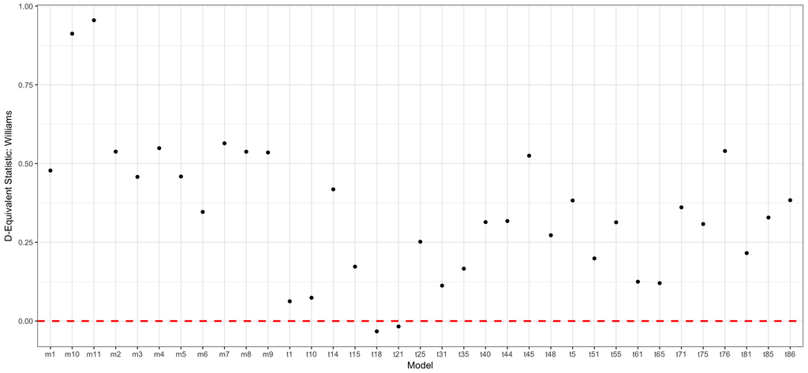

## Summaries Students

### Plot: Combined Effect Sizes by Candidate

[figure not shown]

### Table: Combined Effect Sizes by Variable

#### Detail

```
##    Variable      Mean
## 1        m1 33.216038
## 2        m2 34.583388
## 3        m3 24.133951
## 4        m4 23.461902
## 5        m5 47.971123
## 6        m6 34.109206
## 7        m7 58.175291
## 8        m8 55.483322
## 9        m9 44.868039
## 10      m10 42.608259
## 11      m11 44.383636
## 12       t1 16.126046
## 13       t5 39.436347
## 14      t10 16.120160
```

[output cut: 21 more lines]

### All Memory

```
## [1] 40.2722
```

### All Tally

```
## [1] 24.12781
```

# Only MTurkers Analyses

## Results: Smith Models

#### Table 1

|  | **Model 1** | **Model 2** | **Model 3** | **Model 4** | **Model 5** |  |
| --- | --- | --- | --- | --- | --- | --- |
| (Intercept) | 15.327** | 16.544*** | 16.928*** | 16.933*** | 19.737*** |  |
|  | (4.744) | (4.640) | (4.657) | (4.594) | (4.593) |  |
| Female | -3.682 | -4.075 | -4.026 | -4.187 | -2.676 |  |
|  | (2.331) | (2.276) | (2.278) | (2.252) | (2.219) |  |
| Age | -3.678 | -4.580 | -4.613 | -4.299 | -1.685 |  |
|  | (5.876) | (5.736) | (5.742) | (5.669) | (5.583) |  |
| YrsEduc | 3.546 | 3.466 | 3.157 | 3.449 | 4.203 |  |
|  | (5.619) | (5.479) | (5.485) | (5.419) | (5.325) |  |
| Black | -3.428 | -3.193 | -3.099 | -2.923 | -1.848 |  |
|  | (3.632) | (3.541) | (3.545) | (3.505) | (3.457) |  |
| LatinoLatino | 3.447 | 2.938 | 2.735 | 2.265 | 2.966 |  |
|  | (4.032) | (3.934) | (3.941) | (3.901) | (3.821) |  |
| PolSoph | -0.478 | -2.443 | -2.036 | -2.319 | -6.902 |  |
|  | (6.279) | (6.152) | (6.147) | (6.074) | (6.106) |  |
| LibCon | -37.619*** | -36.077*** | -35.991*** | -34.760*** | -27.868*** |  |
|  | (6.526) | (6.380) | (6.389) | (6.338) | (6.527) |  |
| PanelLength5 Weeks | -3.685 | -3.334 | -3.240 | -3.157 | -4.126 |  |
|  | (2.960) | (2.888) | (2.892) | (2.858) | (2.806) |  |
| DSmithMemAff5 |  | 29.930** |  |  |  |  |
|  |  | (9.275) |  |  |  |  |
| DSmithMemAff50 |  |  | 30.187** |  |  |  |
|  |  |  | (9.515) |  |  |  |
| DSmithIWMemAff5 |  |  |  | 29.625*** |  |  |
|  |  |  |  | (7.750) |  |  |
| DSmithAccRecogMemAff5 |  |  |  |  | 27.384*** |  |
|  |  |  |  |  | (5.880) |  |
| R<sup>2</sup> | 0.222 | 0.264 | 0.263 | 0.280 | 0.306 |  |
| Adj. R<sup>2</sup> | 0.188 | 0.228 | 0.226 | 0.244 | 0.271 |  |
| Num. obs. | 190 | 190 | 190 | 190 | 190 |  |
| RMSE | 15.542 | 15.152 | 15.166 | 14.988 | 14.723 |  |
| p < 0.001, p < 0.01, p < 0.05. All models, OLS. DV: Wk5DemSmithFTR |  |  |  |  |  |  |

#### Table 2

|  | **Model 1** | **Model 2** | **Model 3** | **Model 4** | **Model 5** | **Model 6** | **Model 7** | **Model 8** |  |
| --- | --- | --- | --- | --- | --- | --- | --- | --- | --- |
| (Intercept) | 7.189 | 10.721 | 11.491* | 9.033 | 9.455 | 9.772 | 12.877** | 13.109** |  |
|  | (5.640) | (5.531) | (5.508) | (5.310) | (5.379) | (5.225) | (4.943) | (4.962) |  |
| Female | -1.638 | -2.170 | -2.487 | -2.562 | -2.454 | -2.605 | -1.434 | -1.566 |  |
|  | (2.772) | (2.682) | (2.666) | (2.610) | (2.638) | (2.564) | (2.403) | (2.410) |  |
| Age | -0.008 | -1.102 | -1.203 | -0.782 | -0.604 | -0.297 | 6.171 | 5.977 |  |
|  | (6.987) | (6.756) | (6.705) | (6.564) | (6.636) | (6.448) | (6.108) | (6.122) |  |
| YrsEduc | 1.882 | 2.459 | 2.378 | 1.732 | 0.921 | 2.227 | 3.083 | 3.927 |  |
|  | (6.682) | (6.457) | (6.407) | (6.276) | (6.348) | (6.167) | (5.794) | (5.814) |  |
| Black | -1.531 | -1.554 | -1.479 | -1.339 | -1.069 | -1.004 | 0.229 | 0.278 |  |
|  | (4.318) | (4.172) | (4.140) | (4.056) | (4.102) | (3.986) | (3.750) | (3.761) |  |
| LatinoLatino | 1.681 | 1.235 | 0.789 | 0.670 | 0.294 | -0.817 | 2.766 | 2.572 |  |
|  | (4.794) | (4.633) | (4.601) | (4.507) | (4.563) | (4.446) | (4.158) | (4.169) |  |
| PolSoph | 10.600 | 10.381 | 10.659 | 5.793 | 6.635 | 5.538 | -4.648 | -4.860 |  |
|  | (7.465) | (7.213) | (7.157) | (7.077) | (7.142) | (6.947) | (6.760) | (6.791) |  |
| LibCon | -25.830** | -24.971** | -24.378** | -23.235** | -23.736** | -21.421** | -9.632 | -10.160 |  |
|  | (7.759) | (7.500) | (7.447) | (7.306) | (7.382) | (7.203) | (7.039) | (7.043) |  |
| PanelLength5 Weeks | 4.562 | 4.722 | 4.655 | 5.149 | 5.400 | 5.251 | 3.723 | 3.862 |  |
|  | (3.520) | (3.401) | (3.374) | (3.308) | (3.347) | (3.251) | (3.053) | (3.061) |  |
| DSmithDifAff |  | 44.203*** |  |  |  |  |  |  |  |
|  |  | (11.847) |  |  |  |  |  |  |  |
| DSmithIWDifAff |  |  | 41.937*** |  |  |  |  |  |  |
|  |  |  | (10.196) |  |  |  |  |  |  |
| DSmithMemAff |  |  |  | 51.651*** |  |  |  |  |  |
|  |  |  |  | (10.292) |  |  |  |  |  |
| DSmithMemAff0 |  |  |  |  | 48.626*** |  |  |  |  |
|  |  |  |  |  | (10.681) |  |  |  |  |
| DSmithIWMemAff |  |  |  |  |  | 48.718*** |  |  |  |
|  |  |  |  |  |  | (8.547) |  |  |  |
| DSmithAccRecogMemAff10 |  |  |  |  |  |  | 48.599*** |  |  |
|  |  |  |  |  |  |  | (6.228) |  |  |
| DSmithAccAccessedRecogMemAff |  |  |  |  |  |  |  | 47.773*** |  |
|  |  |  |  |  |  |  |  | (6.190) |  |
| R<sup>2</sup> | 0.113 | 0.176 | 0.189 | 0.222 | 0.204 | 0.248 | 0.337 | 0.333 |  |
| Adj. R<sup>2</sup> | 0.073 | 0.135 | 0.148 | 0.183 | 0.165 | 0.211 | 0.304 | 0.300 |  |
| Num. obs. | 190 | 190 | 190 | 190 | 190 | 190 | 190 | 190 |  |
| RMSE | 18.479 | 17.853 | 17.717 | 17.356 | 17.548 | 17.055 | 16.018 | 16.063 |  |
| p < 0.001, p < 0.01, p < 0.05. All models, OLS. DV: Wk10DemSmithFTR |  |  |  |  |  |  |  |  |  |

#### Table 3

|  | **Model 1** | **Model 2** | **Model 3** | **Model 4** | **Model 5** | **Model 6** | **Model 7** | **Model 8** | **Model 9** |  |
| --- | --- | --- | --- | --- | --- | --- | --- | --- | --- | --- |
| (Intercept) | 15.327** | 20.736*** | 19.456*** | 16.418*** | 14.907*** | 16.280*** | 19.366*** | 20.577*** | 20.241*** |  |
|  | (4.744) | (5.066) | (4.698) | (4.531) | (4.416) | (4.546) | (4.831) | (5.024) | (4.796) |  |
| Female | -3.682 | -3.361 | -3.180 | -3.391 | -2.934 | -3.376 | -3.185 | -2.994 | -2.869 |  |
|  | (2.331) | (2.294) | (2.251) | (2.224) | (2.174) | (2.233) | (2.287) | (2.302) | (2.270) |  |
| Age | -3.678 | -1.663 | -0.735 | -0.585 | 0.667 | -2.668 | -1.749 | -0.935 | -0.281 |  |
|  | (5.876) | (5.821) | (5.716) | (5.649) | (5.528) | (5.629) | (5.784) | (5.852) | (5.771) |  |
| YrsEduc | 3.546 | 2.921 | 2.494 | 1.909 | 1.894 | 3.703 | 4.231 | 2.859 | 2.964 |  |
|  | (5.619) | (5.527) | (5.424) | (5.372) | (5.239) | (5.378) | (5.503) | (5.523) | (5.447) |  |
| Black | -3.428 | -1.443 | -0.482 | -0.367 | 0.610 | -2.026 | -2.118 | -1.249 | -0.462 |  |
|  | (3.632) | (3.642) | (3.584) | (3.534) | (3.462) | (3.492) | (3.579) | (3.650) | (3.614) |  |
| LatinoLatino | 3.447 | 2.140 | 1.600 | 2.581 | 2.168 | 1.061 | 1.034 | 1.606 | 1.287 |  |
|  | (4.032) | (3.991) | (3.917) | (3.850) | (3.760) | (3.901) | (4.025) | (4.013) | (3.952) |  |
| PolSoph | -0.478 | -0.243 | -1.601 | -1.243 | -3.223 | 1.116 | -0.014 | -0.984 | -2.331 |  |
|  | (6.279) | (6.170) | (6.060) | (5.990) | (5.866) | (6.021) | (6.145) | (6.167) | (6.105) |  |
| LibCon | -37.619*** | -34.917*** | -30.824*** | -32.692*** | -27.308*** | -30.005*** | -32.926*** | -34.659*** | -31.639*** |  |
|  | (6.526) | (6.489) | (6.535) | (6.325) | (6.369) | (6.504) | (6.571) | (6.494) | (6.538) |  |
| PanelLength5 Weeks | -3.685 | -2.827 | -2.453 | -2.645 | -2.708 | -3.940 | -3.718 | -2.949 | -2.788 |  |
|  | (2.960) | (2.926) | (2.872) | (2.833) | (2.761) | (2.834) | (2.896) | (2.918) | (2.879) |  |
| DSmith25Cumu0 |  | 30.100** |  |  |  |  |  |  |  |  |
|  |  | (11.041) |  |  |  |  |  |  |  |  |
| DSmithWk5WeeklyTally0 |  |  | 57.458*** |  |  |  |  |  |  |  |
|  |  |  | (14.964) |  |  |  |  |  |  |  |
| DSmith25Cumu1 |  |  |  | 30.034*** |  |  |  |  |  |  |
|  |  |  |  | (6.890) |  |  |  |  |  |  |
| DSmithWk5WeeklyTally1 |  |  |  |  | 39.035*** |  |  |  |  |  |
|  |  |  |  |  | (7.256) |  |  |  |  |  |
| DSmithWk25WeeklyPBTally1 |  |  |  |  |  | 28.406*** |  |  |  |  |
|  |  |  |  |  |  | (6.772) |  |  |  |  |
| DSmithWk25WeeklyPBTally2 |  |  |  |  |  |  | 19.258** |  |  |  |
|  |  |  |  |  |  |  | (6.386) |  |  |  |
| DSmith25Cumu2 |  |  |  |  |  |  |  | 19.380** |  |  |
|  |  |  |  |  |  |  |  | (6.950) |  |  |
| DSmithWk5WeeklyTally2 |  |  |  |  |  |  |  |  | 31.793*** |  |
|  |  |  |  |  |  |  |  |  | (8.871) |  |
| R<sup>2</sup> | 0.222 | 0.253 | 0.281 | 0.296 | 0.330 | 0.291 | 0.259 | 0.254 | 0.274 |  |
| Adj. R<sup>2</sup> | 0.188 | 0.215 | 0.245 | 0.261 | 0.296 | 0.256 | 0.222 | 0.217 | 0.237 |  |
| Num. obs. | 190 | 190 | 190 | 190 | 190 | 190 | 190 | 190 | 190 |  |
| RMSE | 15.542 | 15.273 | 14.983 | 14.822 | 14.465 | 14.875 | 15.205 | 15.259 | 15.057 |  |
| p < 0.001, p < 0.01, p < 0.05. All models, OLS. DV: Wk5DemSmithFTR |  |  |  |  |  |  |  |  |  |  |

#### Table 4

|  | **Model 1** | **Model 2** | **Model 3** | **Model 4** | **Model 5** | **Model 6** | **Model 7** | **Model 8** | **Model 9** |  |
| --- | --- | --- | --- | --- | --- | --- | --- | --- | --- | --- |
| (Intercept) | 7.189 | 12.274* | 19.862** | 8.389 | 9.095 | 9.503 | 12.869* | 12.710* | 13.303* |  |
|  | (5.640) | (5.875) | (7.020) | (5.490) | (5.555) | (5.580) | (5.892) | (5.949) | (6.054) |  |
| Female | -1.638 | -1.458 | -1.612 | -1.579 | -1.650 | -1.643 | -1.154 | -1.095 | -1.428 |  |
|  | (2.772) | (2.728) | (2.716) | (2.693) | (2.712) | (2.715) | (2.726) | (2.737) | (2.732) |  |
| Age | -0.008 | 1.753 | 0.456 | 2.271 | 0.660 | 1.089 | 2.578 | 2.679 | 1.356 |  |
|  | (6.987) | (6.907) | (6.847) | (6.819) | (6.840) | (6.853) | (6.918) | (6.957) | (6.904) |  |
| YrsEduc | 1.882 | 1.772 | 1.903 | 0.447 | 0.627 | 1.839 | 2.459 | 1.268 | 1.605 |  |
|  | (6.682) | (6.575) | (6.546) | (6.504) | (6.551) | (6.544) | (6.561) | (6.583) | (6.584) |  |
| Black | -1.531 | 0.257 | 0.437 | 0.779 | 0.737 | -1.054 | -0.434 | 0.392 | 0.260 |  |
|  | (4.318) | (4.302) | (4.284) | (4.248) | (4.292) | (4.232) | (4.256) | (4.316) | (4.312) |  |
| LatinoLatino | 1.681 | 0.065 | 0.034 | 0.311 | -0.069 | 0.771 | -0.222 | -0.298 | -0.192 |  |
|  | (4.794) | (4.757) | (4.730) | (4.674) | (4.727) | (4.705) | (4.753) | (4.782) | (4.780) |  |
| PolSoph | 10.600 | 9.126 | 6.746 | 7.409 | 5.919 | 7.912 | 9.215 | 8.714 | 7.474 |  |
|  | (7.465) | (7.367) | (7.432) | (7.311) | (7.468) | (7.368) | (7.343) | (7.387) | (7.457) |  |
| LibCon | -25.830** | -22.470** | -19.811* | -21.192** | -19.473* | -19.061* | -20.350* | -22.558** | -20.805** |  |
|  | (7.759) | (7.740) | (7.875) | (7.657) | (7.880) | (7.938) | (7.860) | (7.744) | (7.895) |  |
| PanelLength5 Weeks | 4.562 | 5.415 | 4.580 | 5.639 | 4.798 | 4.472 | 4.808 | 5.388 | 4.931 |  |
|  | (3.520) | (3.478) | (3.448) | (3.433) | (3.445) | (3.447) | (3.455) | (3.480) | (3.471) |  |
| DSmith29Cumu0 |  | 26.141** |  |  |  |  |  |  |  |  |
|  |  | (9.913) |  |  |  |  |  |  |  |  |
| DSmithWk9WeeklyTally0 |  |  | 48.912** |  |  |  |  |  |  |  |
|  |  |  | (16.713) |  |  |  |  |  |  |  |
| DSmith29Cumu1 |  |  |  | 27.897*** |  |  |  |  |  |  |
|  |  |  |  | (8.116) |  |  |  |  |  |  |
| DSmithWk9WeeklyTally1 |  |  |  |  | 27.861** |  |  |  |  |  |
|  |  |  |  |  | (9.258) |  |  |  |  |  |
| DSmithWk29WeeklyPBTally1 |  |  |  |  |  | 20.751** |  |  |  |  |
|  |  |  |  |  |  | (7.037) |  |  |  |  |
| DSmithWk29WeeklyPBTally2 |  |  |  |  |  |  | 20.162** |  |  |  |
|  |  |  |  |  |  |  | (7.164) |  |  |  |
| DSmith29Cumu2 |  |  |  |  |  |  |  | 20.436* |  |  |
|  |  |  |  |  |  |  |  | (7.897) |  |  |
| DSmithWk9WeeklyTally2 |  |  |  |  |  |  |  |  | 22.254* |  |
|  |  |  |  |  |  |  |  |  | (8.743) |  |
| R<sup>2</sup> | 0.113 | 0.146 | 0.153 | 0.167 | 0.155 | 0.154 | 0.150 | 0.145 | 0.144 |  |
| Adj. R<sup>2</sup> | 0.073 | 0.103 | 0.111 | 0.126 | 0.113 | 0.111 | 0.108 | 0.102 | 0.101 |  |
| Num. obs. | 190 | 190 | 190 | 190 | 190 | 190 | 190 | 190 | 190 |  |
| RMSE | 18.479 | 18.183 | 18.105 | 17.951 | 18.081 | 18.099 | 18.136 | 18.195 | 18.206 |  |
| p < 0.001, p < 0.01, p < 0.05. All models, OLS. DV: Wk10DemSmithFTR |  |  |  |  |  |  |  |  |  |  |

#### Table 5

|  | **Model 1** | **Model 2** | **Model 3** | **Model 4** | **Model 5** | **Model 6** | **Model 7** | **Model 8** | **Model 9** |  |
| --- | --- | --- | --- | --- | --- | --- | --- | --- | --- | --- |
| (Intercept) | 7.189 | 15.446* | 23.750** | 11.406* | 14.035* | 14.124* | 14.734* | 15.782* | 15.176* |  |
|  | (5.640) | (6.153) | (7.150) | (5.537) | (5.754) | (6.072) | (6.111) | (6.186) | (6.229) |  |
| Female | -1.638 | -1.339 | -1.687 | -1.541 | -1.810 | -1.802 | -0.918 | -1.467 | -1.442 |  |
|  | (2.772) | (2.713) | (2.685) | (2.669) | (2.679) | (2.722) | (2.728) | (2.711) | (2.722) |  |
| Age | -0.008 | 2.440 | 0.655 | 3.358 | 1.103 | 1.931 | 3.581 | 1.818 | 2.629 |  |
|  | (6.987) | (6.881) | (6.770) | (6.782) | (6.759) | (6.895) | (6.959) | (6.856) | (6.923) |  |
| YrsEduc | 1.882 | 1.528 | 1.990 | 0.193 | 0.712 | 2.077 | 0.854 | 1.501 | 2.269 |  |
|  | (6.682) | (6.536) | (6.472) | (6.448) | (6.465) | (6.561) | (6.559) | (6.533) | (6.561) |  |
| Black | -1.531 | 0.203 | 0.661 | 0.520 | 1.047 | -1.519 | 0.296 | 0.403 | -1.030 |  |
|  | (4.318) | (4.262) | (4.227) | (4.191) | (4.230) | (4.240) | (4.279) | (4.268) | (4.243) |  |
| LatinoLatino | 1.681 | -0.295 | -0.460 | 0.145 | -0.734 | 1.085 | -0.490 | -0.582 | 0.324 |  |
|  | (4.794) | (4.734) | (4.682) | (4.632) | (4.678) | (4.712) | (4.758) | (4.744) | (4.731) |  |
| PolSoph | 10.600 | 9.328 | 6.619 | 7.534 | 5.713 | 6.353 | 8.694 | 7.174 | 7.938 |  |
|  | (7.465) | (7.314) | (7.316) | (7.231) | (7.334) | (7.487) | (7.347) | (7.383) | (7.390) |  |
| LibCon | -25.830** | -21.766** | -16.616* | -20.228** | -16.010* | -18.680* | -22.169** | -18.646* | -19.411* |  |
|  | (7.759) | (7.707) | (7.942) | (7.607) | (7.951) | (8.039) | (7.709) | (7.940) | (7.955) |  |
| PanelLength5 Weeks | 4.562 | 5.898 | 4.928 | 6.185 | 5.276 | 4.796 | 5.635 | 5.184 | 5.061 |  |
|  | (3.520) | (3.471) | (3.411) | (3.414) | (3.407) | (3.457) | (3.470) | (3.447) | (3.460) |  |
| DSmithMR29Cumu0 |  | 29.588** |  |  |  |  |  |  |  |  |
|  |  | (9.760) |  |  |  |  |  |  |  |  |
| DSmithWk9MRWeeklyTally0 |  |  | 53.945*** |  |  |  |  |  |  |  |
|  |  |  | (15.022) |  |  |  |  |  |  |  |
| DSmithMR29Cumu1 |  |  |  | 29.932*** |  |  |  |  |  |  |
|  |  |  |  | (7.665) |  |  |  |  |  |  |
| DSmithWk9MRWeeklyTally1 |  |  |  |  | 34.794*** |  |  |  |  |  |
|  |  |  |  |  | (9.369) |  |  |  |  |  |
| DSmithMR29PB1 |  |  |  |  |  | 22.396** |  |  |  |  |
|  |  |  |  |  |  | (8.040) |  |  |  |  |
| DSmithMR29Cumu2 |  |  |  |  |  |  | 23.163** |  |  |  |
|  |  |  |  |  |  |  | (7.993) |  |  |  |
| DSmithWk9MRWeeklyTally2 |  |  |  |  |  |  |  | 25.628** |  |  |
|  |  |  |  |  |  |  |  | (8.365) |  |  |
| DSmithMR29PB2 |  |  |  |  |  |  |  |  | 23.156** |  |
|  |  |  |  |  |  |  |  |  | (8.277) |  |
| R<sup>2</sup> | 0.113 | 0.156 | 0.172 | 0.182 | 0.176 | 0.149 | 0.152 | 0.157 | 0.150 |  |
| Adj. R<sup>2</sup> | 0.073 | 0.114 | 0.131 | 0.141 | 0.135 | 0.107 | 0.110 | 0.114 | 0.107 |  |
| Num. obs. | 190 | 190 | 190 | 190 | 190 | 190 | 190 | 190 | 190 |  |
| RMSE | 18.479 | 18.075 | 17.900 | 17.792 | 17.859 | 18.144 | 18.113 | 18.065 | 18.140 |  |
| p < 0.001, p < 0.01, p < 0.05. All models, OLS. DV: Wk10DemSmithFTR |  |  |  |  |  |  |  |  |  |  |

### Effect Sizes

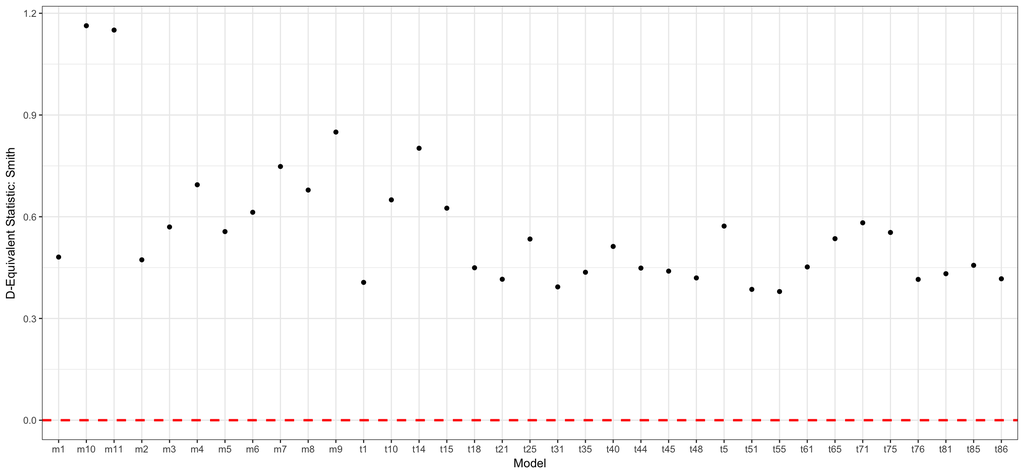

## Results: Wilson Models

#### Table 1

|  | **Model 1** | **Model 2** | **Model 3** | **Model 4** | **Model 5** |  |
| --- | --- | --- | --- | --- | --- | --- |
| (Intercept) | 15.527* | 14.751* | 13.988* | 13.215* | 15.737* |  |
|  | (6.299) | (6.214) | (6.284) | (6.290) | (6.088) |  |
| Female | -5.910 | -5.726 | -5.669 | -5.609 | -6.627* |  |
|  | (3.124) | (3.079) | (3.098) | (3.086) | (3.025) |  |
| Age | 6.889 | 6.990 | 6.596 | 6.785 | 9.614 |  |
|  | (7.875) | (7.760) | (7.804) | (7.772) | (7.646) |  |
| YrsEduc | 12.848 | 10.974 | 11.133 | 10.295 | 10.362 |  |
|  | (7.540) | (7.467) | (7.516) | (7.517) | (7.318) |  |
| Black | 0.823 | -0.350 | 0.004 | -0.297 | 3.100 |  |
|  | (4.871) | (4.822) | (4.843) | (4.830) | (4.747) |  |
| LatinoLatino | -6.620 | -6.701 | -6.687 | -6.581 | -3.107 |  |
|  | (5.280) | (5.203) | (5.232) | (5.211) | (5.189) |  |
| PolSoph | -4.230 | -1.923 | -2.287 | -2.111 | -3.444 |  |
|  | (8.427) | (8.353) | (8.401) | (8.363) | (8.147) |  |
| LibCon | 34.453*** | 33.355*** | 33.525*** | 33.127*** | 29.566*** |  |
|  | (8.754) | (8.637) | (8.685) | (8.657) | (8.562) |  |
| PanelLength5 Weeks | 3.467 | 4.329 | 4.237 | 4.077 | 3.520 |  |
|  | (3.955) | (3.912) | (3.936) | (3.911) | (3.822) |  |
| DWilsonMemAff5 |  | 38.126* |  |  |  |  |
|  |  | (15.030) |  |  |  |  |
| DWilsonMemAff50 |  |  | 31.356* |  |  |  |
|  |  |  | (14.982) |  |  |  |
| DWilsonIWMemAff5 |  |  |  | 30.049* |  |  |
|  |  |  |  | (12.432) |  |  |
| DWilsonAccRecogMemAff5 |  |  |  |  | 30.812*** |  |
|  |  |  |  |  | (8.277) |  |
| R<sup>2</sup> | 0.125 | 0.155 | 0.146 | 0.153 | 0.188 |  |
| Adj. R<sup>2</sup> | 0.087 | 0.113 | 0.104 | 0.111 | 0.147 |  |
| Num. obs. | 191 | 191 | 191 | 191 | 191 |  |
| RMSE | 20.863 | 20.558 | 20.671 | 20.590 | 20.163 |  |
| p < 0.001, p < 0.01, p < 0.05. All models, OLS. DV: Wk5DemWilsonFTR |  |  |  |  |  |  |

#### Table 2

|  | **Model 1** | **Model 2** | **Model 3** | **Model 4** | **Model 5** | **Model 6** | **Model 7** | **Model 8** |  |
| --- | --- | --- | --- | --- | --- | --- | --- | --- | --- |
| (Intercept) | 10.755 | 10.218 | 8.713 | 9.890 | 8.437 | 7.090 | 15.096* | 15.892** |  |
|  | (6.168) | (6.005) | (5.981) | (5.972) | (6.057) | (6.023) | (6.022) | (6.062) |  |
| Female | -2.719 | -2.150 | -1.890 | -2.614 | -2.508 | -2.266 | -3.040 | -2.845 |  |
|  | (3.059) | (2.982) | (2.963) | (2.960) | (2.984) | (2.952) | (2.940) | (2.939) |  |
| Age | 8.651 | 7.369 | 6.322 | 8.010 | 7.392 | 7.751 | 11.781 | 12.119 |  |
|  | (7.712) | (7.514) | (7.473) | (7.463) | (7.529) | (7.439) | (7.449) | (7.458) |  |
| YrsEduc | 4.710 | 3.603 | 1.995 | 1.533 | 1.274 | 0.493 | 0.246 | 0.183 |  |
|  | (7.384) | (7.194) | (7.167) | (7.196) | (7.278) | (7.204) | (7.180) | (7.183) |  |
| Black | -1.093 | -3.122 | -3.057 | -3.231 | -2.487 | -3.276 | 1.064 | 0.796 |  |
|  | (4.770) | (4.682) | (4.636) | (4.652) | (4.671) | (4.635) | (4.614) | (4.607) |  |
| LatinoLatino | -3.777 | -4.261 | -4.716 | -4.200 | -4.191 | -4.035 | -1.654 | -1.905 |  |
|  | (5.171) | (5.034) | (4.999) | (5.004) | (5.043) | (4.986) | (4.995) | (4.989) |  |
| PolSoph | -3.174 | 1.010 | 1.978 | -0.310 | -0.726 | 0.065 | -3.321 | -3.288 |  |
|  | (8.252) | (8.128) | (8.086) | (8.022) | (8.082) | (8.002) | (7.927) | (7.928) |  |
| LibCon | 24.470** | 23.589** | 23.598** | 22.877** | 23.209** | 22.128** | 20.030* | 20.501* |  |
|  | (8.573) | (8.347) | (8.282) | (8.305) | (8.368) | (8.288) | (8.309) | (8.295) |  |
| PanelLength5 Weeks | 5.035 | 5.920 | 5.706 | 5.927 | 6.198 | 5.944 | 4.697 | 4.503 |  |
|  | (3.873) | (3.778) | (3.744) | (3.755) | (3.793) | (3.742) | (3.721) | (3.723) |  |
| DWilsonDifAff |  | 53.122** |  |  |  |  |  |  |  |
|  |  | (15.884) |  |  |  |  |  |  |  |
| DWilsonIWDifAff |  |  | 50.450*** |  |  |  |  |  |  |
|  |  |  | (13.401) |  |  |  |  |  |  |
| DWilsonMemAff |  |  |  | 50.997*** |  |  |  |  |  |
|  |  |  |  | (13.907) |  |  |  |  |  |
| DWilsonMemAff0 |  |  |  |  | 44.659** |  |  |  |  |
|  |  |  |  |  | (13.819) |  |  |  |  |
| DWilsonIWMemAff |  |  |  |  |  | 44.632*** |  |  |  |
|  |  |  |  |  |  | (11.618) |  |  |  |
| DWilsonAccRecogMemAff10 |  |  |  |  |  |  | 34.451*** |  |  |
|  |  |  |  |  |  |  | (8.553) |  |  |
| DWilsonAccAccessedRecogMemAff |  |  |  |  |  |  |  | 34.819*** |  |
|  |  |  |  |  |  |  |  | (8.650) |  |
| R<sup>2</sup> | 0.077 | 0.131 | 0.144 | 0.141 | 0.127 | 0.147 | 0.153 | 0.153 |  |
| Adj. R<sup>2</sup> | 0.036 | 0.087 | 0.101 | 0.098 | 0.084 | 0.104 | 0.111 | 0.111 |  |
| Num. obs. | 191 | 191 | 191 | 191 | 191 | 191 | 191 | 191 |  |
| RMSE | 20.430 | 19.882 | 19.729 | 19.766 | 19.920 | 19.699 | 19.626 | 19.627 |  |
| p < 0.001, p < 0.01, p < 0.05. All models, OLS. DV: Wk10DemWilsonFTR |  |  |  |  |  |  |  |  |  |

#### Table 3

|  | **Model 1** | **Model 2** | **Model 3** | **Model 4** | **Model 5** | **Model 6** | **Model 7** | **Model 8** | **Model 9** |  |
| --- | --- | --- | --- | --- | --- | --- | --- | --- | --- | --- |
| (Intercept) | 15.527* | 22.289** | 18.421** | 16.566** | 16.458** | 13.728* | 16.119* | 20.853** | 18.399** |  |
|  | (6.299) | (6.734) | (6.379) | (6.298) | (6.297) | (6.328) | (6.235) | (6.689) | (6.415) |  |
| Female | -5.910 | -5.757 | -5.482 | -6.083 | -5.673 | -6.288* | -6.209* | -5.709 | -5.600 |  |
|  | (3.124) | (3.077) | (3.100) | (3.110) | (3.114) | (3.109) | (3.093) | (3.093) | (3.103) |  |
| Age | 6.889 | 10.885 | 9.408 | 9.359 | 8.505 | 9.541 | 9.754 | 10.429 | 8.888 |  |
|  | (7.875) | (7.909) | (7.884) | (7.972) | (7.903) | (7.947) | (7.891) | (7.958) | (7.877) |  |
| YrsEduc | 12.848 | 12.571 | 12.521 | 12.496 | 12.741 | 11.677 | 11.945 | 13.054 | 12.971 |  |
|  | (7.540) | (7.427) | (7.467) | (7.506) | (7.507) | (7.514) | (7.468) | (7.463) | (7.481) |  |
| Black | 0.823 | 1.735 | 1.593 | 1.019 | 1.213 | 0.057 | 0.857 | 1.773 | 1.688 |  |
|  | (4.871) | (4.810) | (4.836) | (4.848) | (4.856) | (4.855) | (4.818) | (4.840) | (4.852) |  |
| LatinoLatino | -6.620 | -7.306 | -7.033 | -6.674 | -6.636 | -6.128 | -6.789 | -7.926 | -7.575 |  |
|  | (5.280) | (5.207) | (5.231) | (5.254) | (5.256) | (5.250) | (5.222) | (5.259) | (5.260) |  |
| PolSoph | -4.230 | -4.283 | -4.324 | -4.206 | -4.059 | -3.152 | -2.582 | -3.843 | -3.345 |  |
|  | (8.427) | (8.299) | (8.344) | (8.385) | (8.390) | (8.389) | (8.366) | (8.342) | (8.372) |  |
| LibCon | 34.453*** | 33.619*** | 32.264*** | 33.415*** | 32.105*** | 28.486** | 28.494** | 34.483*** | 32.412*** |  |
|  | (8.754) | (8.627) | (8.727) | (8.732) | (8.834) | (9.256) | (9.052) | (8.664) | (8.746) |  |
| PanelLength5 Weeks | 3.467 | 3.732 | 3.839 | 3.326 | 3.583 | 3.203 | 3.200 | 3.929 | 3.816 |  |
|  | (3.955) | (3.896) | (3.920) | (3.936) | (3.938) | (3.930) | (3.913) | (3.920) | (3.927) |  |
| DWilson25Cumu0 |  | 29.695* |  |  |  |  |  |  |  |  |
|  |  | (11.514) |  |  |  |  |  |  |  |  |
| DWilsonWk5WeeklyTally0 |  |  | 27.860* |  |  |  |  |  |  |  |
|  |  |  | (12.916) |  |  |  |  |  |  |  |
| DWilson25Cumu1 |  |  |  | 14.489 |  |  |  |  |  |  |
|  |  |  |  | (8.621) |  |  |  |  |  |  |
| DWilsonWk5WeeklyTally1 |  |  |  |  | 15.463 |  |  |  |  |  |
|  |  |  |  |  | (9.522) |  |  |  |  |  |
| DWilsonWk25WeeklyPBTally1 |  |  |  |  |  | 19.381 |  |  |  |  |
|  |  |  |  |  |  | (10.314) |  |  |  |  |
| DWilsonWk25WeeklyPBTally2 |  |  |  |  |  |  | 25.089* |  |  |  |
|  |  |  |  |  |  |  | (11.130) |  |  |  |
| DWilson25Cumu2 |  |  |  |  |  |  |  | 22.169* |  |  |
|  |  |  |  |  |  |  |  | (10.093) |  |  |
| DWilsonWk5WeeklyTally2 |  |  |  |  |  |  |  |  | 21.489* |  |
|  |  |  |  |  |  |  |  |  | (10.856) |  |
| R<sup>2</sup> | 0.125 | 0.156 | 0.147 | 0.139 | 0.138 | 0.142 | 0.149 | 0.148 | 0.144 |  |
| Adj. R<sup>2</sup> | 0.087 | 0.114 | 0.105 | 0.096 | 0.095 | 0.099 | 0.107 | 0.106 | 0.101 |  |
| Num. obs. | 191 | 191 | 191 | 191 | 191 | 191 | 191 | 191 | 191 |  |
| RMSE | 20.863 | 20.546 | 20.656 | 20.759 | 20.769 | 20.719 | 20.632 | 20.647 | 20.697 |  |
| p < 0.001, p < 0.01, p < 0.05. All models, OLS. DV: Wk5DemWilsonFTR |  |  |  |  |  |  |  |  |  |  |

##### Table 4

|  | **Model 1** | **Model 2** | **Model 3** | **Model 4** | **Model 5** | **Model 6** | **Model 7** | **Model 8** | **Model 9** |  |
| --- | --- | --- | --- | --- | --- | --- | --- | --- | --- | --- |
| (Intercept) | 10.755 | 11.805 | 9.982 | 10.606 | 10.431 | 10.100 | 11.854 | 11.224 | 10.746 |  |
|  | (6.168) | (6.503) | (8.440) | (6.247) | (6.242) | (6.191) | (6.302) | (6.640) | (6.576) |  |
| Female | -2.719 | -2.661 | -2.728 | -2.708 | -2.684 | -2.766 | -2.665 | -2.693 | -2.719 |  |
|  | (3.059) | (3.068) | (3.068) | (3.068) | (3.068) | (3.057) | (3.062) | (3.071) | (3.068) |  |
| Age | 8.651 | 9.213 | 8.607 | 8.466 | 8.441 | 10.340 | 9.685 | 8.920 | 8.648 |  |
|  | (7.712) | (7.803) | (7.739) | (7.809) | (7.750) | (7.851) | (7.809) | (7.856) | (7.776) |  |
| YrsEduc | 4.710 | 4.618 | 4.742 | 4.769 | 4.893 | 4.083 | 4.438 | 4.697 | 4.711 |  |
|  | (7.384) | (7.401) | (7.408) | (7.412) | (7.418) | (7.400) | (7.396) | (7.404) | (7.411) |  |
| Black | -1.093 | -1.033 | -1.098 | -1.090 | -1.139 | -1.524 | -1.258 | -1.041 | -1.094 |  |
|  | (4.770) | (4.781) | (4.784) | (4.783) | (4.783) | (4.782) | (4.778) | (4.791) | (4.790) |  |
| LatinoLatino | -3.777 | -3.812 | -3.823 | -3.814 | -4.016 | -2.951 | -3.416 | -3.851 | -3.778 |  |
|  | (5.171) | (5.182) | (5.196) | (5.189) | (5.222) | (5.219) | (5.191) | (5.198) | (5.187) |  |
| PolSoph | -3.174 | -3.228 | -3.194 | -3.131 | -3.101 | -2.581 | -2.602 | -3.182 | -3.173 |  |
|  | (8.252) | (8.270) | (8.276) | (8.278) | (8.274) | (8.263) | (8.284) | (8.274) | (8.275) |  |
| LibCon | 24.470** | 24.359** | 24.585** | 24.540** | 24.868** | 21.162* | 22.433* | 24.482** | 24.472** |  |
|  | (8.573) | (8.593) | (8.638) | (8.606) | (8.658) | (9.057) | (8.896) | (8.596) | (8.614) |  |
| PanelLength5 Weeks | 5.035 | 5.018 | 5.046 | 5.059 | 5.070 | 5.004 | 5.012 | 5.034 | 5.036 |  |
|  | (3.873) | (3.881) | (3.884) | (3.886) | (3.883) | (3.870) | (3.876) | (3.883) | (3.885) |  |
| DWilson29Cumu0 |  | 5.081 |  |  |  |  |  |  |  |  |
|  |  | (9.788) |  |  |  |  |  |  |  |  |
| DWilsonWk9WeeklyTally0 |  |  | -3.210 |  |  |  |  |  |  |  |
|  |  |  | (23.847) |  |  |  |  |  |  |  |
| DWilson29Cumu1 |  |  |  | -1.494 |  |  |  |  |  |  |
|  |  |  |  | (8.817) |  |  |  |  |  |  |
| DWilsonWk9WeeklyTally1 |  |  |  |  | -4.160 |  |  |  |  |  |
|  |  |  |  |  | (11.032) |  |  |  |  |  |
| DWilsonWk29WeeklyPBTally1 |  |  |  |  |  | 11.174 |  |  |  |  |
|  |  |  |  |  |  | (9.929) |  |  |  |  |
| DWilsonWk29WeeklyPBTally2 |  |  |  |  |  |  | 11.103 |  |  |  |
|  |  |  |  |  |  |  | (12.838) |  |  |  |
| DWilson29Cumu2 |  |  |  |  |  |  |  | 1.888 |  |  |
|  |  |  |  |  |  |  |  | (9.722) |  |  |
| DWilsonWk9WeeklyTally2 |  |  |  |  |  |  |  |  | -0.054 |  |
|  |  |  |  |  |  |  |  |  | (14.091) |  |
| R<sup>2</sup> | 0.077 | 0.078 | 0.077 | 0.077 | 0.078 | 0.083 | 0.081 | 0.077 | 0.077 |  |
| Adj. R<sup>2</sup> | 0.036 | 0.032 | 0.031 | 0.031 | 0.032 | 0.038 | 0.035 | 0.031 | 0.031 |  |
| Num. obs. | 191 | 191 | 191 | 191 | 191 | 191 | 191 | 191 | 191 |  |
| RMSE | 20.430 | 20.471 | 20.486 | 20.485 | 20.479 | 20.415 | 20.445 | 20.485 | 20.487 |  |
| p < 0.001, p < 0.01, p < 0.05. All models, OLS. DV: Wk10DemWilsonFTR |  |  |  |  |  |  |  |  |  |  |

#### Table 5

|  | **Model 1** | **Model 2** | **Model 3** | **Model 4** | **Model 5** | **Model 6** | **Model 7** | **Model 8** | **Model 9** |  |
| --- | --- | --- | --- | --- | --- | --- | --- | --- | --- | --- |
| (Intercept) | 10.755 | 13.111* | 17.712* | 11.556 | 12.710* | 11.580 | 12.172 | 14.014* | 14.110 |  |
|  | (6.168) | (6.421) | (7.537) | (6.277) | (6.248) | (6.243) | (6.675) | (6.628) | (7.287) |  |
| Female | -2.719 | -2.633 | -2.632 | -2.787 | -2.751 | -2.711 | -2.641 | -2.660 | -2.587 |  |
|  | (3.059) | (3.055) | (3.047) | (3.065) | (3.044) | (3.061) | (3.068) | (3.053) | (3.065) |  |
| Age | 8.651 | 10.254 | 9.228 | 9.517 | 9.593 | 9.938 | 9.491 | 9.842 | 9.522 |  |
|  | (7.712) | (7.797) | (7.688) | (7.816) | (7.694) | (7.853) | (7.870) | (7.748) | (7.782) |  |
| YrsEduc | 4.710 | 4.407 | 3.805 | 4.472 | 3.635 | 4.446 | 4.696 | 4.107 | 4.720 |  |
|  | (7.384) | (7.374) | (7.375) | (7.402) | (7.376) | (7.395) | (7.398) | (7.383) | (7.389) |  |
| Black | -1.093 | -1.038 | -1.106 | -1.198 | -1.024 | -1.312 | -0.990 | -0.876 | -1.309 |  |
|  | (4.770) | (4.762) | (4.750) | (4.779) | (4.747) | (4.780) | (4.783) | (4.763) | (4.780) |  |
| LatinoLatino | -3.777 | -3.847 | -2.988 | -3.632 | -2.572 | -3.365 | -3.994 | -3.463 | -3.697 |  |
|  | (5.171) | (5.161) | (5.173) | (5.182) | (5.195) | (5.195) | (5.195) | (5.165) | (5.175) |  |
| PolSoph | -3.174 | -3.374 | -3.590 | -3.308 | -3.975 | -2.987 | -3.172 | -3.554 | -2.879 |  |
|  | (8.252) | (8.239) | (8.222) | (8.265) | (8.226) | (8.260) | (8.268) | (8.240) | (8.265) |  |
| LibCon | 24.470** | 23.539** | 21.653* | 23.742** | 21.082* | 22.296* | 24.253** | 22.744** | 22.847* |  |
|  | (8.573) | (8.587) | (8.718) | (8.644) | (8.767) | (8.926) | (8.598) | (8.653) | (8.781) |  |
| PanelLength5 Weeks | 5.035 | 4.931 | 4.674 | 4.899 | 4.722 | 4.968 | 5.017 | 4.789 | 4.921 |  |
|  | (3.873) | (3.867) | (3.863) | (3.883) | (3.858) | (3.876) | (3.880) | (3.869) | (3.878) |  |
| DWilsonMR29Cumu0 |  | 13.576 |  |  |  |  |  |  |  |  |
|  |  | (10.501) |  |  |  |  |  |  |  |  |
| DWilsonWk9MRWeeklyTally0 |  |  | 37.324 |  |  |  |  |  |  |  |
|  |  |  | (23.435) |  |  |  |  |  |  |  |
| DWilsonMR29Cumu1 |  |  |  | 7.166 |  |  |  |  |  |  |
|  |  |  |  | (9.985) |  |  |  |  |  |  |
| DWilsonWk9MRWeeklyTally1 |  |  |  |  | 20.111 |  |  |  |  |  |
|  |  |  |  |  | (12.001) |  |  |  |  |  |
| DWilsonMR29PB1 |  |  |  |  |  | 10.830 |  |  |  |  |
|  |  |  |  |  |  | (12.292) |  |  |  |  |
| DWilsonMR29Cumu2 |  |  |  |  |  |  | 6.719 |  |  |  |
|  |  |  |  |  |  |  | (11.958) |  |  |  |
| DWilsonWk9MRWeeklyTally2 |  |  |  |  |  |  |  | 21.349 |  |  |
|  |  |  |  |  |  |  |  | (16.097) |  |  |
| DWilsonMR29PB2 |  |  |  |  |  |  |  |  | 12.779 |  |
|  |  |  |  |  |  |  |  |  | (14.749) |  |
| R<sup>2</sup> | 0.077 | 0.085 | 0.090 | 0.080 | 0.091 | 0.081 | 0.079 | 0.086 | 0.081 |  |
| Adj. R<sup>2</sup> | 0.036 | 0.040 | 0.044 | 0.034 | 0.046 | 0.035 | 0.033 | 0.040 | 0.035 |  |
| Num. obs. | 191 | 191 | 191 | 191 | 191 | 191 | 191 | 191 | 191 |  |
| RMSE | 20.430 | 20.393 | 20.345 | 20.458 | 20.330 | 20.443 | 20.469 | 20.388 | 20.444 |  |
| p < 0.001, p < 0.01, p < 0.05. All models, OLS. DV: Wk10DemWilsonFTR |  |  |  |  |  |  |  |  |  |  |

### Effect Sizes

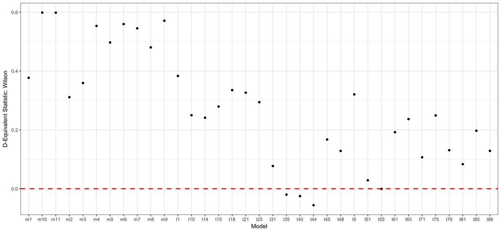

## Results: Jones Models

#### Table 1

|  | **Model 1** | **Model 2** | **Model 3** | **Model 4** | **Model 5** |  |
| --- | --- | --- | --- | --- | --- | --- |
| (Intercept) | -8.184 | -7.702 | -8.322 | -8.443 | -3.761 |  |
|  | (11.788) | (10.781) | (10.729) | (10.444) | (10.879) |  |
| Female | 4.218 | 4.298 | 4.192 | 6.063 | 4.406 |  |
|  | (6.172) | (5.644) | (5.618) | (5.487) | (5.657) |  |
| Age | -7.160 | -7.050 | -7.178 | -9.829 | -3.054 |  |
|  | (16.274) | (14.882) | (14.812) | (14.433) | (14.962) |  |
| YrsEduc | 5.066 | 7.771 | 7.446 | 2.485 | 4.182 |  |
|  | (12.231) | (11.211) | (11.152) | (10.854) | (11.213) |  |
| Black | -8.720 | -3.020 | -2.857 | -1.463 | -0.134 |  |
|  | (15.841) | (14.576) | (14.509) | (14.145) | (14.728) |  |
| LatinoLatino | 16.945 | 10.319 | 10.115 | 9.832 | 12.123 |  |
|  | (11.616) | (10.788) | (10.741) | (10.436) | (10.737) |  |
| PolSoph | 30.606 | 40.975** | 41.093** | 45.424** | 27.647 |  |
|  | (16.399) | (15.283) | (15.206) | (14.969) | (15.054) |  |
| LibCon | 42.889* | 36.103* | 37.918* | 33.661* | 8.712 |  |
|  | (18.395) | (16.931) | (16.799) | (16.451) | (19.525) |  |
| PanelLength5 Weeks | -17.500 | -14.358 | -13.791 | -11.819 | -9.841 |  |
|  | (11.762) | (10.793) | (10.755) | (10.512) | (11.004) |  |
| RJonesMemAff5 |  | 66.396*** |  |  |  |  |
|  |  | (18.885) |  |  |  |  |
| RJonesMemAff50 |  |  | 65.384*** |  |  |  |
|  |  |  | (18.125) |  |  |  |
| RJonesIWMemAff5 |  |  |  | 67.919*** |  |  |
|  |  |  |  | (16.526) |  |  |
| RJonesAccRecogMemAff5 |  |  |  |  | 58.728*** |  |
|  |  |  |  |  | (16.921) |  |
| R<sup>2</sup> | 0.231 | 0.368 | 0.374 | 0.407 | 0.365 |  |
| Adj. R<sup>2</sup> | 0.125 | 0.268 | 0.275 | 0.313 | 0.265 |  |
| Num. obs. | 67 | 67 | 67 | 67 | 67 |  |
| RMSE | 24.134 | 22.069 | 21.966 | 21.382 | 22.120 |  |
| p < 0.001, p < 0.01, p < 0.05. All models, OLS. DV: Wk5RepJonesFTR |  |  |  |  |  |  |

#### Table 2

|  | **Model 1** | **Model 2** | **Model 3** | **Model 4** | **Model 5** | **Model 6** | **Model 7** | **Model 8** |  |
| --- | --- | --- | --- | --- | --- | --- | --- | --- | --- |
| (Intercept) | -12.412 | -11.578 | -10.763 | -13.612 | -15.308 | -15.031 | -11.942 | -11.821 |  |
|  | (11.371) | (10.305) | (9.994) | (10.121) | (10.101) | (9.729) | (9.717) | (9.731) |  |
| Female | 2.797 | 2.722 | 4.570 | 2.651 | 2.432 | 4.077 | 3.941 | 3.758 |  |
|  | (5.954) | (5.394) | (5.246) | (5.297) | (5.276) | (5.093) | (5.093) | (5.099) |  |
| Age | -12.868 | -13.183 | -16.457 | -14.704 | -15.023 | -16.820 | -14.309 | -12.318 |  |
|  | (15.697) | (14.222) | (13.813) | (13.973) | (13.920) | (13.435) | (13.417) | (13.433) |  |
| YrsEduc | -11.093 | -9.181 | -13.357 | -5.496 | -5.547 | -10.506 | -7.517 | -8.042 |  |
|  | (11.798) | (10.701) | (10.375) | (10.587) | (10.541) | (10.078) | (10.109) | (10.116) |  |
| Black | 8.356 | 12.338 | 13.610 | 15.251 | 15.346 | 16.934 | 22.727 | 22.567 |  |
|  | (15.280) | (13.886) | (13.477) | (13.701) | (13.647) | (13.177) | (13.405) | (13.418) |  |
| LatinoLatino | 17.687 | 13.524 | 14.127 | 11.093 | 10.936 | 10.722 | 9.577 | 9.516 |  |
|  | (11.204) | (10.214) | (9.876) | (10.101) | (10.064) | (9.683) | (9.726) | (9.743) |  |
| PolSoph | 18.312 | 27.992 | 33.272* | 27.610 | 26.998 | 31.063* | 15.676 | 13.136 |  |
|  | (15.818) | (14.569) | (14.329) | (14.260) | (14.176) | (13.777) | (13.528) | (13.580) |  |
| LibCon | 47.433** | 52.224** | 50.030** | 40.952* | 43.116** | 39.700* | 14.908 | 18.749 |  |
|  | (17.743) | (16.128) | (15.596) | (15.867) | (15.758) | (15.244) | (16.644) | (16.357) |  |
| PanelLength5 Weeks | -11.800 | -11.603 | -11.583 | -8.283 | -7.945 | -5.831 | -0.995 | -1.983 |  |
|  | (11.346) | (10.279) | (9.965) | (10.131) | (10.098) | (9.773) | (9.959) | (9.929) |  |
| RJonesDifAff |  | 72.124*** |  |  |  |  |  |  |  |
|  |  | (19.516) |  |  |  |  |  |  |  |
| RJonesIWDifAff |  |  | 76.795*** |  |  |  |  |  |  |
|  |  |  | (18.007) |  |  |  |  |  |  |
| RJonesMemAff |  |  |  | 64.315*** |  |  |  |  |  |
|  |  |  |  | (15.942) |  |  |  |  |  |
| RJonesMemAff0 |  |  |  |  | 69.312*** |  |  |  |  |
|  |  |  |  |  | (16.879) |  |  |  |  |
| RJonesIWMemAff |  |  |  |  |  | 68.232*** |  |  |  |
|  |  |  |  |  |  | (14.389) |  |  |  |
| RJonesAccRecogMemAff10 |  |  |  |  |  |  | 60.255*** |  |  |
|  |  |  |  |  |  |  | (12.721) |  |  |
| RJonesAccAccessedRecogMemAff |  |  |  |  |  |  |  | 59.721*** |  |
|  |  |  |  |  |  |  |  | (12.671) |  |
| R<sup>2</sup> | 0.199 | 0.354 | 0.393 | 0.377 | 0.382 | 0.426 | 0.425 | 0.424 |  |
| Adj. R<sup>2</sup> | 0.089 | 0.252 | 0.297 | 0.279 | 0.284 | 0.335 | 0.335 | 0.333 |  |
| Num. obs. | 67 | 67 | 67 | 67 | 67 | 67 | 67 | 67 |  |
| RMSE | 23.280 | 21.091 | 20.446 | 20.711 | 20.629 | 19.886 | 19.892 | 19.920 |  |
| p < 0.001, p < 0.01, p < 0.05. All models, OLS. DV: Wk10RepJonesFTR |  |  |  |  |  |  |  |  |  |

#### Table 3

|  | **Model 1** | **Model 2** | **Model 3** | **Model 4** | **Model 5** | **Model 6** | **Model 7** | **Model 8** | **Model 9** |  |
| --- | --- | --- | --- | --- | --- | --- | --- | --- | --- | --- |
| (Intercept) | -8.184 | -7.551 | -4.865 | -8.354 | -4.624 | -9.789 | -7.916 | -8.329 | -7.839 |  |
|  | (11.788) | (11.923) | (11.367) | (11.656) | (10.756) | (11.699) | (11.720) | (11.830) | (11.151) |  |
| Female | 4.218 | 4.172 | 1.718 | 4.019 | 1.124 | 3.941 | 3.855 | 4.110 | 1.589 |  |
|  | (6.172) | (6.212) | (5.995) | (6.104) | (5.673) | (6.104) | (6.142) | (6.195) | (5.914) |  |
| Age | -7.160 | -7.552 | -6.825 | -7.956 | -5.639 | -15.083 | -12.804 | -7.544 | -7.368 |  |
|  | (16.274) | (16.393) | (15.586) | (16.099) | (14.793) | (16.893) | (16.747) | (16.336) | (15.394) |  |
| YrsEduc | 5.066 | 6.065 | 8.219 | 7.321 | 7.570 | 4.588 | 5.090 | 6.153 | 7.271 |  |
|  | (12.231) | (12.452) | (11.781) | (12.183) | (11.135) | (12.094) | (12.158) | (12.351) | (11.596) |  |
| Black | -8.720 | -8.011 | -3.082 | -4.385 | 1.481 | -8.653 | -5.809 | -6.605 | -1.312 |  |
|  | (15.841) | (15.997) | (15.338) | (15.918) | (14.665) | (15.659) | (15.905) | (16.125) | (15.217) |  |
| LatinoLatino | 16.945 | 16.716 | 13.190 | 15.693 | 11.840 | 15.557 | 16.726 | 16.821 | 13.840 |  |
|  | (11.616) | (11.697) | (11.225) | (11.514) | (10.648) | (11.517) | (11.548) | (11.656) | (11.043) |  |
| PolSoph | 30.606 | 30.390 | 26.813 | 30.686 | 28.242 | 36.594* | 32.452 | 30.347 | 28.600 |  |
|  | (16.399) | (16.507) | (15.778) | (16.214) | (14.915) | (16.672) | (16.363) | (16.458) | (15.528) |  |
| LibCon | 42.889* | 39.662* | 28.383 | 30.997 | 15.871 | 28.482 | 33.525 | 38.678* | 25.997 |  |
|  | (18.395) | (19.493) | (18.549) | (19.787) | (18.289) | (20.459) | (19.648) | (19.231) | (18.418) |  |
| PanelLength5 Weeks | -17.500 | -16.347 | -10.333 | -13.494 | -6.636 | -13.873 | -13.848 | -15.400 | -9.130 |  |
|  | (11.762) | (12.035) | (11.624) | (11.922) | (11.097) | (11.864) | (12.024) | (12.105) | (11.521) |  |
| RJones25Cumu0 |  | 9.211 |  |  |  |  |  |  |  |  |
|  |  | (17.438) |  |  |  |  |  |  |  |  |
| RJonesWk5WeeklyTally0 |  |  | 42.074* |  |  |  |  |  |  |  |
|  |  |  | (16.843) |  |  |  |  |  |  |  |
| RJones25Cumu1 |  |  |  | 27.666 |  |  |  |  |  |  |
|  |  |  |  | (18.130) |  |  |  |  |  |  |
| RJonesWk5WeeklyTally1 |  |  |  |  | 53.153*** |  |  |  |  |  |
|  |  |  |  |  | (14.604) |  |  |  |  |  |
| RJonesWk25WeeklyPBTally1 |  |  |  |  |  | 32.096 |  |  |  |  |
|  |  |  |  |  |  | (20.893) |  |  |  |  |
| RJonesWk25WeeklyPBTally2 |  |  |  |  |  |  | 31.277 |  |  |  |
|  |  |  |  |  |  |  | (24.012) |  |  |  |
| RJones25Cumu2 |  |  |  |  |  |  |  | 13.988 |  |  |
|  |  |  |  |  |  |  |  | (17.936) |  |  |
| RJonesWk5WeeklyTally2 |  |  |  |  |  |  |  |  | 42.626** |  |
|  |  |  |  |  |  |  |  |  | (15.240) |  |
| R<sup>2</sup> | 0.231 | 0.235 | 0.307 | 0.261 | 0.376 | 0.262 | 0.253 | 0.239 | 0.324 |  |
| Adj. R<sup>2</sup> | 0.125 | 0.114 | 0.197 | 0.145 | 0.277 | 0.145 | 0.135 | 0.119 | 0.217 |  |
| Num. obs. | 67 | 67 | 67 | 67 | 67 | 67 | 67 | 67 | 67 |  |
| RMSE | 24.134 | 24.286 | 23.113 | 23.862 | 21.930 | 23.856 | 23.991 | 24.216 | 22.829 |  |
| p < 0.001, p < 0.01, p < 0.05. All models, OLS. DV: Wk5RepJonesFTR |  |  |  |  |  |  |  |  |  |  |

#### Table 4

|  | **Model 1** | **Model 2** | **Model 3** | **Model 4** | **Model 5** | **Model 6** | **Model 7** | **Model 8** | **Model 9** |  |
| --- | --- | --- | --- | --- | --- | --- | --- | --- | --- | --- |
| (Intercept) | -12.412 | -11.812 | 0.279 | -15.730 | -11.933 | -14.037 | -16.565 | -17.793 | -11.293 |  |
|  | (11.371) | (10.893) | (10.183) | (10.703) | (9.696) | (11.068) | (11.342) | (10.953) | (9.998) |  |
| Female | 2.797 | 1.997 | -2.115 | 2.177 | -1.201 | 2.102 | 2.944 | 2.125 | -1.602 |  |
|  | (5.954) | (5.711) | (5.242) | (5.578) | (5.145) | (5.790) | (5.827) | (5.648) | (5.335) |  |
| Age | -12.868 | -13.822 | -12.794 | -13.553 | -12.350 | -20.450 | -17.888 | -13.500 | -13.734 |  |
|  | (15.697) | (15.040) | (13.530) | (14.699) | (13.386) | (15.655) | (15.590) | (14.880) | (13.799) |  |
| YrsEduc | -11.093 | -5.683 | -2.454 | -5.327 | -2.545 | -10.024 | -10.041 | -5.478 | -2.143 |  |
|  | (11.798) | (11.506) | (10.341) | (11.209) | (10.218) | (11.467) | (11.558) | (11.366) | (10.582) |  |
| Black | 8.356 | 12.975 | 18.872 | 16.834 | 19.583 | 8.784 | 12.263 | 16.488 | 20.362 |  |
|  | (15.280) | (14.752) | (13.368) | (14.579) | (13.240) | (14.839) | (15.095) | (14.781) | (13.725) |  |
| LatinoLatino | 17.687 | 17.404 | 11.038 | 15.817 | 10.015 | 14.536 | 15.489 | 17.757 | 12.113 |  |
|  | (11.204) | (10.732) | (9.765) | (10.509) | (9.688) | (10.980) | (11.026) | (10.619) | (9.935) |  |
| PolSoph | 18.312 | 19.659 | 21.008 | 20.232 | 21.033 | 23.427 | 21.001 | 18.205 | 18.951 |  |
|  | (15.818) | (15.160) | (13.647) | (14.824) | (13.500) | (15.547) | (15.545) | (14.992) | (13.905) |  |
| LibCon | 47.433** | 30.777 | 21.258 | 25.053 | 17.554 | 26.970 | 34.952 | 35.073* | 30.030 |  |
|  | (17.743) | (18.259) | (16.322) | (18.184) | (16.374) | (19.738) | (18.578) | (17.407) | (16.125) |  |
| PanelLength5 Weeks | -11.800 | -6.291 | -1.510 | -4.815 | -1.845 | -6.848 | -5.599 | -5.585 | -2.619 |  |
|  | (11.346) | (11.089) | (10.033) | (10.871) | (9.897) | (11.261) | (11.578) | (10.988) | (10.204) |  |
| RJones29Cumu0 |  | 49.530* |  |  |  |  |  |  |  |  |
|  |  | (19.852) |  |  |  |  |  |  |  |  |
| RJonesWk9WeeklyTally0 |  |  | 100.945*** |  |  |  |  |  |  |  |
|  |  |  | (21.991) |  |  |  |  |  |  |  |
| RJones29Cumu1 |  |  |  | 60.982** |  |  |  |  |  |  |
|  |  |  |  | (20.149) |  |  |  |  |  |  |
| RJonesWk9WeeklyTally1 |  |  |  |  | 71.816*** |  |  |  |  |  |
|  |  |  |  |  | (15.050) |  |  |  |  |  |
| RJonesWk29WeeklyPBTally1 |  |  |  |  |  | 42.584* |  |  |  |  |
|  |  |  |  |  |  | (20.042) |  |  |  |  |
| RJonesWk29WeeklyPBTally2 |  |  |  |  |  |  | 42.048 |  |  |  |
|  |  |  |  |  |  |  | (22.264) |  |  |  |
| RJones29Cumu2 |  |  |  |  |  |  |  | 55.250** |  |  |
|  |  |  |  |  |  |  |  | (20.085) |  |  |
| RJonesWk9WeeklyTally2 |  |  |  |  |  |  |  |  | 82.893*** |  |
|  |  |  |  |  |  |  |  |  | (19.500) |  |
| R<sup>2</sup> | 0.199 | 0.278 | 0.415 | 0.310 | 0.428 | 0.258 | 0.246 | 0.293 | 0.392 |  |
| Adj. R<sup>2</sup> | 0.089 | 0.164 | 0.323 | 0.201 | 0.337 | 0.141 | 0.127 | 0.181 | 0.296 |  |
| Num. obs. | 67 | 67 | 67 | 67 | 67 | 67 | 67 | 67 | 67 |  |
| RMSE | 23.280 | 22.297 | 20.065 | 21.797 | 19.850 | 22.605 | 22.781 | 22.064 | 20.462 |  |
| p < 0.001, p < 0.01, p < 0.05. All models, OLS. DV: Wk10RepJonesFTR |  |  |  |  |  |  |  |  |  |  |

#### Table 5

|  | **Model 1** | **Model 2** | **Model 3** | **Model 4** | **Model 5** | **Model 6** | **Model 7** | **Model 8** | **Model 9** |  |
| --- | --- | --- | --- | --- | --- | --- | --- | --- | --- | --- |
| (Intercept) | -12.412 | -5.649 | 12.811 | -6.021 | 8.928 | 11.859 | -8.549 | 5.045 | 2.082 |  |
|  | (11.371) | (11.152) | (10.965) | (10.746) | (10.526) | (12.796) | (10.758) | (10.518) | (12.028) |  |
| Female | 2.797 | 2.021 | -3.046 | 2.211 | -2.109 | 0.041 | 2.177 | -2.686 | 1.717 |  |
|  | (5.954) | (5.686) | (5.196) | (5.532) | (5.123) | (5.560) | (5.595) | (5.271) | (5.663) |  |
| Age | -12.868 | -13.087 | -12.701 | -13.222 | -11.980 | -15.884 | -13.298 | -13.820 | -15.835 |  |
|  | (15.697) | (14.972) | (13.325) | (14.577) | (13.252) | (14.524) | (14.743) | (13.536) | (14.934) |  |
| YrsEduc | -11.093 | -5.857 | -2.555 | -5.679 | -2.694 | -3.976 | -5.183 | -2.579 | -5.787 |  |
|  | (11.798) | (11.431) | (10.168) | (11.085) | (10.103) | (11.104) | (11.258) | (10.340) | (11.362) |  |
| Black | 8.356 | 12.288 | 18.529 | 16.471 | 18.297 | 9.846 | 16.361 | 19.687 | 11.642 |  |
|  | (15.280) | (14.652) | (13.139) | (14.413) | (13.055) | (14.118) | (14.603) | (13.405) | (14.548) |  |
| LatinoLatino | 17.687 | 17.823 | 9.534 | 16.381 | 9.704 | 14.176 | 18.498 | 11.315 | 14.829 |  |
|  | (11.204) | (10.686) | (9.658) | (10.412) | (9.595) | (10.401) | (10.526) | (9.760) | (10.682) |  |
| PolSoph | 18.312 | 16.562 | 18.005 | 16.335 | 18.398 | 15.305 | 13.871 | 15.420 | 15.975 |  |
|  | (15.818) | (15.102) | (13.427) | (14.702) | (13.353) | (14.635) | (14.931) | (13.653) | (15.033) |  |
| LibCon | 47.433** | 31.633 | 19.364 | 26.372 | 15.982 | 25.732 | 35.513* | 27.422 | 36.831* |  |
|  | (17.743) | (17.981) | (16.136) | (17.740) | (16.276) | (17.642) | (17.144) | (15.909) | (17.278) |  |
| PanelLength5 Weeks | -11.800 | -6.620 | -0.648 | -4.700 | -1.533 | -8.816 | -5.653 | -1.935 | -8.277 |  |
|  | (11.346) | (11.003) | (9.902) | (10.766) | (9.801) | (10.516) | (10.856) | (10.016) | (10.842) |  |
| RJonesMR29Cumu0 |  | 53.289* |  |  |  |  |  |  |  |  |
|  |  | (20.494) |  |  |  |  |  |  |  |  |
| RJonesWk9MRWeeklyTally0 |  |  | 119.235*** |  |  |  |  |  |  |  |
|  |  |  | (24.599) |  |  |  |  |  |  |  |
| RJonesMR29Cumu1 |  |  |  | 67.251** |  |  |  |  |  |  |
|  |  |  |  | (20.992) |  |  |  |  |  |  |
| RJonesWk9MRWeeklyTally1 |  |  |  |  | 84.321*** |  |  |  |  |  |
|  |  |  |  |  | (17.073) |  |  |  |  |  |
| RJonesMR29PB1 |  |  |  |  |  | 76.444** |  |  |  |  |
|  |  |  |  |  |  | (23.035) |  |  |  |  |
| RJonesMR29Cumu2 |  |  |  |  |  |  | 59.807** |  |  |  |
|  |  |  |  |  |  |  | (20.208) |  |  |  |
| RJonesWk9MRWeeklyTally2 |  |  |  |  |  |  |  | 81.248*** |  |  |
|  |  |  |  |  |  |  |  | (17.722) |  |  |
| RJonesMR29PB2 |  |  |  |  |  |  |  |  | 60.342** |  |
|  |  |  |  |  |  |  |  |  | (22.140) |  |
| R<sup>2</sup> | 0.199 | 0.284 | 0.433 | 0.321 | 0.439 | 0.329 | 0.306 | 0.415 | 0.291 |  |
| Adj. R<sup>2</sup> | 0.089 | 0.171 | 0.343 | 0.214 | 0.351 | 0.223 | 0.196 | 0.323 | 0.180 |  |
| Num. obs. | 67 | 67 | 67 | 67 | 67 | 67 | 67 | 67 | 67 |  |
| RMSE | 23.280 | 22.203 | 19.761 | 21.617 | 19.652 | 21.498 | 21.863 | 20.072 | 22.088 |  |
| p < 0.001, p < 0.01, p < 0.05. All models, OLS. DV: Wk10RepJonesFTR |  |  |  |  |  |  |  |  |  |  |

### Effect Sizes

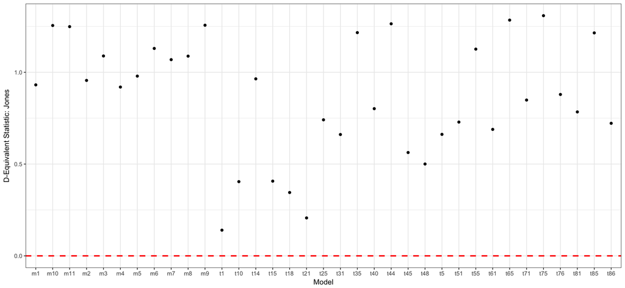

## Results: Williams Models

#### Table 1

|  | **Model 1** | **Model 2** | **Model 3** | **Model 4** | **Model 5** |  |
| --- | --- | --- | --- | --- | --- | --- |
| (Intercept) | 3.495 | 4.482 | 1.994 | 5.909 | 4.299 |  |
|  | (10.494) | (9.864) | (9.946) | (10.238) | (10.070) |  |
| Female | -7.106 | -4.495 | -4.228 | -4.745 | -6.343 |  |
|  | (5.495) | (5.237) | (5.301) | (5.439) | (5.279) |  |
| Age | 16.496 | 4.398 | 5.299 | 10.899 | 12.919 |  |
|  | (14.487) | (14.213) | (14.287) | (14.286) | (13.970) |  |
| YrsEduc | 12.631 | 3.334 | 4.547 | 5.886 | 11.357 |  |
|  | (10.888) | (10.702) | (10.704) | (11.011) | (10.455) |  |
| Black | 4.965 | 16.213 | 15.818 | 16.927 | 12.611 |  |
|  | (14.102) | (13.785) | (13.902) | (14.754) | (13.877) |  |
| LatinoLatino | -4.219 | -3.153 | -3.515 | -4.689 | -5.168 |  |
|  | (10.341) | (9.721) | (9.789) | (10.031) | (9.925) |  |
| PolSoph | 31.049* | 25.113 | 26.883 | 25.380 | 22.061 |  |
|  | (14.599) | (13.861) | (13.896) | (14.398) | (14.469) |  |
| LibCon | -26.344 | -11.711 | -14.442 | -17.142 | -21.529 |  |
|  | (16.376) | (16.162) | (16.075) | (16.441) | (15.826) |  |
| PanelLength5 Weeks | 24.152* | 18.765 | 19.006 | 19.990 | 24.941* |  |
|  | (10.471) | (10.005) | (10.080) | (10.335) | (10.047) |  |
| RWilliamsMemAff5 |  | 64.319** |  |  |  |  |
|  |  | (21.780) |  |  |  |  |
| RWilliamsMemAff50 |  |  | 61.532** |  |  |  |
|  |  |  | (22.081) |  |  |  |
| RWilliamsIWMemAff5 |  |  |  | 41.957* |  |  |
|  |  |  |  | (19.412) |  |  |
| RWilliamsAccRecogMemAff5 |  |  |  |  | 35.538* |  |
|  |  |  |  |  | (14.438) |  |
| R<sup>2</sup> | 0.241 | 0.341 | 0.332 | 0.298 | 0.313 |  |
| Adj. R<sup>2</sup> | 0.136 | 0.237 | 0.226 | 0.187 | 0.205 |  |
| Num. obs. | 67 | 67 | 67 | 67 | 67 |  |
| RMSE | 21.485 | 20.184 | 20.332 | 20.836 | 20.605 |  |
| p < 0.001, p < 0.01, p < 0.05. All models, OLS. DV: Wk5RepWilliamsFTR |  |  |  |  |  |  |

#### Table 2

|  | **Model 1** | **Model 2** | **Model 3** | **Model 4** | **Model 5** | **Model 6** | **Model 7** | **Model 8** |  |
| --- | --- | --- | --- | --- | --- | --- | --- | --- | --- |
| (Intercept) | 1.110 | -0.551 | 3.182 | 3.739 | -0.481 | 5.401 | -0.275 | 0.622 |  |
|  | (10.678) | (10.170) | (10.327) | (9.740) | (9.949) | (10.108) | (10.308) | (10.334) |  |
| Female | -2.654 | -0.091 | -0.278 | 0.236 | 0.213 | -0.126 | -1.053 | -0.969 |  |
|  | (5.591) | (5.400) | (5.482) | (5.148) | (5.281) | (5.306) | (5.432) | (5.462) |  |
| Age | 20.070 | 8.868 | 13.632 | 2.820 | 4.935 | 12.063 | 16.491 | 16.305 |  |
|  | (14.742) | (14.623) | (14.467) | (14.230) | (14.529) | (14.068) | (14.290) | (14.363) |  |
| YrsEduc | 8.297 | 0.361 | 2.239 | -2.394 | -0.543 | -0.052 | 7.868 | 7.275 |  |
|  | (11.079) | (10.940) | (10.984) | (10.501) | (10.682) | (10.747) | (10.679) | (10.729) |  |
| Black | 5.144 | 16.303 | 19.146 | 19.358 | 18.358 | 22.076 | 13.793 | 12.240 |  |
|  | (14.350) | (14.262) | (15.065) | (13.630) | (13.992) | (14.577) | (14.317) | (14.245) |  |
| LatinoLatino | -6.927 | -8.532 | -10.193 | -6.863 | -7.302 | -8.963 | -8.712 | -8.008 |  |
|  | (10.522) | (10.020) | (10.234) | (9.571) | (9.792) | (9.883) | (10.169) | (10.192) |  |
| PolSoph | 20.798 | 18.379 | 18.316 | 15.049 | 17.496 | 14.928 | 16.090 | 16.236 |  |
|  | (14.855) | (14.150) | (14.352) | (13.604) | (13.862) | (14.056) | (14.458) | (14.518) |  |
| LibCon | -14.132 | -3.563 | -6.225 | 3.998 | -0.410 | -2.007 | -12.031 | -11.862 |  |
|  | (16.663) | (16.323) | (16.406) | (15.962) | (16.101) | (16.126) | (16.084) | (16.154) |  |
| PanelLength5 Weeks | 25.207* | 23.716* | 24.178* | 17.441 | 19.322 | 18.550 | 28.069** | 26.701* |  |
|  | (10.655) | (10.143) | (10.275) | (9.926) | (10.088) | (10.227) | (10.341) | (10.331) |  |
| RWilliamsDifAff |  | 59.582** |  |  |  |  |  |  |  |
|  |  | (22.225) |  |  |  |  |  |  |  |
| RWilliamsIWDifAff |  |  | 44.996* |  |  |  |  |  |  |
|  |  |  | (19.225) |  |  |  |  |  |  |
| RWilliamsMemAff |  |  |  | 80.106*** |  |  |  |  |  |
|  |  |  |  | (22.127) |  |  |  |  |  |
| RWilliamsMemAff0 |  |  |  |  | 71.840** |  |  |  |  |
|  |  |  |  |  | (22.733) |  |  |  |  |
| RWilliamsIWMemAff |  |  |  |  |  | 57.221** |  |  |  |
|  |  |  |  |  |  | (19.020) |  |  |  |
| RWilliamsAccRecogMemAff10 |  |  |  |  |  |  | 31.984* |  |  |
|  |  |  |  |  |  |  | (13.705) |  |  |
| RWilliamsAccAccessedRecogMemAff |  |  |  |  |  |  |  | 30.416* |  |
|  |  |  |  |  |  |  |  | (13.660) |  |
| R<sup>2</sup> | 0.182 | 0.273 | 0.253 | 0.335 | 0.304 | 0.294 | 0.253 | 0.247 |  |
| Adj. R<sup>2</sup> | 0.069 | 0.158 | 0.135 | 0.229 | 0.194 | 0.182 | 0.135 | 0.128 |  |
| Num. obs. | 67 | 67 | 67 | 67 | 67 | 67 | 67 | 67 |  |
| RMSE | 21.862 | 20.782 | 21.064 | 19.885 | 20.343 | 20.486 | 21.069 | 21.152 |  |
| p < 0.001, p < 0.01, p < 0.05. All models, OLS. DV: Wk10RepWilliamsFTR |  |  |  |  |  |  |  |  |  |

#### Table 3

|  | **Model 1** | **Model 2** | **Model 3** | **Model 4** | **Model 5** | **Model 6** | **Model 7** | **Model 8** | **Model 9** |  |
| --- | --- | --- | --- | --- | --- | --- | --- | --- | --- | --- |
| (Intercept) | 3.495 | 6.968 | 2.257 | 2.719 | 1.531 | 3.530 | 4.357 | 4.204 | 7.034 |  |
|  | (10.494) | (10.397) | (9.654) | (10.442) | (10.026) | (10.546) | (10.633) | (10.406) | (10.063) |  |
| Female | -7.106 | -4.876 | -5.630 | -5.968 | -6.812 | -6.474 | -6.019 | -5.292 | -6.131 |  |
|  | (5.495) | (5.484) | (5.070) | (5.526) | (5.236) | (5.604) | (5.776) | (5.584) | (5.236) |  |
| Age | 16.496 | 11.237 | 6.802 | 13.417 | 10.084 | 15.384 | 15.796 | 14.751 | 14.547 |  |
|  | (14.487) | (14.396) | (13.618) | (14.579) | (14.017) | (14.655) | (14.602) | (14.400) | (13.792) |  |
| YrsEduc | 12.631 | 12.703 | 14.567 | 12.474 | 13.066 | 12.236 | 12.494 | 12.404 | 13.330 |  |
|  | (10.888) | (10.630) | (10.025) | (10.818) | (10.375) | (10.958) | (10.946) | (10.786) | (10.354) |  |
| Black | 4.965 | 9.112 | 8.856 | 7.888 | 7.942 | 6.273 | 5.892 | 7.362 | 6.117 |  |
|  | (14.102) | (13.929) | (13.014) | (14.182) | (13.483) | (14.309) | (14.247) | (14.066) | (13.413) |  |
| LatinoLatino | -4.219 | -3.860 | 0.745 | -4.686 | -1.555 | -3.931 | -3.969 | -3.653 | -0.276 |  |
|  | (10.341) | (10.097) | (9.617) | (10.279) | (9.904) | (10.400) | (10.401) | (10.250) | (9.940) |  |
| PolSoph | 31.049* | 32.854* | 35.386* | 31.671* | 33.340* | 29.402 | 29.701* | 30.680* | 30.423* |  |
|  | (14.599) | (14.282) | (13.480) | (14.511) | (13.936) | (14.880) | (14.822) | (14.463) | (13.880) |  |
| LibCon | -26.344 | -28.493 | -21.990 | -27.380 | -22.369 | -23.841 | -25.888 | -28.082 | -25.875 |  |
|  | (16.376) | (16.025) | (15.108) | (16.288) | (15.675) | (16.886) | (16.474) | (16.265) | (15.568) |  |
| PanelLength5 Weeks | 24.152* | 25.077* | 24.308* | 24.568* | 23.850* | 23.808* | 24.663* | 25.061* | 24.308* |  |
|  | (10.471) | (10.234) | (9.626) | (10.408) | (9.977) | (10.535) | (10.554) | (10.391) | (9.954) |  |
| RWilliams25Cumu0 |  | 37.147 |  |  |  |  |  |  |  |  |
|  |  | (18.932) |  |  |  |  |  |  |  |  |
| RWilliamsWk5WeeklyTally0 |  |  | 48.134** |  |  |  |  |  |  |  |
|  |  |  | (14.112) |  |  |  |  |  |  |  |
| RWilliams25Cumu1 |  |  |  | 18.246 |  |  |  |  |  |  |
|  |  |  |  | (13.740) |  |  |  |  |  |  |
| RWilliamsWk5WeeklyTally1 |  |  |  |  | 31.542* |  |  |  |  |  |
|  |  |  |  |  | (12.009) |  |  |  |  |  |
| RWilliamsWk25WeeklyPBTally1 |  |  |  |  |  | 10.230 |  |  |  |  |
|  |  |  |  |  |  | (15.479) |  |  |  |  |
| RWilliamsWk25WeeklyPBTally2 |  |  |  |  |  |  | 11.719 |  |  |  |
|  |  |  |  |  |  |  | (18.224) |  |  |  |
| RWilliams25Cumu2 |  |  |  |  |  |  |  | 21.169 |  |  |
|  |  |  |  |  |  |  |  | (14.563) |  |  |
| RWilliamsWk5WeeklyTally2 |  |  |  |  |  |  |  |  | 40.715** |  |
|  |  |  |  |  |  |  |  |  | (15.196) |  |
| R<sup>2</sup> | 0.241 | 0.289 | 0.369 | 0.263 | 0.323 | 0.246 | 0.246 | 0.268 | 0.325 |  |
| Adj. R<sup>2</sup> | 0.136 | 0.176 | 0.270 | 0.147 | 0.216 | 0.127 | 0.127 | 0.152 | 0.219 |  |
| Num. obs. | 67 | 67 | 67 | 67 | 67 | 67 | 67 | 67 | 67 |  |
| RMSE | 21.485 | 20.976 | 19.751 | 21.345 | 20.469 | 21.590 | 21.594 | 21.282 | 20.425 |  |
| p < 0.001, p < 0.01, p < 0.05. All models, OLS. DV: Wk5RepWilliamsFTR |  |  |  |  |  |  |  |  |  |  |

#### Table 4

|  | **Model 1** | **Model 2** | **Model 3** | **Model 4** | **Model 5** | **Model 6** | **Model 7** | **Model 8** | **Model 9** |  |
| --- | --- | --- | --- | --- | --- | --- | --- | --- | --- | --- |
| (Intercept) | 1.110 | 1.863 | 9.604 | 0.401 | 5.193 | 1.117 | 1.619 | 1.771 | 8.208 |  |
|  | (10.678) | (10.609) | (11.871) | (10.706) | (10.754) | (10.773) | (10.821) | (10.607) | (11.066) |  |
| Female | -2.654 | -1.342 | -2.565 | -1.933 | -2.679 | -2.701 | -1.901 | -1.021 | -1.848 |  |
|  | (5.591) | (5.627) | (5.523) | (5.641) | (5.495) | (5.763) | (5.904) | (5.673) | (5.480) |  |
| Age | 20.070 | 17.455 | 18.658 | 18.464 | 18.842 | 20.096 | 19.858 | 19.477 | 20.426 |  |
|  | (14.742) | (14.747) | (14.591) | (14.837) | (14.506) | (14.884) | (14.855) | (14.634) | (14.409) |  |
| YrsEduc | 8.297 | 8.145 | 8.771 | 7.879 | 8.000 | 8.302 | 8.355 | 8.438 | 10.582 |  |
|  | (11.079) | (10.993) | (10.949) | (11.091) | (10.891) | (11.177) | (11.159) | (10.994) | (10.893) |  |
| Black | 5.144 | 8.041 | 5.234 | 7.629 | 6.376 | 5.001 | 6.243 | 7.771 | 5.847 |  |
|  | (14.350) | (14.390) | (14.176) | (14.577) | (14.122) | (14.917) | (14.682) | (14.365) | (14.029) |  |
| LatinoLatino | -6.927 | -6.741 | -5.019 | -7.724 | -6.044 | -6.912 | -7.039 | -7.049 | -5.840 |  |
|  | (10.522) | (10.441) | (10.466) | (10.557) | (10.354) | (10.621) | (10.601) | (10.441) | (10.299) |  |
| PolSoph | 20.798 | 22.517 | 21.997 | 21.714 | 21.749 | 20.810 | 20.904 | 21.703 | 22.376 |  |
|  | (14.855) | (14.790) | (14.695) | (14.889) | (14.611) | (14.987) | (14.963) | (14.755) | (14.541) |  |
| LibCon | -14.132 | -16.672 | -12.017 | -15.757 | -11.035 | -14.247 | -13.757 | -17.033 | -14.468 |  |
|  | (16.663) | (16.633) | (16.516) | (16.751) | (16.474) | (17.053) | (16.805) | (16.667) | (16.286) |  |
| PanelLength5 Weeks | 25.207* | 26.754* | 24.386* | 26.536* | 24.814* | 25.188* | 25.460* | 27.121* | 25.018* |  |
|  | (10.655) | (10.630) | (10.538) | (10.744) | (10.475) | (10.758) | (10.747) | (10.663) | (10.414) |  |
| RWilliams29Cumu0 |  | 23.045 |  |  |  |  |  |  |  |  |
|  |  | (16.631) |  |  |  |  |  |  |  |  |
| RWilliamsWk9WeeklyTally0 |  |  | 42.636 |  |  |  |  |  |  |  |
|  |  |  | (27.326) |  |  |  |  |  |  |  |
| RWilliams29Cumu1 |  |  |  | 13.500 |  |  |  |  |  |  |
|  |  |  |  | (13.773) |  |  |  |  |  |  |
| RWilliamsWk9WeeklyTally1 |  |  |  |  | 29.884 |  |  |  |  |  |
|  |  |  |  |  | (17.145) |  |  |  |  |  |
| RWilliamsWk29WeeklyPBTally1 |  |  |  |  |  | -0.595 |  |  |  |  |
|  |  |  |  |  |  | (14.988) |  |  |  |  |
| RWilliamsWk29WeeklyPBTally2 |  |  |  |  |  |  | 6.837 |  |  |  |
|  |  |  |  |  |  |  | (16.101) |  |  |  |
| RWilliams29Cumu2 |  |  |  |  |  |  |  | 19.337 |  |  |
|  |  |  |  |  |  |  |  | (14.003) |  |  |
| RWilliamsWk9WeeklyTally2 |  |  |  |  |  |  |  |  | 32.579 |  |
|  |  |  |  |  |  |  |  |  | (16.891) |  |
| R<sup>2</sup> | 0.182 | 0.208 | 0.215 | 0.195 | 0.223 | 0.182 | 0.184 | 0.208 | 0.232 |  |
| Adj. R<sup>2</sup> | 0.069 | 0.083 | 0.091 | 0.068 | 0.100 | 0.052 | 0.055 | 0.083 | 0.110 |  |
| Num. obs. | 67 | 67 | 67 | 67 | 67 | 67 | 67 | 67 | 67 |  |
| RMSE | 21.862 | 21.691 | 21.596 | 21.869 | 21.488 | 22.053 | 22.018 | 21.693 | 21.367 |  |
| p < 0.001, p < 0.01, p < 0.05. All models, OLS. DV: Wk10RepWilliamsFTR |  |  |  |  |  |  |  |  |  |  |

#### Table 5

|  | **Model 1** | **Model 2** | **Model 3** | **Model 4** | **Model 5** | **Model 6** | **Model 7** | **Model 8** | **Model 9** |  |
| --- | --- | --- | --- | --- | --- | --- | --- | --- | --- | --- |
| (Intercept) | 1.110 | 2.288 | 7.190 | 0.737 | 6.122 | 1.604 | 2.569 | 9.591 | 3.115 |  |
|  | (10.678) | (10.411) | (10.705) | (10.533) | (10.511) | (10.808) | (10.462) | (10.777) | (11.616) |  |
| Female | -2.654 | -0.267 | -1.986 | -1.031 | -2.020 | -2.230 | -0.035 | -1.188 | -2.168 |  |
|  | (5.591) | (5.566) | (5.423) | (5.603) | (5.395) | (5.708) | (5.629) | (5.387) | (5.730) |  |
| Age | 20.070 | 16.304 | 16.199 | 17.406 | 16.367 | 20.230 | 18.795 | 18.593 | 20.398 |  |
|  | (14.742) | (14.468) | (14.385) | (14.629) | (14.294) | (14.848) | (14.421) | (14.131) | (14.861) |  |
| YrsEduc | 8.297 | 7.826 | 9.185 | 7.571 | 8.520 | 8.217 | 8.251 | 10.935 | 8.352 |  |
|  | (11.079) | (10.788) | (10.738) | (10.935) | (10.677) | (11.158) | (10.827) | (10.664) | (11.156) |  |
| Black | 5.144 | 8.991 | 4.745 | 8.795 | 5.917 | 6.372 | 8.540 | 5.541 | 6.161 |  |
|  | (14.350) | (14.095) | (13.899) | (14.328) | (13.832) | (14.704) | (14.132) | (13.744) | (14.620) |  |
| LatinoLatino | -6.927 | -6.414 | -3.773 | -7.956 | -4.762 | -6.981 | -7.202 | -4.980 | -6.926 |  |
|  | (10.522) | (10.246) | (10.291) | (10.395) | (10.182) | (10.596) | (10.283) | (10.108) | (10.595) |  |
| PolSoph | 20.798 | 25.117 | 25.119 | 23.769 | 25.013 | 21.831 | 23.937 | 25.477 | 21.702 |  |
|  | (14.855) | (14.614) | (14.520) | (14.762) | (14.428) | (15.132) | (14.607) | (14.350) | (15.088) |  |
| LibCon | -14.132 | -18.029 | -10.277 | -16.967 | -9.414 | -13.269 | -18.375 | -13.625 | -13.675 |  |
|  | (16.663) | (16.332) | (16.233) | (16.524) | (16.183) | (16.887) | (16.431) | (15.960) | (16.808) |  |
| PanelLength5 Weeks | 25.207* | 26.754* | 22.519* | 26.716* | 23.039* | 25.200* | 27.381* | 23.726* | 25.145* |  |
|  | (10.655) | (10.400) | (10.391) | (10.548) | (10.309) | (10.729) | (10.473) | (10.222) | (10.729) |  |
| RWilliamsMR29Cumu0 |  | 31.417* |  |  |  |  |  |  |  |  |
|  |  | (15.327) |  |  |  |  |  |  |  |  |
| RWilliamsWk9MRWeeklyTally0 |  |  | 48.023* |  |  |  |  |  |  |  |
|  |  |  | (21.840) |  |  |  |  |  |  |  |
| RWilliamsMR29Cumu1 |  |  |  | 21.991 |  |  |  |  |  |  |
|  |  |  |  | (13.526) |  |  |  |  |  |  |
| RWilliamsWk9MRWeeklyTally1 |  |  |  |  | 38.770* |  |  |  |  |  |
|  |  |  |  |  | (16.592) |  |  |  |  |  |
| RWilliamsMR29PB1 |  |  |  |  |  | 7.878 |  |  |  |  |
|  |  |  |  |  |  | (17.464) |  |  |  |  |
| RWilliamsMR29Cumu2 |  |  |  |  |  |  | 28.639 |  |  |  |
|  |  |  |  |  |  |  | (14.817) |  |  |  |
| RWilliamsWk9MRWeeklyTally2 |  |  |  |  |  |  |  | 38.659* |  |  |
|  |  |  |  |  |  |  |  | (15.489) |  |  |
| RWilliamsMR29PB2 |  |  |  |  |  |  |  |  | 9.186 |  |
|  |  |  |  |  |  |  |  |  | (20.141) |  |
| R<sup>2</sup> | 0.182 | 0.238 | 0.246 | 0.218 | 0.253 | 0.184 | 0.232 | 0.262 | 0.185 |  |
| Adj. R<sup>2</sup> | 0.069 | 0.117 | 0.126 | 0.094 | 0.135 | 0.056 | 0.111 | 0.146 | 0.056 |  |
| Num. obs. | 67 | 67 | 67 | 67 | 67 | 67 | 67 | 67 | 67 |  |
| RMSE | 21.862 | 21.282 | 21.173 | 21.559 | 21.067 | 22.014 | 21.364 | 20.938 | 22.013 |  |
| p < 0.001, p < 0.01, p < 0.05. All models, OLS. DV: Wk10RepWilliamsFTR |  |  |  |  |  |  |  |  |  |  |

### Effect Sizes

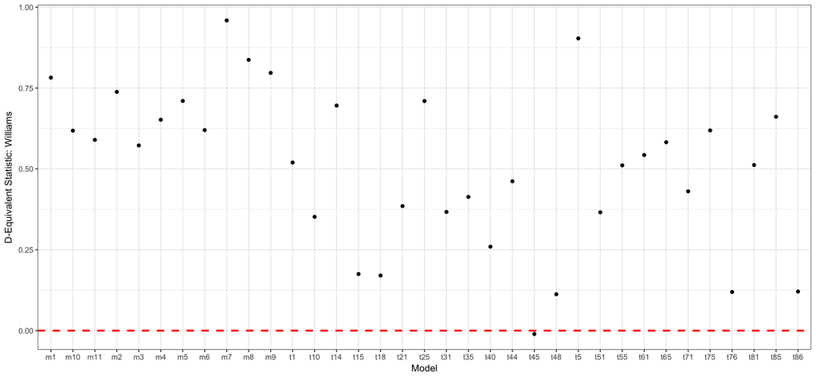

## Summaries MTurkers

### Plot: Combined Effect Sizes by Candidate

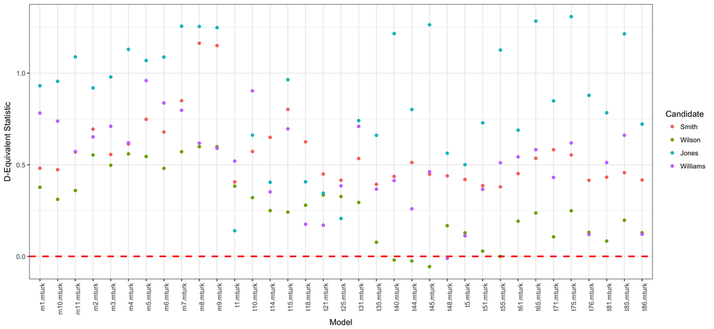

### Table: Combined Effect Sizes by Variable

#### Detail

```
##    Variable     Mean
## 1        m1 49.69289
## 2        m2 47.11482
## 3        m3 42.38741
## 4        m4 38.11529
## 5        m5 57.25761
## 6        m6 53.54465
## 7        m7 61.76739
## 8        m8 58.60908
## 9        m9 54.70104
## 10      m10 43.82238
## 11      m11 43.18221
## 12       t1 26.53821
## 13       t5 43.88142
## 14      t10 22.60877
```

[output cut: 21 more lines]

### All Memory

```
## [1] 50.01771
```

### All Tally

```
## [1] 31.34439
```

# Study 3: Hypotheses Testing

## Scaling Issue

- The variables had been rescaled. Now I show summary stats for all of them.

```r
# Var 1
summary(dat$DSmithWk4WeeklyTally0)
```

```
##    Min. 1st Qu.  Median    Mean 3rd Qu.    Max.    NA's
## -0.5000 -0.2107 -0.1402 -0.1263 -0.0642  0.5000     177
```

```r
summary(dat$DWilsonWk4WeeklyTally0)
```

```
##    Min. 1st Qu.  Median    Mean 3rd Qu.    Max.    NA's
## -0.5000 -0.2448 -0.1715 -0.1560 -0.0846  0.5000     177
```

```r
summary(dat$RJonesWk4WeeklyTally0)
```

```
##    Min. 1st Qu.  Median    Mean 3rd Qu.    Max.    NA's
## -0.5000 -0.2318 -0.1618 -0.1475 -0.0775  0.5000     431
```

```r
summary(dat$RWilliamsWk4WeeklyTally0)
```

```
##    Min. 1st Qu.  Median    Mean 3rd Qu.    Max.    NA's
## -0.5000 -0.3312 -0.2449 -0.2126 -0.1328  0.5000     431
```

```r
# Var 2
summary(dat$DSmithJustWk5RT0)
```

```
##     Min.  1st Qu.   Median     Mean  3rd Qu.     Max.     NA's
## -0.50000  0.00633  0.04008  0.04001  0.07384  0.50000      222
```

```r
summary(dat$DWilsonJustWk5RT0)
```

```
##     Min.  1st Qu.   Median     Mean  3rd Qu.     Max.     NA's
## -0.50000 -0.05690  0.03103  0.03416  0.12586  0.50000      222
```

```r
summary(dat$RJonesJustWk5RT0)
```

```
##    Min. 1st Qu.  Median    Mean 3rd Qu.    Max.    NA's
## -0.5000 -0.1314 -0.0636 -0.0605  0.0085  0.5000     456
```

```r
summary(dat$RWilliamsJustWk5RT0)
```

```
##    Min. 1st Qu.  Median    Mean 3rd Qu.    Max.    NA's
## -0.5000 -0.2464 -0.1802 -0.1656 -0.0883  0.5000     456
```

```r
# Var 3
summary(dat$DSmithWk8WeeklyTally0)
```

```
##    Min. 1st Qu.  Median    Mean 3rd Qu.    Max.    NA's
## -0.5000 -0.3603 -0.3129 -0.2994 -0.2548  0.5000     177
```

```r
summary(dat$DWilsonWk8WeeklyTally0)
```

```
##    Min. 1st Qu.  Median    Mean 3rd Qu.    Max.    NA's
## -0.5000 -0.2859 -0.2382 -0.2263 -0.1840  0.5000     177
```

```r
summary(dat$RJonesWk8WeeklyTally0)
```

```
##    Min. 1st Qu.  Median    Mean 3rd Qu.    Max.    NA's
## -0.5000 -0.2886 -0.1973 -0.1752 -0.0927  0.5000     431
```

```r
summary(dat$RWilliamsWk8WeeklyTally0)
```

```
##    Min. 1st Qu.  Median    Mean 3rd Qu.    Max.    NA's
## -0.5000 -0.3481 -0.2507 -0.2304 -0.1575  0.5000     431
```

```r
# Var 4
summary(dat$DSmithJustWk9RT0)
```

```
##    Min. 1st Qu.  Median    Mean 3rd Qu.    Max.    NA's
## -0.5000 -0.2385 -0.1949 -0.1758 -0.1314  0.5000     220
```

```r
summary(dat$DWilsonJustWk9RT0)
```

```
##    Min. 1st Qu.  Median    Mean 3rd Qu.    Max.    NA's
## -0.5000 -0.2624 -0.1990 -0.1823 -0.1198  0.5000     220
```

```r
summary(dat$RJonesJustWk9RT0)
```

```
##    Min. 1st Qu.  Median    Mean 3rd Qu.    Max.    NA's
## -0.5000  0.0204  0.0918  0.0930  0.1735  0.5000     447
```

```r
summary(dat$RWilliamsJustWk9RT0)
```

```
##    Min. 1st Qu.  Median    Mean 3rd Qu.    Max.    NA's
## -0.5000 -0.1935 -0.1452 -0.1179 -0.0484  0.5000     447
```

```r
# Var 5
summary(dat$DSmithWk8MRWeeklyTally0)
```

```
##    Min. 1st Qu.  Median    Mean 3rd Qu.    Max.    NA's
## -0.5000 -0.3921 -0.3523 -0.3344 -0.2926  0.5000     177
```

```r
summary(dat$DWilsonWk8MRWeeklyTally0)
```

```
##    Min. 1st Qu.  Median    Mean 3rd Qu.    Max.    NA's
## -0.5000 -0.2341 -0.1854 -0.1684 -0.1305  0.5000     177
```

```r
summary(dat$RJonesWk8MRWeeklyTally0)
```

```
##    Min. 1st Qu.  Median    Mean 3rd Qu.    Max.    NA's
## -0.5000 -0.3952 -0.3273 -0.3074 -0.2590  0.5000     431
```

```r
summary(dat$RWilliamsWk8MRWeeklyTally0)
```

```
##    Min. 1st Qu.  Median    Mean 3rd Qu.    Max.    NA's
## -0.5000 -0.3366 -0.2476 -0.2223 -0.1636  0.5000     431
```

```r
# Var 6
summary(dat$DSmithJustWk9MRRT0)
```

```
##     Min.  1st Qu.   Median     Mean  3rd Qu.     Max.     NA's
## -0.50000 -0.23580 -0.17431 -0.15147 -0.09836  0.50000      246
```

```r
summary(dat$DWilsonJustWk9MRRT0)
```

```
##    Min. 1st Qu.  Median    Mean 3rd Qu.    Max.    NA's
## -0.5000 -0.2153 -0.1704 -0.1542 -0.1144  0.5000     244
```

```r
summary(dat$RJonesJustWk9MRRT0)
```

```
##    Min. 1st Qu.  Median    Mean 3rd Qu.    Max.    NA's
## -0.5000  0.0219  0.0629  0.0776  0.1242  0.5000     464
```

```r
summary(dat$RWilliamsJustWk9MRRT0)
```

```
##    Min. 1st Qu.  Median    Mean 3rd Qu.    Max.    NA's
## -0.5000 -0.1820 -0.1445 -0.1147 -0.0743  0.5000     462
```

## Smith [Student]

|  | **Wk5DemSmithFTR** | **Wk10DemSmithFTR** | **Wk10DemSmithFTR** | **Wk10DemSmithFTR** | **Wk10DemSmithFTR** | **Wk5DemSmithFTR** | **Wk10DemSmithFTR** | **Wk10DemSmithFTR** | **Wk10DemSmithFTR** | **Wk10DemSmithFTR** |  |
| --- | --- | --- | --- | --- | --- | --- | --- | --- | --- | --- | --- |
| (Intercept) | -28.391 | 4.235 | 6.228 | 9.149 | 12.284 | -35.426* | 3.730 | -10.182 | 11.561 | 0.719 |  |
|  | (15.310) | (12.745) | (12.850) | (11.439) | (11.733) | (14.890) | (15.616) | (12.999) | (17.167) | (15.544) |  |
| Female | -1.016 | -2.768 | -2.822 | -1.501 | -1.819 | -1.786 | -2.366 | -0.175 | -3.141 | -0.383 |  |
|  | (2.853) | (2.558) | (2.551) | (2.243) | (2.254) | (2.813) | (2.761) | (2.363) | (2.899) | (2.564) |  |
| Age | -82.012* | -20.444 | -20.023 | -4.052 | -3.973 | -81.450* | -26.573 | -29.040 | -22.205 | -21.888 |  |
|  | (32.725) | (26.708) | (26.631) | (24.277) | (24.450) | (32.090) | (30.108) | (25.697) | (31.952) | (28.521) |  |
| YrsEduc | 14.576 | -0.706 | -2.331 | 2.124 | 5.635 | 16.252 | -12.946 | -6.724 | -12.818 | -8.276 |  |
|  | (20.419) | (14.561) | (14.509) | (12.474) | (12.381) | (20.032) | (18.297) | (14.760) | (19.864) | (16.890) |  |
| Black | -7.857 | -8.785 | -8.510 | -8.902* | -8.382* | -5.482 | -6.542 | -5.742 | -6.151 | -4.961 |  |
|  | (5.133) | (4.719) | (4.712) | (4.044) | (4.080) | (5.111) | (5.085) | (4.285) | (5.224) | (4.497) |  |
| LatinoLatino | 8.551* | 8.443** | 8.664** | 6.321* | 6.620* | 8.003* | 9.377** | 7.878** | 10.825** | 9.058** |  |
|  | (3.687) | (3.197) | (3.195) | (2.753) | (2.777) | (3.621) | (3.533) | (2.901) | (3.791) | (3.201) |  |
| PolSoph | 8.329 | 2.465 | 1.894 | -6.944 | -7.306 | 7.989 | 2.218 | -5.672 | -1.026 | -5.891 |  |
|  | (7.351) | (6.508) | (6.505) | (5.586) | (5.632) | (7.209) | (7.178) | (5.898) | (7.621) | (6.396) |  |
| LibCon | -17.154* | -19.414* | -18.840* | -10.442 | -10.283 | -13.064 | -19.693* | -14.187* | -23.109** | -14.798 |  |
|  | (8.361) | (7.481) | (7.479) | (6.619) | (6.675) | (8.340) | (8.111) | (6.935) | (8.535) | (7.580) |  |
| PanelLength5 Weeks | 2.729 | 2.019 | 2.232 | 0.181 | 0.564 | 2.701 | 2.164 | -1.394 | 4.008 | 0.314 |  |
|  | (3.826) | (3.349) | (3.340) | (2.995) | (3.016) | (3.752) | (3.710) | (3.193) | (3.937) | (3.463) |  |
| DSmithMemAff5 | 8.905 |  |  |  |  | 12.155 |  |  |  |  |  |
|  | (13.844) |  |  |  |  | (13.630) |  |  |  |  |  |
| DSmithWk5WeeklyTally0 | 70.237** |  |  |  |  |  |  |  |  |  |  |
|  | (25.847) |  |  |  |  |  |  |  |  |  |  |
| DSmithDifAff |  | 21.111 | 21.488 |  |  |  | 16.825 |  | 14.892 |  |  |
|  |  | (13.235) | (13.198) |  |  |  | (14.925) |  | (15.074) |  |  |
| DSmithWk9WeeklyTally0 |  | 23.711 |  | -18.678 |  |  |  |  |  |  |  |
|  |  | (12.634) |  | (11.082) |  |  |  |  |  |  |  |
| DSmithWk9MRWeeklyTally0 |  |  | 26.613* |  | -1.008 |  |  |  |  |  |  |
|  |  |  | (12.373) |  | (11.817) |  |  |  |  |  |  |
| DSmithAccRecogMemAff10 |  |  |  | 45.287*** | 42.460*** |  |  | 49.457*** |  | 42.993*** |  |
|  |  |  |  | (5.818) | (5.836) |  |  | (6.293) |  | (7.190) |  |
| DSmithWk4WeeklyTally0 |  |  |  |  |  | -17.104 |  |  |  |  |  |
|  |  |  |  |  |  | (12.997) |  |  |  |  |  |
| DSmithJustWk5RT0 |  |  |  |  |  | 107.530*** |  |  |  |  |  |
|  |  |  |  |  |  | (28.077) |  |  |  |  |  |
| DSmithWk8WeeklyTally0 |  |  |  |  |  |  | 18.350 | -9.374 |  |  |  |
|  |  |  |  |  |  |  | (18.727) | (16.194) |  |  |  |
| DSmithJustWk9RT0 |  |  |  |  |  |  | 10.761 | -38.689** |  |  |  |
|  |  |  |  |  |  |  | (15.656) | (12.596) |  |  |  |
| DSmithWk8MRWeeklyTally0 |  |  |  |  |  |  |  |  | 42.629 | 4.375 |  |
|  |  |  |  |  |  |  |  |  | (22.425) | (21.287) |  |
| DSmithJustWk9MRRT0 |  |  |  |  |  |  |  |  | 1.045 | -13.806 |  |
|  |  |  |  |  |  |  |  |  | (13.474) | (12.230) |  |
| R<sup>2</sup> | 0.234 | 0.149 | 0.153 | 0.307 | 0.298 | 0.268 | 0.148 | 0.340 | 0.179 | 0.309 |  |
| Adj. R<sup>2</sup> | 0.184 | 0.102 | 0.107 | 0.274 | 0.264 | 0.215 | 0.089 | 0.300 | 0.115 | 0.261 |  |
| Num. obs. | 165 | 195 | 195 | 221 | 221 | 165 | 171 | 192 | 154 | 173 |  |
| RMSE | 17.860 | 17.472 | 17.421 | 16.287 | 16.396 | 17.513 | 17.718 | 15.882 | 17.707 | 16.279 |  |
| p < 0.001, p < 0.01, p < 0.05. All models, OLS. |  |  |  |  |  |  |  |  |  |  |  |

## Smith [MTurk]

|  | **Wk5DemSmithFTR** | **Wk10DemSmithFTR** | **Wk10DemSmithFTR** | **Wk10DemSmithFTR** | **Wk10DemSmithFTR** | **Wk5DemSmithFTR** | **Wk10DemSmithFTR** | **Wk10DemSmithFTR** | **Wk10DemSmithFTR** | **Wk10DemSmithFTR** |  |
| --- | --- | --- | --- | --- | --- | --- | --- | --- | --- | --- | --- |
| (Intercept) | 20.542*** | 24.276*** | 27.754*** | 12.662* | 14.918* | 17.113*** | 33.610*** | 16.839* | 37.195*** | 19.775* |  |
|  | (4.559) | (6.635) | (6.690) | (6.286) | (6.449) | (4.620) | (7.560) | (7.372) | (7.825) | (7.715) |  |
| Female | -3.785 | -3.291 | -3.183 | -2.405 | -2.412 | -3.749 | -3.496 | -2.301 | -2.808 | -1.957 |  |
|  | (2.198) | (2.546) | (2.516) | (2.347) | (2.345) | (2.199) | (2.569) | (2.389) | (2.608) | (2.440) |  |
| Age | -2.211 | -1.763 | -1.585 | 3.803 | 3.717 | -2.307 | 1.143 | 4.730 | 2.481 | 6.068 |  |
|  | (5.581) | (6.451) | (6.376) | (6.015) | (6.012) | (5.584) | (6.604) | (6.186) | (6.697) | (6.312) |  |
| YrsEduc | 2.289 | 2.106 | 2.231 | 0.775 | 0.812 | 2.253 | 0.642 | -1.297 | 0.665 | -0.939 |  |
|  | (5.300) | (6.126) | (6.055) | (5.623) | (5.620) | (5.301) | (6.080) | (5.623) | (6.168) | (5.735) |  |
| Black | -0.921 | -1.071 | -0.843 | 1.216 | 1.400 | -0.823 | -0.618 | 0.496 | -0.501 | 0.285 |  |
|  | (3.479) | (3.945) | (3.891) | (3.545) | (3.540) | (3.482) | (4.084) | (3.705) | (4.085) | (3.712) |  |
| LatinoLatino | 0.730 | -1.134 | -1.539 | 1.044 | 0.723 | 0.436 | -1.233 | 1.056 | -1.803 | 0.892 |  |
|  | (3.742) | (4.420) | (4.370) | (4.120) | (4.121) | (3.756) | (4.394) | (4.123) | (4.388) | (4.148) |  |
| PolSoph | -3.128 | 6.057 | 6.173 | -2.243 | -2.334 | -3.034 | 4.164 | -2.750 | 4.923 | -2.920 |  |
|  | (5.948) | (7.016) | (6.890) | (6.654) | (6.637) | (5.951) | (6.995) | (6.661) | (6.999) | (6.749) |  |
| LibCon | -29.510*** | -18.090* | -15.489* | -11.420 | -10.785 | -28.358*** | -14.738 | -9.575 | -12.255 | -9.449 |  |
|  | (6.395) | (7.345) | (7.361) | (6.838) | (6.887) | (6.514) | (7.473) | (6.955) | (7.736) | (7.206) |  |
| PanelLength5 Weeks | -1.757 | 4.691 | 5.152 | 4.952 | 5.013 | -1.743 | 3.076 | 3.624 | 3.980 | 3.728 |  |
|  | (2.788) | (3.230) | (3.195) | (2.973) | (2.975) | (2.789) | (3.278) | (3.036) | (3.299) | (3.070) |  |
| DSmithMemAff5 | 28.208** |  |  |  |  | 27.717** |  |  |  |  |  |
|  | (8.977) |  |  |  |  | (8.995) |  |  |  |  |  |
| DSmithWk5WeeklyTally0 | 54.435*** |  |  |  |  |  |  |  |  |  |  |
|  | (14.644) |  |  |  |  |  |  |  |  |  |  |
| DSmithDifAff |  | 43.026*** | 43.132*** |  |  |  | 48.474*** |  | 47.563*** |  |  |
|  |  | (11.304) | (11.162) |  |  |  | (12.097) |  | (12.321) |  |  |
| DSmithWk9WeeklyTally0 |  | 47.958** |  | -1.643 |  |  |  |  |  |  |  |
|  |  | (15.828) |  | (16.785) |  |  |  |  |  |  |  |
| DSmithWk9MRWeeklyTally0 |  |  | 52.772*** |  | 6.763 |  |  |  |  |  |  |
|  |  |  | (14.127) |  | (15.397) |  |  |  |  |  |  |
| DSmithAccRecogMemAff10 |  |  |  | 45.112*** | 43.244*** |  |  | 43.905*** |  | 43.283*** |  |
|  |  |  |  | (6.824) | (6.930) |  |  | (6.926) |  | (7.267) |  |
| DSmithWk4WeeklyTally0 |  |  |  |  |  | 2.720 |  |  |  |  |  |
|  |  |  |  |  |  | (9.687) |  |  |  |  |  |
| DSmithJustWk5RT0 |  |  |  |  |  | 59.183** |  |  |  |  |  |
|  |  |  |  |  |  | (17.742) |  |  |  |  |  |
| DSmithWk8WeeklyTally0 |  |  |  |  |  |  | 36.100* | 11.677 |  |  |  |
|  |  |  |  |  |  |  | (15.051) | (14.633) |  |  |  |
| DSmithJustWk9RT0 |  |  |  |  |  |  | 21.694 | -11.048 |  |  |  |
|  |  |  |  |  |  |  | (17.064) | (16.777) |  |  |  |
| DSmithWk8MRWeeklyTally0 |  |  |  |  |  |  |  |  | 48.168** | 15.519 |  |
|  |  |  |  |  |  |  |  |  | (16.284) | (16.460) |  |
| DSmithJustWk9MRRT0 |  |  |  |  |  |  |  |  | 14.445 | -6.107 |  |
|  |  |  |  |  |  |  |  |  | (12.450) | (12.065) |  |
| R<sup>2</sup> | 0.318 | 0.221 | 0.239 | 0.318 | 0.318 | 0.321 | 0.219 | 0.307 | 0.243 | 0.320 |  |
| Adj. R<sup>2</sup> | 0.280 | 0.180 | 0.199 | 0.282 | 0.283 | 0.279 | 0.170 | 0.264 | 0.193 | 0.276 |  |
| Num. obs. | 192 | 201 | 201 | 204 | 204 | 192 | 187 | 190 | 180 | 183 |  |
| RMSE | 14.645 | 17.373 | 17.168 | 16.173 | 16.165 | 14.650 | 16.936 | 15.870 | 16.841 | 15.871 |  |
| p < 0.001, p < 0.01, p < 0.05. All models, OLS. |  |  |  |  |  |  |  |  |  |  |  |

## Wilson [Student]

|  | **Wk5DemWilsonFTR** | **Wk10DemWilsonFTR** | **Wk10DemWilsonFTR** | **Wk10DemWilsonFTR** | **Wk10DemWilsonFTR** | **Wk5DemWilsonFTR** | **Wk10DemWilsonFTR** | **Wk10DemWilsonFTR** | **Wk10DemWilsonFTR** | **Wk10DemWilsonFTR** |  |
| --- | --- | --- | --- | --- | --- | --- | --- | --- | --- | --- | --- |
| (Intercept) | -15.395 | -14.690 | -14.499 | -7.612 | -6.445 | -17.118 | -22.638 | -17.189 | -16.396 | -6.282 |  |
|  | (16.958) | (14.273) | (14.181) | (14.062) | (14.075) | (16.810) | (16.082) | (15.105) | (17.094) | (16.184) |  |
| Female | -5.447 | -9.179** | -9.254** | -9.079** | -9.471*** | -5.287 | -9.634** | -9.568** | -10.441** | -9.164** |  |
|  | (3.202) | (2.951) | (2.939) | (2.802) | (2.795) | (3.204) | (3.132) | (2.939) | (3.321) | (3.110) |  |
| Age | -24.893 | -31.565 | -33.907 | -22.747 | -26.692 | -22.495 | -46.777 | -40.360 | -37.322 | -26.017 |  |
|  | (36.656) | (30.898) | (30.890) | (30.397) | (30.504) | (36.702) | (33.626) | (31.944) | (36.622) | (34.787) |  |
| YrsEduc | -33.864 | -14.036 | -11.400 | -7.821 | -4.316 | -33.144 | -19.635 | -11.345 | -21.008 | -27.515 |  |
|  | (22.752) | (16.770) | (17.012) | (15.608) | (15.815) | (22.749) | (20.431) | (18.178) | (22.756) | (20.736) |  |
| Black | 6.314 | -5.621 | -5.999 | -3.144 | -3.380 | 6.762 | -8.326 | -4.350 | -9.007 | -4.119 |  |
|  | (5.678) | (5.405) | (5.418) | (5.048) | (5.097) | (5.689) | (5.733) | (5.385) | (6.093) | (5.649) |  |
| LatinoLatino | 12.343** | 14.930*** | 15.069*** | 12.129*** | 12.638*** | 12.148** | 16.182*** | 12.628*** | 16.541*** | 13.204*** |  |
|  | (4.125) | (3.674) | (3.655) | (3.462) | (3.453) | (4.126) | (3.978) | (3.642) | (4.273) | (3.860) |  |
| PolSoph | -6.272 | -1.115 | -1.061 | -4.270 | -4.165 | -7.087 | -0.285 | -6.297 | -1.061 | -6.685 |  |
|  | (8.106) | (7.466) | (7.453) | (6.894) | (6.916) | (8.136) | (8.091) | (7.303) | (8.543) | (7.694) |  |
| LibCon | 5.485 | 15.189 | 14.235 | 9.797 | 9.013 | 6.628 | 15.521 | 10.551 | 15.147 | 9.611 |  |
|  | (9.353) | (8.824) | (8.817) | (8.107) | (8.150) | (9.407) | (9.190) | (8.472) | (9.872) | (9.089) |  |
| PanelLength5 Weeks | 5.720 | 0.068 | 0.243 | 1.695 | 1.940 | 5.723 | 0.455 | 2.015 | -0.127 | 0.889 |  |
|  | (4.233) | (3.845) | (3.841) | (3.679) | (3.694) | (4.230) | (4.142) | (3.849) | (4.438) | (4.091) |  |
| DWilsonMemAff5 | 59.481** |  |  |  |  | 61.875** |  |  |  |  |  |
|  | (18.923) |  |  |  |  | (19.040) |  |  |  |  |  |
| DWilsonWk5WeeklyTally0 | 23.276 |  |  |  |  |  |  |  |  |  |  |
|  | (13.773) |  |  |  |  |  |  |  |  |  |  |
| DWilsonDifAff |  | 71.925*** | 72.205*** |  |  |  | 63.461** |  | 63.811** |  |  |
|  |  | (19.128) | (19.041) |  |  |  | (20.455) |  | (21.392) |  |  |
| DWilsonWk9WeeklyTally0 |  | 1.470 |  | -16.190 |  |  |  |  |  |  |  |
|  |  | (14.408) |  | (13.870) |  |  |  |  |  |  |  |
| DWilsonWk9MRWeeklyTally0 |  |  | 10.793 |  | 0.216 |  |  |  |  |  |  |
|  |  |  | (13.650) |  | (13.600) |  |  |  |  |  |  |
| DWilsonAccRecogMemAff10 |  |  |  | 34.184*** | 32.203*** |  |  | 33.779*** |  | 38.132*** |  |
|  |  |  |  | (8.449) | (8.443) |  |  | (9.015) |  | (9.778) |  |
| DWilsonWk4WeeklyTally0 |  |  |  |  |  | -1.416 |  |  |  |  |  |
|  |  |  |  |  |  | (11.489) |  |  |  |  |  |
| DWilsonJustWk5RT0 |  |  |  |  |  | 23.374* |  |  |  |  |  |
|  |  |  |  |  |  | (11.639) |  |  |  |  |  |
| DWilsonWk8WeeklyTally0 |  |  |  |  |  |  | -0.797 | -15.500 |  |  |  |
|  |  |  |  |  |  |  | (18.328) | (17.870) |  |  |  |
| DWilsonJustWk9RT0 |  |  |  |  |  |  | -2.008 | -14.264 |  |  |  |
|  |  |  |  |  |  |  | (11.830) | (10.474) |  |  |  |
| DWilsonWk8MRWeeklyTally0 |  |  |  |  |  |  |  |  | 0.093 | -13.399 |  |
|  |  |  |  |  |  |  |  |  | (17.155) | (16.706) |  |
| DWilsonJustWk9MRRT0 |  |  |  |  |  |  |  |  | 7.212 | 0.727 |  |
|  |  |  |  |  |  |  |  |  | (13.999) | (13.418) |  |
| R<sup>2</sup> | 0.205 | 0.231 | 0.233 | 0.203 | 0.198 | 0.211 | 0.238 | 0.229 | 0.236 | 0.233 |  |
| Adj. R<sup>2</sup> | 0.153 | 0.189 | 0.192 | 0.165 | 0.159 | 0.154 | 0.185 | 0.182 | 0.178 | 0.181 |  |
| Num. obs. | 165 | 195 | 195 | 221 | 221 | 165 | 171 | 192 | 156 | 174 |  |
| RMSE | 19.969 | 20.090 | 20.056 | 20.290 | 20.355 | 19.958 | 19.960 | 19.734 | 20.378 | 19.932 |  |
| p < 0.001, p < 0.01, p < 0.05. All models, OLS. |  |  |  |  |  |  |  |  |  |  |  |

## Wilson [MTurk]

|  | **Wk5DemWilsonFTR** | **Wk10DemWilsonFTR** | **Wk10DemWilsonFTR** | **Wk10DemWilsonFTR** | **Wk10DemWilsonFTR** | **Wk5DemWilsonFTR** | **Wk10DemWilsonFTR** | **Wk10DemWilsonFTR** | **Wk10DemWilsonFTR** | **Wk10DemWilsonFTR** |  |
| --- | --- | --- | --- | --- | --- | --- | --- | --- | --- | --- | --- |
| (Intercept) | 17.130** | 10.734 | 17.415* | 11.334 | 17.860* | 21.367** | 9.020 | 7.111 | 13.911 | 13.108 |  |
|  | (6.319) | (8.062) | (7.324) | (7.760) | (7.094) | (6.517) | (7.913) | (7.566) | (7.331) | (7.029) |  |
| Female | -5.558 | -1.558 | -1.546 | -2.691 | -2.511 | -5.004 | -0.653 | -1.762 | -0.876 | -1.936 |  |
|  | (3.064) | (2.941) | (2.916) | (2.868) | (2.862) | (3.029) | (3.055) | (2.915) | (3.066) | (2.941) |  |
| Age | 8.770 | 8.316 | 8.900 | 11.849 | 11.973 | 10.072 | 2.820 | 3.807 | 1.689 | 3.068 |  |
|  | (7.792) | (7.459) | (7.397) | (7.344) | (7.324) | (7.700) | (7.860) | (7.549) | (7.939) | (7.652) |  |
| YrsEduc | 10.576 | 3.677 | 2.500 | -0.256 | 0.251 | 10.299 | 3.289 | -1.284 | 1.274 | -2.523 |  |
|  | (7.425) | (7.120) | (7.084) | (6.954) | (6.926) | (7.321) | (7.265) | (6.978) | (7.309) | (7.037) |  |
| Black | -0.428 | -3.728 | -3.761 | 3.067 | 1.814 | -0.627 | -1.347 | 5.116 | -1.421 | 4.024 |  |
|  | (4.774) | (4.551) | (4.512) | (4.364) | (4.368) | (4.707) | (4.787) | (4.493) | (4.807) | (4.523) |  |
| LatinoLatino | -7.199 | -4.162 | -3.349 | -2.216 | -1.749 | -7.769 | -2.983 | -0.980 | -2.077 | -0.469 |  |
|  | (5.176) | (5.084) | (5.050) | (5.010) | (5.000) | (5.109) | (5.190) | (5.008) | (5.150) | (4.982) |  |
| PolSoph | -1.769 | 1.518 | 0.748 | -1.069 | -1.716 | -1.281 | 2.803 | -0.022 | 2.007 | -0.618 |  |
|  | (8.303) | (8.034) | (7.978) | (7.837) | (7.830) | (8.189) | (8.241) | (7.851) | (8.233) | (7.887) |  |
| LibCon | 31.604*** | 22.838** | 20.089* | 17.963* | 17.223* | 29.398*** | 23.175** | 18.664* | 21.357* | 18.750* |  |
|  | (8.642) | (8.308) | (8.328) | (8.026) | (8.023) | (8.566) | (8.603) | (8.186) | (8.800) | (8.365) |  |
| PanelLength5 Weeks | 5.057 | 6.301 | 5.875 | 5.951 | 5.359 | 4.308 | 4.487 | 4.054 | 3.971 | 3.436 |  |
|  | (3.882) | (3.750) | (3.726) | (3.642) | (3.649) | (3.839) | (3.904) | (3.724) | (3.902) | (3.741) |  |
| DWilsonMemAff5 | 36.989* |  |  |  |  | 39.044** |  |  |  |  |  |
|  | (14.964) |  |  |  |  | (14.776) |  |  |  |  |  |
| DWilsonWk5WeeklyTally0 | 24.734 |  |  |  |  |  |  |  |  |  |  |
|  | (12.771) |  |  |  |  |  |  |  |  |  |  |
| DWilsonDifAff |  | 43.899** | 42.435** |  |  |  | 48.570** |  | 47.849** |  |  |
|  |  | (14.440) | (14.341) |  |  |  | (16.030) |  | (15.931) |  |  |
| DWilsonWk9WeeklyTally0 |  | 4.411 |  | -9.722 |  |  |  |  |  |  |  |
|  |  | (22.473) |  | (21.404) |  |  |  |  |  |  |  |
| DWilsonWk9MRWeeklyTally0 |  |  | 40.877 |  | 24.000 |  |  |  |  |  |  |
|  |  |  | (22.568) |  | (21.587) |  |  |  |  |  |  |
| DWilsonAccRecogMemAff10 |  |  |  | 34.780*** | 29.499** |  |  | 42.124*** |  | 39.916*** |  |
|  |  |  |  | (8.790) | (8.996) |  |  | (8.950) |  | (9.274) |  |
| DWilsonWk4WeeklyTally0 |  |  |  |  |  | 36.806** |  |  |  |  |  |
|  |  |  |  |  |  | (11.890) |  |  |  |  |  |
| DWilsonJustWk5RT0 |  |  |  |  |  | -2.130 |  |  |  |  |  |
|  |  |  |  |  |  | (11.775) |  |  |  |  |  |
| DWilsonWk8WeeklyTally0 |  |  |  |  |  |  | -7.759 | -36.153 |  |  |  |
|  |  |  |  |  |  |  | (20.556) | (20.356) |  |  |  |
| DWilsonJustWk9RT0 |  |  |  |  |  |  | 11.721 | 12.863 |  |  |  |
|  |  |  |  |  |  |  | (14.916) | (13.180) |  |  |  |
| DWilsonWk8MRWeeklyTally0 |  |  |  |  |  |  |  |  | 4.999 | -21.370 |  |
|  |  |  |  |  |  |  |  |  | (20.473) | (20.569) |  |
| DWilsonJustWk9MRRT0 |  |  |  |  |  |  |  |  | 31.259 | 24.750 |  |
|  |  |  |  |  |  |  |  |  | (18.206) | (15.799) |  |
| R<sup>2</sup> | 0.173 | 0.117 | 0.132 | 0.140 | 0.145 | 0.201 | 0.104 | 0.162 | 0.121 | 0.171 |  |
| Adj. R<sup>2</sup> | 0.127 | 0.071 | 0.086 | 0.095 | 0.100 | 0.152 | 0.048 | 0.110 | 0.064 | 0.118 |  |
| Num. obs. | 192 | 201 | 201 | 204 | 204 | 192 | 187 | 190 | 181 | 184 |  |
| RMSE | 20.442 | 20.072 | 19.903 | 19.761 | 19.708 | 20.153 | 20.084 | 19.363 | 19.852 | 19.213 |  |
| p < 0.001, p < 0.01, p < 0.05. All models, OLS. |  |  |  |  |  |  |  |  |  |  |  |

## Jones [Student]

|  | **Wk5RepJonesFTR** | **Wk10RepJonesFTR** | **Wk10RepJonesFTR** | **Wk10RepJonesFTR** | **Wk10RepJonesFTR** | **Wk5RepJonesFTR** | **Wk10RepJonesFTR** | **Wk10RepJonesFTR** | **Wk10RepJonesFTR** | **Wk10RepJonesFTR** |  |
| --- | --- | --- | --- | --- | --- | --- | --- | --- | --- | --- | --- |
| (Intercept) | -38.377 | -16.606 | -8.920 | 2.723 | 8.248 | -48.159 | -7.448 | 7.399 | -4.829 | 21.444 |  |
|  | (27.566) | (23.377) | (23.229) | (20.815) | (20.894) | (28.312) | (23.624) | (22.018) | (28.566) | (26.649) |  |
| Female | -11.986* | -13.575* | -14.393** | -12.097* | -12.879* | -11.466 | -13.855* | -12.650* | -20.719*** | -18.869** |  |
|  | (5.869) | (5.267) | (5.202) | (5.152) | (5.110) | (5.803) | (5.483) | (5.648) | (5.906) | (6.404) |  |
| Age | -74.346 | -18.199 | -14.654 | 14.587 | 16.295 | -95.510 | -6.075 | 24.385 | -77.401 | -19.172 |  |
|  | (64.032) | (50.744) | (49.634) | (46.534) | (45.907) | (64.522) | (52.127) | (49.240) | (64.397) | (62.061) |  |
| YrsEduc | -58.282 | -30.016 | -29.044 | -3.372 | -3.549 | -64.586 | -52.087 | -14.767 | -14.327 | 10.047 |  |
|  | (40.010) | (30.034) | (29.129) | (27.750) | (27.181) | (39.687) | (36.560) | (34.340) | (40.226) | (37.085) |  |
| Black | -8.235 | -20.306 | -17.561 | 8.442 | 9.070 | -18.521 | -7.271 | 15.715 | 6.510 | 26.205 |  |
|  | (21.641) | (22.265) | (21.486) | (22.290) | (21.960) | (22.268) | (23.405) | (24.141) | (22.250) | (23.744) |  |
| LatinoLatino | 2.423 | 5.588 | 5.527 | 10.156 | 10.038 | 2.211 | 6.198 | 12.193 | 3.858 | 9.294 |  |
|  | (7.359) | (7.289) | (7.186) | (6.684) | (6.609) | (7.267) | (7.761) | (7.291) | (7.625) | (7.233) |  |
| PolSoph | -11.942 | -12.681 | -12.689 | -18.079 | -17.826 | -10.913 | -17.057 | -23.095* | -19.978 | -25.565* |  |
|  | (10.769) | (10.266) | (10.122) | (9.428) | (9.323) | (10.650) | (10.847) | (10.506) | (10.687) | (10.632) |  |
| LibCon | 66.264*** | 63.650*** | 59.118*** | 42.864** | 40.582** | 64.164*** | 60.160*** | 42.842** | 29.172 | 17.116 |  |
|  | (15.310) | (13.872) | (13.682) | (13.085) | (13.041) | (15.169) | (14.761) | (15.240) | (17.398) | (17.637) |  |
| PanelLength5 Weeks | 2.414 | -1.738 | -1.578 | -5.220 | -4.944 | 0.956 | -1.217 | -4.063 | 3.726 | 0.956 |  |
|  | (6.267) | (5.769) | (5.675) | (5.529) | (5.472) | (6.251) | (6.015) | (6.026) | (6.177) | (6.369) |  |
| RJonesMemAff5 | 11.879 |  |  |  |  | 13.035 |  |  |  |  |  |
|  | (19.399) |  |  |  |  | (19.165) |  |  |  |  |  |
| RJonesWk5WeeklyTally0 | 41.071* |  |  |  |  |  |  |  |  |  |  |
|  | (19.309) |  |  |  |  |  |  |  |  |  |  |
| RJonesDifAff |  | 54.541** | 52.572** |  |  |  | 53.679* |  | 44.850* |  |  |
|  |  | (20.169) | (19.823) |  |  |  | (22.367) |  | (21.424) |  |  |
| RJonesWk9WeeklyTally0 |  | 15.728 |  | 13.918 |  |  |  |  |  |  |  |
|  |  | (16.910) |  | (14.988) |  |  |  |  |  |  |  |
| RJonesWk9MRWeeklyTally0 |  |  | 36.363 |  | 31.368 |  |  |  |  |  |  |
|  |  |  | (19.958) |  | (18.320) |  |  |  |  |  |  |
| RJonesAccRecogMemAff10 |  |  |  | 43.615** | 41.450** |  |  | 34.003* |  | 22.936 |  |
|  |  |  |  | (13.542) | (13.187) |  |  | (15.273) |  | (15.731) |  |
| RJonesWk4WeeklyTally0 |  |  |  |  |  | -11.278 |  |  |  |  |  |
|  |  |  |  |  |  | (18.587) |  |  |  |  |  |
| RJonesJustWk5RT0 |  |  |  |  |  | 56.813* |  |  |  |  |  |
|  |  |  |  |  |  | (21.977) |  |  |  |  |  |
| RJonesWk8WeeklyTally0 |  |  |  |  |  |  | 34.426 | 29.850 |  |  |  |
|  |  |  |  |  |  |  | (18.191) | (19.091) |  |  |  |
| RJonesJustWk9RT0 |  |  |  |  |  |  | 19.932 | 21.337 |  |  |  |
|  |  |  |  |  |  |  | (17.525) | (17.498) |  |  |  |
| RJonesWk8MRWeeklyTally0 |  |  |  |  |  |  |  |  | 102.538*** | 102.814*** |  |
|  |  |  |  |  |  |  |  |  | (26.644) | (28.151) |  |
| RJonesJustWk9MRRT0 |  |  |  |  |  |  |  |  | 11.080 | 14.791 |  |
|  |  |  |  |  |  |  |  |  | (20.396) | (20.878) |  |
| R<sup>2</sup> | 0.455 | 0.393 | 0.410 | 0.401 | 0.414 | 0.477 | 0.447 | 0.425 | 0.528 | 0.491 |  |
| Adj. R<sup>2</sup> | 0.371 | 0.322 | 0.341 | 0.337 | 0.351 | 0.387 | 0.364 | 0.343 | 0.443 | 0.403 |  |
| Num. obs. | 76 | 96 | 96 | 104 | 104 | 76 | 85 | 89 | 73 | 76 |  |
| RMSE | 19.534 | 20.275 | 19.992 | 19.799 | 19.584 | 19.286 | 20.204 | 20.459 | 19.031 | 19.711 |  |
| p < 0.001, p < 0.01, p < 0.05. All models, OLS. |  |  |  |  |  |  |  |  |  |  |  |

## Jones [MTurk]

|  | **Wk5RepJonesFTR** | **Wk10RepJonesFTR** | **Wk10RepJonesFTR** | **Wk10RepJonesFTR** | **Wk10RepJonesFTR** | **Wk5RepJonesFTR** | **Wk10RepJonesFTR** | **Wk10RepJonesFTR** | **Wk10RepJonesFTR** | **Wk10RepJonesFTR** |  |
| --- | --- | --- | --- | --- | --- | --- | --- | --- | --- | --- | --- |
| (Intercept) | -5.915 | 0.596 | 9.188 | -0.297 | 5.397 | -5.935 | -11.501 | -11.944 | -2.682 | -4.863 |  |
|  | (10.780) | (9.929) | (11.137) | (9.311) | (10.713) | (10.977) | (9.895) | (9.125) | (12.452) | (12.183) |  |
| Female | 2.880 | -4.046 | -4.707 | -1.231 | -1.628 | 2.154 | -5.333 | -2.915 | -2.838 | -0.941 |  |
|  | (5.698) | (5.017) | (5.173) | (4.949) | (5.118) | (5.765) | (5.110) | (4.977) | (5.149) | (5.094) |  |
| Age | -6.880 | -11.984 | -11.774 | -13.332 | -13.181 | -5.126 | -11.071 | -11.961 | -12.371 | -13.286 |  |
|  | (14.771) | (13.257) | (13.512) | (12.887) | (13.073) | (14.927) | (13.275) | (12.763) | (12.986) | (12.698) |  |
| YrsEduc | 9.102 | -4.532 | -5.766 | -5.094 | -6.079 | 7.937 | -6.796 | -6.508 | -5.666 | -5.860 |  |
|  | (11.170) | (10.144) | (10.306) | (9.834) | (9.946) | (11.266) | (10.387) | (9.967) | (10.129) | (9.890) |  |
| Black | -0.780 | 22.098 | 21.233 | 26.537* | 26.013* | -1.307 | 22.523 | 26.595* | 19.912 | 23.843 |  |
|  | (14.560) | (13.096) | (13.336) | (12.776) | (12.953) | (14.599) | (13.163) | (12.668) | (12.862) | (12.627) |  |
| LatinoLatino | 9.288 | 8.581 | 8.032 | 5.631 | 5.373 | 8.617 | 7.733 | 3.634 | 8.887 | 6.015 |  |
|  | (10.734) | (9.605) | (9.822) | (9.277) | (9.427) | (10.780) | (9.776) | (9.322) | (9.555) | (9.271) |  |
| PolSoph | 37.155* | 25.917 | 23.976 | 17.687 | 16.359 | 36.470* | 25.814 | 17.465 | 24.056 | 16.833 |  |
|  | (15.425) | (13.102) | (13.358) | (12.616) | (12.768) | (15.472) | (13.118) | (12.481) | (13.512) | (12.931) |  |
| LibCon | 29.057 | 31.395 | 33.437* | 10.543 | 12.296 | 31.773 | 34.769* | 13.796 | 30.876 | 12.033 |  |
|  | (17.581) | (16.002) | (16.299) | (15.835) | (16.007) | (17.873) | (16.189) | (15.849) | (16.394) | (16.080) |  |
| PanelLength5 Weeks | -10.842 | -3.672 | -4.095 | 0.574 | 0.324 | -10.776 | -4.135 | 0.686 | -3.342 | 0.596 |  |
|  | (11.018) | (9.885) | (10.095) | (9.455) | (9.596) | (11.038) | (9.895) | (9.376) | (9.706) | (9.328) |  |
| RJonesMemAff5 | 55.586** |  |  |  |  | 53.540* |  |  |  |  |  |
|  | (20.351) |  |  |  |  | (20.515) |  |  |  |  |  |
| RJonesWk5WeeklyTally0 | 23.642 |  |  |  |  |  |  |  |  |  |  |
|  | (17.330) |  |  |  |  |  |  |  |  |  |  |
| RJonesDifAff |  | 50.012* | 48.373* |  |  |  | 48.641* |  | 42.491* |  |  |
|  |  | (19.104) | (19.850) |  |  |  | (19.288) |  | (19.657) |  |  |
| RJonesWk9WeeklyTally0 |  | 88.099*** |  | 66.778** |  |  |  |  |  |  |  |
|  |  | (22.719) |  | (24.221) |  |  |  |  |  |  |  |
| RJonesWk9MRWeeklyTally0 |  |  | 93.632*** |  | 68.378* |  |  |  |  |  |  |
|  |  |  | (26.728) |  | (28.627) |  |  |  |  |  |  |
| RJonesAccRecogMemAff10 |  |  |  | 44.034** | 44.831** |  |  | 45.204** |  | 36.975* |  |
|  |  |  |  | (13.900) | (14.473) |  |  | (13.791) |  | (14.480) |  |
| RJonesWk4WeeklyTally0 |  |  |  |  |  | -5.889 |  |  |  |  |  |
|  |  |  |  |  |  | (18.565) |  |  |  |  |  |
| RJonesJustWk5RT0 |  |  |  |  |  | 31.369 |  |  |  |  |  |
|  |  |  |  |  |  | (19.881) |  |  |  |  |  |
| RJonesWk8WeeklyTally0 |  |  |  |  |  |  | 27.309 | 7.736 |  |  |  |
|  |  |  |  |  |  |  | (17.692) | (17.781) |  |  |  |
| RJonesJustWk9RT0 |  |  |  |  |  |  | 77.100** | 67.606** |  |  |  |
|  |  |  |  |  |  |  | (23.015) | (22.633) |  |  |  |
| RJonesWk8MRWeeklyTally0 |  |  |  |  |  |  |  |  | 39.572 | 25.757 |  |
|  |  |  |  |  |  |  |  |  | (24.884) | (25.200) |  |
| RJonesJustWk9MRRT0 |  |  |  |  |  |  |  |  | 63.783* | 57.754* |  |
|  |  |  |  |  |  |  |  |  | (26.447) | (26.302) |  |
| R<sup>2</sup> | 0.388 | 0.488 | 0.468 | 0.509 | 0.495 | 0.397 | 0.504 | 0.534 | 0.489 | 0.503 |  |
| Adj. R<sup>2</sup> | 0.279 | 0.401 | 0.378 | 0.427 | 0.411 | 0.277 | 0.408 | 0.446 | 0.384 | 0.404 |  |
| Num. obs. | 67 | 70 | 70 | 71 | 71 | 67 | 69 | 70 | 66 | 67 |  |
| RMSE | 21.905 | 19.724 | 20.103 | 19.165 | 19.440 | 21.944 | 19.714 | 18.947 | 19.245 | 18.815 |  |
| p < 0.001, p < 0.01, p < 0.05. All models, OLS. |  |  |  |  |  |  |  |  |  |  |  |

## Williams [Student]

|  | **Wk5RepWilliamsFTR** | **Wk10RepWilliamsFTR** | **Wk10RepWilliamsFTR** | **Wk10RepWilliamsFTR** | **Wk10RepWilliamsFTR** | **Wk5RepWilliamsFTR** | **Wk10RepWilliamsFTR** | **Wk10RepWilliamsFTR** | **Wk10RepWilliamsFTR** | **Wk10RepWilliamsFTR** |  |
| --- | --- | --- | --- | --- | --- | --- | --- | --- | --- | --- | --- |
| (Intercept) | -63.284** | -8.619 | -9.142 | 1.327 | 0.691 | -67.744** | -10.751 | -5.414 | -9.086 | 1.289 |  |
|  | (23.686) | (22.306) | (22.447) | (19.565) | (19.493) | (23.724) | (22.589) | (19.782) | (29.858) | (25.909) |  |
| Female | -1.295 | -0.447 | -0.471 | 2.992 | 3.179 | -1.427 | -1.125 | 3.165 | -0.020 | 4.449 |  |
|  | (4.910) | (4.892) | (4.910) | (4.630) | (4.626) | (4.777) | (5.130) | (4.923) | (6.067) | (5.870) |  |
| Age | -154.155** | -27.873 | -28.024 | -14.854 | -16.521 | -175.994** | -35.109 | -25.755 | -22.254 | -4.533 |  |
|  | (54.993) | (48.244) | (48.522) | (43.773) | (43.748) | (54.441) | (48.691) | (44.276) | (68.037) | (60.938) |  |
| YrsEduc | -5.656 | -13.964 | -14.774 | -19.982 | -18.928 | -3.788 | -35.592 | -16.780 | -36.759 | -20.377 |  |
|  | (33.596) | (27.872) | (27.898) | (25.724) | (25.571) | (32.694) | (34.535) | (30.232) | (37.288) | (33.379) |  |
| Black | 24.515 | 23.250 | 23.054 | 24.112 | 23.977 | 26.494 | 20.160 | 20.654 | 14.900 | 18.596 |  |
|  | (18.149) | (20.284) | (20.293) | (19.305) | (19.257) | (17.679) | (20.277) | (19.199) | (21.456) | (20.578) |  |
| LatinoLatino | 15.706* | 6.280 | 6.192 | 2.255 | 2.325 | 12.860* | 5.422 | 0.813 | 7.505 | 2.679 |  |
|  | (6.195) | (7.020) | (7.042) | (6.256) | (6.235) | (6.169) | (7.501) | (6.534) | (8.055) | (7.132) |  |
| PolSoph | 1.039 | -7.835 | -7.939 | -10.062 | -9.087 | 0.935 | -2.342 | -5.144 | -0.739 | -4.492 |  |
|  | (9.653) | (9.753) | (10.012) | (8.855) | (8.944) | (9.391) | (10.564) | (9.654) | (11.447) | (10.625) |  |
| LibCon | -4.585 | 9.839 | 10.088 | 10.924 | 9.871 | -0.970 | 6.514 | 11.869 | 17.835 | 20.364 |  |
|  | (11.896) | (12.021) | (12.045) | (10.783) | (10.877) | (11.692) | (12.630) | (11.646) | (14.510) | (13.743) |  |
| PanelLength5 Weeks | 7.343 | 9.085 | 8.979 | 6.342 | 5.757 | 7.917 | 8.422 | 4.181 | 6.456 | 3.098 |  |
|  | (5.379) | (5.670) | (5.749) | (5.420) | (5.471) | (5.240) | (5.975) | (5.726) | (6.606) | (6.346) |  |
| RWilliamsMemAff5 | 28.441 |  |  |  |  | 23.552 |  |  |  |  |  |
|  | (18.108) |  |  |  |  | (17.760) |  |  |  |  |  |
| RWilliamsWk5WeeklyTally0 | 13.022 |  |  |  |  |  |  |  |  |  |  |
|  | (12.077) |  |  |  |  |  |  |  |  |  |  |
| RWilliamsDifAff |  | 39.562 | 39.503 |  |  |  | 40.254 |  | 42.116 |  |  |
|  |  | (21.127) | (21.301) |  |  |  | (21.981) |  | (23.639) |  |  |
| RWilliamsWk9WeeklyTally0 |  | 5.245 |  | -7.598 |  |  |  |  |  |  |  |
|  |  | (14.098) |  | (11.639) |  |  |  |  |  |  |  |
| RWilliamsWk9MRWeeklyTally0 |  |  | 3.739 |  | -10.770 |  |  |  |  |  |  |
|  |  |  | (14.464) |  | (11.718) |  |  |  |  |  |  |
| RWilliamsAccRecogMemAff10 |  |  |  | 41.486*** | 42.240*** |  |  | 45.651*** |  | 44.344*** |  |
|  |  |  |  | (9.750) | (9.789) |  |  | (11.563) |  | (12.585) |  |
| RWilliamsWk4WeeklyTally0 |  |  |  |  |  | -11.294 |  |  |  |  |  |
|  |  |  |  |  |  | (11.943) |  |  |  |  |  |
| RWilliamsJustWk5RT0 |  |  |  |  |  | 42.975* |  |  |  |  |  |
|  |  |  |  |  |  | (18.118) |  |  |  |  |  |
| RWilliamsWk8WeeklyTally0 |  |  |  |  |  |  | 8.453 | -11.637 |  |  |  |
|  |  |  |  |  |  |  | (15.553) | (15.547) |  |  |  |
| RWilliamsJustWk9RT0 |  |  |  |  |  |  | -6.315 | -15.706 |  |  |  |
|  |  |  |  |  |  |  | (14.057) | (12.952) |  |  |  |
| RWilliamsWk8MRWeeklyTally0 |  |  |  |  |  |  |  |  | 9.203 | -7.274 |  |
|  |  |  |  |  |  |  |  |  | (15.978) | (15.949) |  |
| RWilliamsJustWk9MRRT0 |  |  |  |  |  |  |  |  | -10.729 | -20.244 |  |
|  |  |  |  |  |  |  |  |  | (17.256) | (16.366) |  |
| R<sup>2</sup> | 0.316 | 0.108 | 0.107 | 0.236 | 0.239 | 0.363 | 0.125 | 0.260 | 0.136 | 0.258 |  |
| Adj. R<sup>2</sup> | 0.211 | 0.003 | 0.002 | 0.154 | 0.157 | 0.253 | -0.007 | 0.154 | -0.015 | 0.134 |  |
| Num. obs. | 76 | 96 | 96 | 104 | 104 | 76 | 85 | 89 | 75 | 78 |  |
| RMSE | 16.360 | 19.205 | 19.214 | 18.509 | 18.468 | 15.915 | 19.002 | 18.131 | 19.753 | 19.092 |  |
| p < 0.001, p < 0.01, p < 0.05. All models, OLS. |  |  |  |  |  |  |  |  |  |  |  |

## Williams [MTurk]

|  | **Wk5RepWilliamsFTR** | **Wk10RepWilliamsFTR** | **Wk10RepWilliamsFTR** | **Wk10RepWilliamsFTR** | **Wk10RepWilliamsFTR** | **Wk5RepWilliamsFTR** | **Wk10RepWilliamsFTR** | **Wk10RepWilliamsFTR** | **Wk10RepWilliamsFTR** | **Wk10RepWilliamsFTR** |  |
| --- | --- | --- | --- | --- | --- | --- | --- | --- | --- | --- | --- |
| (Intercept) | 3.226 | 6.561 | 5.336 | 2.223 | 5.712 | 9.067 | 5.054 | 0.629 | 5.066 | 7.091 |  |
|  | (9.284) | (11.029) | (10.051) | (11.857) | (10.235) | (9.473) | (10.669) | (11.109) | (10.555) | (10.800) |  |
| Female | -3.815 | -0.267 | 0.140 | -0.586 | -0.644 | -4.352 | -0.906 | -1.510 | 0.468 | -0.774 |  |
|  | (4.929) | (5.139) | (5.059) | (5.278) | (5.225) | (4.983) | (5.349) | (5.424) | (5.432) | (5.580) |  |
| Age | -1.156 | 7.776 | 6.151 | 15.704 | 14.689 | -0.650 | 7.710 | 14.007 | 8.925 | 17.059 |  |
|  | (13.498) | (14.207) | (14.012) | (14.138) | (14.064) | (13.547) | (14.429) | (14.325) | (14.552) | (14.591) |  |
| YrsEduc | 6.975 | 0.537 | 1.283 | 7.725 | 8.310 | 7.035 | -0.981 | 6.095 | 0.898 | 7.696 |  |
|  | (10.139) | (10.672) | (10.505) | (10.535) | (10.456) | (10.166) | (11.084) | (10.840) | (11.021) | (10.961) |  |
| Black | 17.061 | 16.270 | 15.343 | 12.374 | 9.758 | 16.105 | 16.509 | 12.036 | 17.107 | 9.797 |  |
|  | (12.963) | (13.909) | (13.689) | (14.276) | (14.176) | (13.047) | (14.343) | (14.373) | (14.164) | (14.569) |  |
| LatinoLatino | 0.799 | -7.108 | -5.885 | -9.268 | -7.234 | 0.792 | -7.124 | -9.742 | -6.017 | -6.969 |  |
|  | (9.240) | (9.873) | (9.738) | (10.132) | (10.084) | (9.264) | (10.012) | (10.202) | (9.960) | (10.363) |  |
| PolSoph | 30.050* | 15.983 | 18.873 | 11.495 | 14.790 | 29.677* | 15.549 | 6.775 | 25.225 | 23.297 |  |
|  | (13.141) | (13.344) | (13.225) | (13.959) | (14.149) | (13.184) | (13.812) | (14.693) | (14.319) | (15.759) |  |
| LibCon | -11.205 | -2.809 | -2.010 | -11.641 | -10.629 | -8.380 | -0.295 | -4.663 | -4.590 | -13.077 |  |
|  | (15.196) | (15.614) | (15.351) | (15.622) | (15.508) | (15.604) | (16.766) | (16.887) | (17.020) | (17.191) |  |
| PanelLength5 Weeks | 20.060* | 23.103* | 21.586* | 26.934* | 24.766* | 19.779* | 22.293* | 24.382* | 23.479* | 24.966* |  |
|  | (9.416) | (9.917) | (9.799) | (10.162) | (10.221) | (9.447) | (10.457) | (10.461) | (10.266) | (10.581) |  |
| RWilliamsMemAff5 | 50.419* |  |  |  |  | 48.912* |  |  |  |  |  |
|  | (21.025) |  |  |  |  | (21.158) |  |  |  |  |  |
| RWilliamsWk5WeeklyTally0 | 40.558** |  |  |  |  |  |  |  |  |  |  |
|  | (13.922) |  |  |  |  |  |  |  |  |  |  |
| RWilliamsDifAff |  | 59.184** | 56.789** |  |  |  | 60.044** |  | 52.334* |  |  |
|  |  | (21.417) | (21.121) |  |  |  | (21.770) |  | (22.188) |  |  |
| RWilliamsWk9WeeklyTally0 |  | 31.864 |  | 1.319 |  |  |  |  |  |  |  |
|  |  | (25.155) |  | (32.505) |  |  |  |  |  |  |  |
| RWilliamsWk9MRWeeklyTally0 |  |  | 39.604 |  | 25.390 |  |  |  |  |  |  |
|  |  |  | (20.604) |  | (25.847) |  |  |  |  |  |  |
| RWilliamsAccRecogMemAff10 |  |  |  | 29.376 | 20.869 |  |  | 37.690* |  | 14.350 |  |
|  |  |  |  | (16.354) | (15.647) |  |  | (18.240) |  | (18.430) |  |
| RWilliamsWk4WeeklyTally0 |  |  |  |  |  | 14.726 |  |  |  |  |  |
|  |  |  |  |  |  | (16.734) |  |  |  |  |  |
| RWilliamsJustWk5RT0 |  |  |  |  |  | 52.375* |  |  |  |  |  |
|  |  |  |  |  |  | (20.131) |  |  |  |  |  |
| RWilliamsWk8WeeklyTally0 |  |  |  |  |  |  | 10.832 | -26.147 |  |  |  |
|  |  |  |  |  |  |  | (21.246) | (28.289) |  |  |  |
| RWilliamsJustWk9RT0 |  |  |  |  |  |  | 21.618 | 18.094 |  |  |  |
|  |  |  |  |  |  |  | (23.318) | (24.035) |  |  |  |
| RWilliamsWk8MRWeeklyTally0 |  |  |  |  |  |  |  |  | 35.912 | 28.759 |  |
|  |  |  |  |  |  |  |  |  | (19.314) | (25.146) |  |
| RWilliamsJustWk9MRRT0 |  |  |  |  |  |  |  |  | 4.524 | 4.483 |  |
|  |  |  |  |  |  |  |  |  | (29.915) | (31.050) |  |
| R<sup>2</sup> | 0.428 | 0.287 | 0.311 | 0.242 | 0.254 | 0.435 | 0.290 | 0.256 | 0.334 | 0.276 |  |
| Adj. R<sup>2</sup> | 0.326 | 0.166 | 0.194 | 0.115 | 0.129 | 0.322 | 0.153 | 0.115 | 0.198 | 0.131 |  |
| Num. obs. | 67 | 70 | 70 | 71 | 71 | 67 | 69 | 70 | 66 | 67 |  |
| RMSE | 18.976 | 20.317 | 19.976 | 20.876 | 20.711 | 19.026 | 20.598 | 20.997 | 20.417 | 21.194 |  |
| p < 0.001, p < 0.01, p < 0.05. All models, OLS. |  |  |  |  |  |  |  |  |  |  |  |